# [2019]_ФЕДОРОВАГ.П._РазВнедАдПрогОбОтрНапр

# Глава 7. ОСНОВНЫЕ ПОЛОЖЕНИЯ ТЕОРИИ БАЗ ДАННЫХ

### 7.1. Базы данных и информационные системы.

Основные определения... В современном мире информация становится фактором, опреле- ляюшим эффективность любой сферы деятельности. Возрастаю! информационные потоки, повышаются требования к скорости обработки данных, и теперь уже большинство операций не может быть выполнено вручную, они требуют применения наиболее передовых и перспективных компьютерных технологий. Большую роль сегодня играют системы хранения и обработки информации.

Информация — это сведения об объектах, явлениях, процессах, событиях окружающего мира, уменьшающие неопределенность знаний о них. Информация должна быть полной, достоверной, своевременной, непротиворечивой, адекватной. Своевременная выдача достоверной информации для принятия решений — основная цель информационных систем. Информационная система — это совокупность технических и программных средств, обеспечивающих сбор, хранение, обработку, поиск, выдачу информации в задачах любой области. Информационные системы обеспечивают долгосрочное хранение и качественный анализ информации, помогают решать проблемы и создавать новые информационные продукты.

Предметная область — часть реального мира, данные о которой хранятся и используются в информационной системе. Предметная область подлежит изучению с целью организации управления и, в конечном итоге, автоматизации и характеризуется совокупностью объектов, процессов, использующих эти объекты, а также множеством пользователей, которые имеют единый взгляд на предметную область. Анализ предметной области предшествует созданию любой информационной системы. Предметная область конкретной информационной системы рассматривается как некоторая совокупность реальных объектов, представляющих интерес для пользователе» Каждый из этих объектов обладает определенным набором свойств и признаков.

Стр. 106

Информационный объект - это описание некоторой сущности предметной области объекта, процесса, явлении или события,существующих или происходящих в реальном мире. Информационным объект является совокупностью логически связанной информации, т.е. между информационными объектами могут существовать разного рода связи. В информационных системах циркулируют большие объемы информации, имеющей достаточно сложную структуру. В наиболее общем виде информационную систему можно условно представить в виде схемы, состоящей из следующих блоков (рис. 7.1): блок ввода информации (сбор информации о состоянии объектов внешней среды); база данных (хранилище данных); блок обработки информации (поиск, фильтрация, сортировка, агрегирование, анализ, вывод информации); блок обратной связи (передача информации, переработанной потребителем для коррекции входной информации).

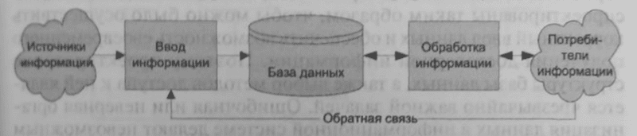

Рис. 7.1. Общее представление информационной системы

База данных является основой информационной системы, ее центральным звеном. Данные - это информация, зафиксированная в некоторой форме, пригодной для последующей обработки, передачи и хранения, например находящаяся в памяти ЭВМ или подготовленная для ввода в ЭВМ. База данных (БД) - именованная совокупность взаимосвязанных данных, отображающая состояние объектов и их отношений в некоторой предметной области, используемых несколькими пользователями. Структура данных — совокупность правил и ограничений, которые отражают связи, существующие между отдельными частями (элементами) данных. Обработка данных - это совокупность задач, осуществляющих преобразование массивов данных. Обработка данных включает в себя ввод данных в ЭВМ, отбор данных по каким-либо критериям, преобразование структуры данных, перемещение данных во внешней памяти ЭВМ, вывод данных, являющихся результатом вычислений или других преобразований (в табличном или в каком-либо ином удобном для пользователя виде). Система обработки данных (СОД) - это набор аппаратных и про-граммных средств, осуществляющих выполнение задач по управлению данными.

Стр. 107

Управление данными - весь круг операций с данными, которые необходимы для успешного функционирования системы обработки данных. Метаданные — это описание собственной структуры базы данных. Их еще называют «данные о данных». Это системные таблицы, в которых содержится информация о всех объектах БД. Метаданные обеспечивают независимость данных от программ их обработки. Если описание данных хранится вместе с данными, то можно запрашивать и модифицировать данные без написания дополнительных программ обработки структуры данных. Конечно, требования к качеству и надежности структур хранимых и обрабатываемых данных очень высоки. Структура базы данных должна быть таковой, чтобы данные в ней были полными, непроти-воречивыми, целостными. Кроме того, базы данных должны быть спроектированы таким образом, чтобы можно было осуществить корректный ввод данных и обеспечить возможность своевременного получения достоверной информации. Поэтому проектирование структуры базы данных, а также выбор методов доступа к ней явля-ется чрезвычайно важной задачей. Ошибочная или неверная организация данных в информационной системе делают невозможным соблюдение этих условий, а саму систему - непригодной для исполь-зования. С понятием базы данных неразрывно связано понятие системы управления базами данных. Система управления базами данных (СУБД) - это совокупность языковых и программных средств, предназначенных для управления созданием и использованием баз данных. Системы управления базами данных являются инструментальными средствами для извлечения данных, их обработки, изменения структуры данных и их анализа. СУБД предоставляет удобный, быстрый и, что очень важно, контролируемый доступ к данным, обеспечивают возможность ввода и модификации информации в базах данных, а также выдачи ее пользователю, обладают средствами для обеспечения целостности данных и поддержания БД в рабочем состоянии. Система управления базой данных обычно сочетает в себе автоматизированные средства структуризации и манипулирования данными со средствами обеспечения секретности, восстановления и сохранности информации в многопользовательском окружении.

Стр. 108

Системы управления базами данных предназначены в основном для профессиональных разработчиков. Обычный пользователь осуществляет управление БД и работу с ее данными с помощью специальных прикладных программ, называемых приложениями. Приложения могут создаваться в среде или вне среды СУБД с помощью системы программирования, использующей средства доступа к базам данных. В общем случае с одной базой данных может работать множество различных приложений. Например, если база данных моделирует некоторое предприятие, то для работы с ней может быть создано несколько приложений: обслуживающее подсистему учета кадров, работу подсистемы расчета заработной платы сотрудников или подсистему складского учета и т.д. При рассмотрении приложений, работающих с одной базой данных, предполагается, что они могут работать параллельно и независимо друг от друга. Именно СУБД должна обеспечить работу нескольких приложений с единой базой данных таким образом, чтобы каждое из них выполнялось кор-ректно, но учитывало все изменения в базе данных, вносимые другими приложениями (рис. 7.2).

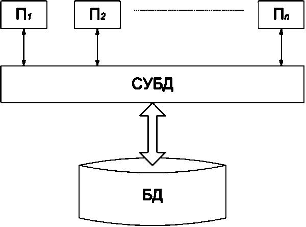

Рис. 7.2. Взаимодействие прикладных программ (приложений) и базы данных

Однопользовательская система - это система, в которой в одно и то же время к базе данных может получить доступ не более одного пользователя. Многопользовательская система - это система, в которой в одно и то же время к базе данных могут получить доступ несколько пользователей. Основная задача большинства многопользовательских систем позволить каждому отдельному пользователю работать с системой как с однопользовательской. Различия однопользовательской и многопользовательской систем - в их внутренней структуре, конечному пользователю они практически не видны. Современной формой организации хранения и доступа к информации является банк данных. Существуют разные определения банка данных. Наиболее полное из них можно сформулировать следующим образом.

Стр. 109

Банк данных (БнД) — это система специальным образом организованных данных (баз данных), программных, языковых, организационно-методических средств, предназначенных для обеспечения централизованного накопления и коллективного многоцелевого использования данных. Банк данных является сложной системой, включающей в себя все обеспечивающие подсистемы, необходимые для автоматизированной обработки данных. В этом определении обозначены и основные отличительные особенности банков данных. Прежде всего это то, что базы данных создаются обычно не для решения какой-либо одной задачи для одного пользователя, а для многоцелевого использования. Другой отличительной особенностью банков данных является наличие специальных языковых и программных средств, облегчающих для пользователей выполнение всех операций, связанных с организацией хранения данных, их корректировки и доступа к ним. Таким образом, банк данных - это совокупность базы данных с соответствующей системой управления базами данных. База данных - централизованное хранилище в ЭВМ определенным образом организованной информации. СУБД - специальный комплекс программ, осуществляющий функции создания базы данных, поддержание ее в рабочем состоянии, выдача из нее информации, необходимой для обрабатывающих программ, и т.д.

Словарь данных (СД) - представляет собой подсистему банка данных, предназначенную для централизованного хранения информации о структурах данных, взаимосвязях файлов базы данных друг с другом, типах данных и форматах их представления, разграничения доступа к данным и т.п. Словарь данных является тем средством, которое позволяет при проектировании, эксплуатации и развитии базы данных поддерживать и контролировать информацию о данных. В некоторых БД предполагается не централизованное хранение данных, а распределенное в компьютерной сети. Распределенная база данных (РБД) - это база данных, включающая фрагменты из нескольких баз данных, которые располагаются на различных узлах сети компьютеров и, возможно, управляются различными СУБД. Распределенная база данных выглядит с точки зрения пользователей и прикладных программ как обычная локальная база данных. Распределенная база данных повышает возможности совместного использования удаленных данных, надежность, доступность и производительность системы, позволяет получить экономию средств и улучшить масштабируемость системы.

Стр. 110

Современные информационные системы используют не только базы данных, но и базы знаний. Знания — это выявленные закономерности предметной области (принципы, связи, законы), позволяющие решать задачи этой области. База знаний совокупность знаний предметной области. Системы, использующие знания, называются интеллектуальными. После того как был раскрыт смысл основных понятий теории баз данных, можно перейти к вопросам их разработки и реализации. Но к приведенным выше формулировкам и определениям рекомендуется еще периодически возвращаться (после изучения следующих разделов курса) для их более четкого усвоения.

# 7.2. Системы управления базами данных. Основные функции СУБД.

Файл с точки зрения прикладной программы — это именованная область внешней памяти, в которую можно записывать и из которой можно считывать данные. Правила именования файлов, способ доступа к данным, хранящимся в файле, и структура этих данных зависят от конкретной системы управления файлами и от типа файла. Система управления файлами берет на себя функции распределения внешней памяти, отображения имен файлов в соответствующие адреса во внешней памяти, обеспечения доступа к данным. Однако этого оказывается недостаточно для построения даже простых информационных систем. Системы управления файлами не обеспечивают возможности поддержания логически согласованного набора файлов, обеспечения языка манипулирования данными, восстановления информации после разного рода сбоев, параллельной работы нескольких пользователей. Прикладная программа должна опираться на некоторую систему управления данными, обладающую этими свойствами. Такой системой и является система управления базами данных. Системы обработки данных включают в себя собственно данные, систему управления базами данных и прикладное программное обеспечение, которое обращается к данным через систему управления БД. Можно выделить следующие функции систем управления базами данных: управление данными во внешней памяти; управление данными в оперативной памяти; управление транзакциями; журнализация, резервное копирование и восстановление; поддержка языков БД.

Cтр. 111

Управление данными во внешней памяти (на дисках). СУБД должна предоставлять пользователям возможность: сохранять, извлекать и обновлять данные в базе данных; контролировать доступ к данным; обеспечивать параллельную работу нескольких пользователей; поддерживать целостность данных. Возможность сохранять, извлекать и обновлять данные в базе данных — самая фундаментальная функция СУБД. Причем способ реализации этой функции должен быть скрыт от конечного пользователя (использует ли СУБД файловую систему, как организованы файлы и т.п.). Контроль доступа к данным - это возможность обеспечить только санкционированный доступ к базе данных, используя защиту паролем, поддержку уровней доступа к базе данных и к отдельным ее элементам и т.д. Каждый пользователь должен иметь возможность работы только с теми данными из БД, которые доступны для него в соответствии с его пользовательскими правами. Таким образом, обеспечивается безопасность в системах управления данными. Управление параллельностью заключается в том, что СУБД имеют механизм, который гарантирует корректное обновление данных многими пользователями при одновременном доступе. Коллизии при совместной работе могут привести к нарушению логической целост-ности данных, поэтому система должна предусматривать меры, не допускающие обновление данных пользователем, пока эти данные используются кем-то еще. В описанных случаях используются так называемые «блокировки». Существуют разные типы блокировок - табличные, страничные, строчные и другие, которые отличаются друг от друга количеством заблокированных записей. Поддержка целостности данных осуществляется инструменталь-ными средствами контроля для того, чтобы данные и их изменения соответствовали заданным правилам. Целостность БД есть свойство базы данных, означающее, что в ней содержится полная, непроти-воречивая и адекватно отражающая предметную область информа-ция. Поддержание целостности БД включает проверку целостности и ее восстановление в случае обнаружения противоречий в базе дан-ных. Целостное состояние БД описывается с помощью ограничений целостности в виде условий, которым должны удовлетворять хранимые в базе данные. Примером таких условий может служить ограничение диапазонов возможных значений атрибутов объектов, сведения о которых хранятся в БД, или отсутствие повторяющихся записей в таблицах реляционных БД.

Cтр. 112

# Управление данными в оперативной памяти.

Размер базы данных, с которой работает СУБД, достаточно велик - обычно существенно больше доступного объема оперативной памяти. Понятно, что если при обращении к любому элементу данных будет производиться обмен с внешней памятью, то вся система будет работать со скоростью устройства внешней памяти. Практически единственным способом реального увеличения этой скорости является буферизация данных в оперативной памяти. Буферы представляют собой области оперативной памяти, предназначенные для ускорения обмена между внешней и оперативной памятью. В буферах временно хранятся фрагменты БД, данные из которых предполагается использовать при обращении к СУБД или планируется записать в базу после обработки. В развитых СУБД поддерживается собственный набор буферов оперативной памяти с собственными правилами их замены. Возможно, что в будущем объем оперативной памяти компьютеров будет настолько велик, что позволит не беспокоиться о буферизации.

# Управление транзакциями.

Транзакция - это совокупность действий над базой данных, рассматриваемых СУБД как единое целое, т.е. последовательность операций с данными, когда выполняются либо все операции, либо ни одна из них (принцип «все или ничего»). Если транзакция выполняется успешно, то СУБД фиксирует изменения БД, произведенные этой транзакцией, во внешней памяти, либо все изменения в рамках транзакции отменяются и ни одно из них никак не отражается на состоянии БД. Понятие транзакции необходимо для поддержания логической целостности БД. Примером транзакции является операция перевода денег с одного счета на другой в банковской системе. Нужно либо совершить все действия (увеличить счет одного клиента и уменьшить счет другого), либо не выполнить ни одно из этих действий. Нельзя уменьшить сумму денег на одном счете, но не увеличить ее на другом. Предположим, что после выполнения первого из действий (уменьшения суммы денег на счете) произошел сбой. Например, могла прерваться связь клиентского компьютера с базой данных или на клиентском компьютере мог произойти системный сбой, что привело к перезагрузке операционной системы. Что в этом случае стало с базой данных? Команда на уменьшение денег на счете первого клиента была выполнена, а команда на увеличение денег на другом счете - нет, что привело бы к противоречивому, неактуальному состоянию базы данных. Сначала снимают деньги с одного счета, затем добавляют их к другому счету. Если хотя бы одно из действий не выполнится успешно, результат операции окажется неверным и будет нарушен баланс между счетами. В этом случае система должна вернуться в предыдущее состояние до начала цепочки операций.

Cтр. 113

Контроль транзакций важен в однопользовательских и в многопользовательских СУБД, где транзакции могут быть запушены параллельно. При параллельном выполнении нескольких транзакший возможно возникновение конфликтов, разрешение которых является также функцией СУБД. При обнаружении таких случаев обычно производится «откат» транзакции, т.е. отмена изменений, произведенных одной или несколькими транзакциями. Более подробно механизм транзакций и управление транзакциями будут рассмотрены при изучении вопросов обеспечения целостности данных.

# Журнализация, резервное копирование и восстановление.

При работе ЭВМ возможны сбои (например, из-за отключения электропи-тания) и повреждение машинных носителей данных. При этом могут быть нарушены данные, что приводит к невозможности дальнейшей работы. Одним из основных требований к СУБД является надежность хранения данных во внешней памяти, в том числе защита физической и логической целостности. Под надежностью хранения понимается то, что СУБД должна иметь возможность восстановить последнее согласованное состояние БД после любого аппаратного или про-граммного сбоя (логических или физических отказов). Защита физической целостности включает в себя журнализацию изменений, резервное копирование и восстановление базы данных после сбоев. Журнализация изменений в простейшем случае заключается в последовательной записи во внешнюю память всех изменений, выполняемых в базе данных. Записывается следующая информация: порядковый номер, тип и время изменения; идентификатор транзакции; объект, подвергшийся изменению (номер хранимого файла и номер блока данных в нем, номер строки внутри блока); предыдущее и новое состояние объекта. Журнал изменений базы данных - это и есть формируемая таким образом информация. Журнал содержит отметки начала и завершения транзакции и отметки принятия контрольной точки. Он является особой частью базы данных, недоступной пользователям СУБД. Ведение журнала поддерживается с особой тщательностью, в него поступают записи обо всех изменениях основной части базы данных. Иногда создаются и поддерживаются две копии журнала, располагаемые на разных физических дисках. Резервное копирование базы данных - процесс создания копии данных на носителе, предназначенном для восстановления данных в оригинальном или новом месте их расположения в случае их повреждения или разрушения.

Cтр. 114

Восстановление базы данных — это функция СУБД, которая в случае логических и физических сбоев приводит базу данных в актуальное состояние. Как уже отмечалось выше, сбой может произойти в результате выхода из строя системы или запоминающего устройства, возможны ошибки аппаратного и программного обеспечения, которые могут привести к остановке работы СУБД. Во всех подобных случаях СУБД должна предоставить механизм восстановления базы данных и возврата к ее непротиворечивому состоянию. В случае физического отказа, если повреждены как журнал изменений, так и сама база данных, восстановление возможно только на момент выполнения резервной копии.

# Поддержка языков БД.

Для работы с базами данных используются специальные языки, в целом называемые языками баз данных. В современных СУБД обычно поддерживается единый интегрированный язык, содержащий все необходимые средства для работы с БД, начиная от ее создания, и обеспечивающий базовый пользовательский интерфейс с базами данных. Стандартным языком наиболее распространенных в настоящее время реляционных СУБД является язык SQL (Structured Query Language). Кроме основных функций, СУБД еще предоставляет некоторый набор различных вспомогательных служб. Вспомогательные утилиты обычно предназначены для эффективного администрирования базы данных, что включает в себя: экспорт/импорт данных; мониторинг базы данных — отслеживание характеристик функ-ционирования и использования базы данных; статистический анализ, позволяющий оценить производитель-ность или степень использования базы данных; реорганизацию индексов; сборку «мусора» (неиспользуемых записей) и перераспределение памяти для физического устранения удаленных записей с запоминающих устройств, объединение освобожденного пространства и перераспределение памяти в случае необходимости.

Организация типичной системы управления базой данных и состав ее компонентов соответствуют рассмотренному нами набору функций. В современной системе управления базами данных можно выделить ядро СУБД, процессор языка базы данных, подсистему поддержки времени выполнения, а также сервисные программы (внешние утилиты), обеспечивающие дополнительные возможности по обслуживанию БД. В некоторых системах эти части выделяются явно, в других - нет, но логически такое разделение можно провести во всех системах управления базами данных. Ядро СУБД отвечает за управление данными во внешней памяти, буферами оперативной памяти, транзакциями и журнализацию. Иными словами, ядро СУБД - это набор программных модулей, необходимый и достаточный для создания и поддержания БД, универсальная часть, решающая стандартные задачи по информационному обслуживанию пользователей.

Cтр. 115

Сервисные программы предоставляют пользователям ряд допол-нительных возможностей и услуг, зависящих от описываемой пред метной области и потребностей конкретного пользователя. Процессор языка БД компилирует операторы языка баз данных в некоторую выполняемую программу, представляемую в машинных кодах. Наконец, в отдельные утилиты БД обычно выделяют такие процедуры, как, например, загрузка и выгрузка БД, сбор статистики, глобальная проверка целостности БД и т.д. Утилиты программируются с использованием интерфейса ядра СУБД, а иногда даже с проникновением внутрь ядра.

# 7.3. Архитектура базы данных.

## Физическая и логическая независимость.

Идеи многоуровневой архитектуры СУБД впервые были сформулированы в отчете комитета по стандартизации Американского национального института стандартов (ANSI), опубликованном в 1975 г. В нем была предложена обобщенная трехуровневая модель архитектуры СУБД, включающая внешний, концептуальный и физический (внутренний) уровни (рис. 7.3). Основная цель введения подобной архитектуры заключается в отделении пользовательского представления базы данных от ее физического представления. На различных уровнях архитектуры СУБД поддерживается разный уровень абстракции данных. Архитектура СУБД должна обеспечивать в первую очередь разграничение пользовательского и системного уровней.

Уровень внешних моделей - самый верхний уровень, где каждая модель имеет свое представление данных. Отдельные группы пользователей работают только с теми данными, к которым имеется доступ в рамках данного приложения, т.е. каждое приложение видит и обрабатывает только те данные, которые необходимы именно этому приложению. Например, если база данных моделирует некоторое предприятие, то для работы с ней может быть создано несколько приложений. Приложение, обслуживающее подсистему учета кадров, использует личные данные сотрудников - год рождения, паспортные данные, адрес и т.д. В приложении, в котором ведется учет товаров на складе, сотрудники рассматриваются как лица, принимающие и отпускающие товар, и их личные сведения здесь не нужны, но нужна информация о товарах и поставщиках.

Cтр. 116

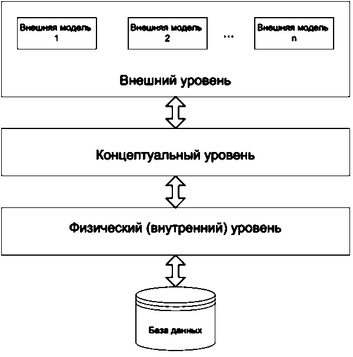

Рис. 7.3. Трехуровневая модель системы управления базой данных

При этом вся эта информация хранится в одной базе данных. Разные приложения могут быть созданы с использованием различных языков программирова-ния. Прикладные программисты чаще применяют либо языки высокого уровня, либо специальные языки СУБД. При рассмотрении приложений, работающих с одной базой данных, предполагается, что они могут работать параллельно и независимо друг от друга. Именно СУБД должна обеспечить работу нескольких приложений с единой базой данных таким образом, чтобы каждое из них выполня-лось корректно, но учитывало все изменения в базе данных, вносимые другими приложениями. Описание представления данных для группы пользователей называется внешней схемой. В системе БД могут одновременно поддерживаться несколько внешних схем для раз-личных групп пользователей или задач. Концептуальный уровень архитектуры является основным и служит для представления базы данных в общем виде для всех ее приложений и независимого от них. Концептуальный уровень является промежуточным уровнем в трехуровневой архитектуре и обеспечивает представление всей информации базы данных в абстрактной форме. Это формализованная информационно-логическая модель предметной области, т.е. это полное представление требований к данным предметной области, не зависящее от способов их представления и хранения. Описание базы данных на этом уровне называется концептуальной схемой. Концептуальная схема включает объекты и их атрибуты, связи между объектами, ограничения, накладываемые на данные, семантическую информацию о данных, обеспечение безопасности и поддержки целостности данных.

Cтр. 117

Концептуальная схема - это единое логическое описание всех элементов данных и отношений между ними, логическая структура всей базы данных. Как любая модель, концептуальная схема отражает только существенные с точки зрения обработки особенности объектов реального мира. Физический (внутренний) уровень архитектуры поддерживает представление базы данных в среде хранения. Описание базы данных на физическом уровне называется внутренней схемой или схемой хранения. Физический уровень - собственно данные, расположенные в файлах или в страничных структурах, расположенных на внешних носителях информации. Это физическая реализация базы данных. На этом уровне необходимо достичь оптимальной производительности и обеспечить экономное использование дискового пространства. На физическом уровне осуществляется взаимодействие СУБД с методами доступа операционной системы с целью размещения данных на запоминающих устройствах, создания индексов, извлечения данных и т.д. На физическом уровне хранится информация о распределении дискового пространства для хранения данных и индексов, описание подробностей сохранения записей (с указанием реальных размеров сохраняемых элементов данных), сведения о размещении записей, сведения о сжатии данных и выбранных методов их шифрования. Физический уровень контролируется операционной системой, но под руководством СУБД. В настоящее время физический уровень практически полностью обеспечивается СУБД. Основной акцент при проектировании БД переносится на создание модели концептуального уровня.

В архитектурной модели ANSI предполагается наличие в СУБД механизмов, обеспечивающих межуровневое отображение данных. Функциональные возможности этих механизмов обеспечивают абстракцию данных и определяют степень независимости данных на всех уровнях. В соответствии междууровневыми отображениями принято выделять логическую и физическую независимость данных. Логическая независимость означает защищенность внешних схем от изменений, вносимых в концептуальную схему. Кроме того, логическая независимость предполагает возможность изменения одного приложения без корректировки других приложений, работающих с этой же базой данных, и реорганизации механизма доступа к физическим данным. Физическая независимость означает защищенность концептуаль-ной схемы от изменений, вносимых в схему хранения, а также предполагает возможность переноса хранимой информации с одних носителей на другие при сохранении работоспособности всех прило-жений, работающих с базой данных.

Cтр. 118

# 7.4. Модели данных

В классической теории баз данных модель данных есть формальная теория представления и обработки данных в системе управления базами данных. Длительное время термин «модель данных» использовался без формального определения. Одним из первых специалистов, который достаточно точно определил это понятие, был Э. Кодд. Хотя понятие модели данных было введено Коддом, наиболее распространенная трактовка модели данных принадлежит Кристоферу Дейту. Согласно его определению, модель данных включает три аспекта: во первых, аспект структуры: методы описания типов и логических структур данных в базе данных; во вторых, аспект манипуляции: методы манипулирования данными; в третьих, аспект целостности: методы описания и поддержки целостности базы данных.

Аспект структуры определяет, что логически представляет собой база данных. Аспект манипуляции содержит спецификацию одного или нескольких языков, предназначенных для написания запросов к БД. Эти языки могут быть абстрактными, не обладающими точно проработанным синтаксисом. Основное назначение манипуляционной части модели данных - обеспечить эталонный язык БД, уровень выразительности которого должен поддерживаться в реализациях СУБД, соответствующих данной модели. Аспект манипуляции опре-деляет способы перехода между состояниями базы данных - способы модификации данных и способы извлечения данных из базы данных. Аспект целостности определяет средства описаний корректных состояний базы данных. В целостной части модели данных описываются механизмы ограничений целостности, которые обязательно должны поддерживаться во всех реализациях СУБД, соответствующих данной модели. В модели данных описывается некоторый набор понятий и признаков, которыми должны обладать все конкретные СУБД и управляемые ими базы данных, если они основываются на этой модели.

Cтр. 119

# Реляционная модель.

Эта модель относится к теоретико-множе-ственным моделям данных и на сегодняшний день является самой популярной как среди пользователей, так и среди профессиональных разработчиков. Она появилась вследствие стремления сделать базу данных как можно более гибкой и предоставила простой и эффективный механизм поддержания связей данных. Реляционная модель единственная из всех обеспечивает единообразие представления данных. В реляционной модели данных информационные объекты представляются в виде таблиц. Каждая таблица базы данных представляется в виде совокупности строк и столбцов. Строки (записи) соответствуют экземпляру объекта, конкретному событию или явлению, а столбцы (поля) - атрибутам, т.е. признакам, характеристикам или параметрам объекта, события или какого-либо явления. Таблица может не содержать и ни одной строки, т.е. может быть пустой. Все строки одной таблицы имеют одинаковую структуру. Таблица в реляционной базе данных может содержать не менее одного столбца. Каждый столбец имеет конкретный тип данных. В базах данных используется некоторое количество типов данных, похожих на те, которые применяются в обычных языках программирования. Поля таблицы должны содержать неделимую информацию. В каждой таблице базы данных необходимо наличие первичного ключа. Первичный ключ - поле или набор полей, однозначно иден-тифицирующий каждый экземпляр объекта или запись. Значение первичного ключа в таблице БД должно быть уникальным, т.е. в таблице не допускается наличие двух и более записей с одинаковыми значениями первичного ключа. Он должен быть минимально доста-точным, а значит, не содержать полей, удаление которых не отразится на его уникальности. Физическое размещение данных в реляционных базах на внешних носителях легко осуществляется с помощью обычных файлов. Достоинство реляционной модели данных заключается в простоте, понятности и удобстве физической реализации на ЭВМ. Именно простота и понятность для пользователя обусловили их широкое использование. Проблемы же эффективности обработки данных этого типа оказались технически вполне разрешимыми. Основ-ным недостатком реляционной модели является сложность описания иерархических и сетевых связей.

Cтр. 120

Многомерная модель данных. В развитии концепций информационных систем можно выделить следующие два направления: системы оперативной обработки и системы аналитической обработки (си-стемы поддержки принятия решений). Реляционные СУБД предназначаются для информационных систем оперативной обработки информации и в этой области являются наиболее эффективными. Однако в системах аналитической обработки они показали себя недостаточно гибкими. Здесь более эффективны многомерные системы управления данными. Многомерные системы позволяют оперативно обрабатывать информацию для проведения анализа и принятия решения. По сравнению с реляционной моделью многомерная организация данных обладает более высокой наглядностью и информативностью. В многомерных СУБД данные организованы в виде упорядоченных многомерных массивов - гиперкубов (рис. 7.4), при этом гиперкубы необязательно должны быть трехмерными. Они обеспечивают более быструю реакцию на запросы данных за счет того, что обращения поступают к относительно небольшим блокам данных, необходимых для конкретной группы пользователей.

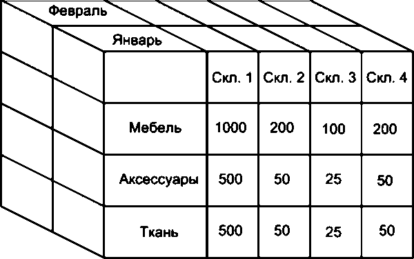

Рис. 7.4. Пример гиперкуба

Технология многомерных баз данных - достаточно новая технология. Несмотря на то что многомерный подход к представлению данных в базе появился практически одновременно с реляционным, реально работающих многомерных СУБД сначала было очень мало. Только с середины 90-х годов интерес к ним стал приобретать массовый характер. Многомерность модели данных означает не визуальное представ-ление, а логическую организацию структуры информации при описании и в операциях манипулирования данными. Для иллюстрации вышеизложенного на рис. 7.5 приведены реляционное (а) и многомерное (б) представления одних и тех же данных (в таблицах хранятся сведения об объемах продаж мебели). Примерами систем, поддерживающих многомерные модели данных, являются Essbase (Arbor Software), Media Multi-matrix (Speedware), Oracle Express Server (Oracle), Cache (Inter Systems). Некоторые программные продукты, например Media/MR (Speedware), позволяют одновременно работать с многомерными и реляционными БД. В СУБД Сасе, в которой внутренней моделью данных является многомерная модель, реализованы три способа доступа к данным: прямой (на уровне узлов многомерных массивов), объектный и реляционный.

Cтр. 121

[output not shown]

(а)

| Модель | Июнь | Июль | Август |
| --- | --- | --- | --- |
| Шкаф | 12 | 24 | 5 |
| Диван | 2 | 18 |  |
| Стол |  | 19 |  |

(б)

Рис. 7.5. Реляционное (а) и многомерное (б) представление данных

# Объектно-ориентированная модель.

Объектно-ориентированные системы управления базами данных являются результатом совмещения возможностей и особенностей баз данных и возможностей объ-ектно-ориентированных языков программирования. Объектно-ориентированные СУБД позволяют работать с объектами баз данных так же, как с объектами в объектно-ориентированных языках програм-мирования. Они расширяют языки программирования, прозрачно вводя долговременные данные, управление параллельной работой с данными, восстановление данных, ассоциированные запросы и другие возможности. Появление объектно-ориентированных СУБД было вызвано потребностями программистов на объектно-ориентированных языках в средствах для хранения объектов, не помещавшихся в оперативной памяти компьютера. Также была важна задача сохранения состояния объектов между повторными запусками прикладной программы. Поэтому большинство объектно-ориентированных систем управления базами данных представляет собой библиотеку, процедуры управления данными которой включаются в прикладную программу. В объектно-ориентированной модели при представлении данных имеется возможность идентифицировать отдельные записи базы. Между записями базы данных и функциями их обработки устанавливаются взаимосвязи с помощью механизмов, подобных соответствующим средствам в объектно-ориентированных языках программирования.

Cтр. 122

Структура объектно-ориентированной БД графически представлена в виде дерева, узлами которого являются объекты. Свойства объектов описываются некоторым стандартным типом (например, строковым - string) или типом, конструируемым пользователем (определяется как class).

Основным достоинством объектно-ориентированной модели данных в сравнении с реляционной является возможность отображения информации о сложных взаимосвязях объектов. Объектно-ориентированная модель данных позволяет идентифицировать отдельную запись базы данных и определять функции их обработки.

Недостатками объектно-ориентированной модели являются высокая понятийная сложность и неудобство обработки.

Реакцией производителей реляционных СУБД на возрастающую популярность объектных технологий стало появление объектно-реляционных баз данных, так называемых универсальных серверов. Объектно-реляционная СУБД — реляционная СУБД, поддержива-ющая некоторые технологии, реализующие объектно-ориентированный подход: объекты, классы и наследование реализованы в структуре баз данных и языке запросов. Объектно-реляционными СУБД являются, к примеру, широко известные Oracle Database, Informix, DB2.

Основные преимущества объектно-реляционной модели — возможность повторного и совместного использования компонентов.

Очевидным недостатком подхода с использованием объектно-реляционной СУБД являются сложность и связанные с ней повышенные расходы. Простота и ясность, присущая реляционной модели, теряется при использовании подобных типов расширения.

Cтр. 123

# Глава 8. ОСНОВЫ ПРОЕКТИРОВАНИЯ БАЗ ДАННЫХ

8.1. Задачи проектирования баз данных

Процесс проектирования баз данных длительный, он требует обсуждений с заказчиком, со специалистами в предметной области. При разработке серьезных корпоративных информационных систем проект базы данных является тем фундаментом, на котором строится вся система в целом. Проектирование баз данных состоит в построении комплекса взаимосвязанных моделей данных. При создании базы данных для информационной системы наиболее важными являются задачи, связанные с разработкой правиль-ной логической структуры данных, обеспечивающей выполнение всего требуемого набора функций информационной системы. Плохо продуманная база данных оказывается, как правило, неэффективной и даже бесполезной. Разработка базы данных - достаточно сложная задача. Зачастую к ней предъявляется много противоречивых требо-ваний. Создание правильной логической структуры предусматривает комплексный анализ всех факторов, влияющих на формирование и обработку данных.

Задача проектировщика состоит в учете всех этих факторов с целью разработки наиболее оптимальной базы данных. Основные задачи проектирования баз данных можно сформулировать следующим образом: обеспечение хранения в БД всей необходимой информации; обеспечение возможности получения данных по всем необходимым запросам; сокращение избыточности и дублирования данных; обеспечение целостности базы данных. В том, как решаются эти задачи, мы и будем разбираться. Процесс проектирования БД представляет собой последовательность переходов от неформального словесного описания информационной структуры предметной области к формализованному описанию объектов предметной области в терминах некоторой модели.

Cтр. 124

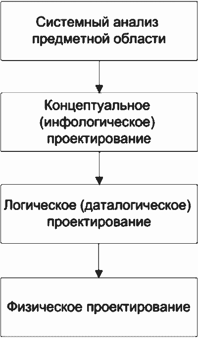

Рис. 8.1. Этапы проектирования БД

Концептуальное (инфологическое) проектирование - построение семантической модели предметной области, т.е. информационной модели наиболее высокого уровня абстракции. Такая модель создается без ориентации на какую-либо конкретную СУБД и модель данных. Термины «семантическая модель», «концептуальная модель» и «инфологическая модель» являются синонимами. Кроме того, в этом контексте равноправно могут использоваться слова «модель базы данных» и «модель предметной области» (например, «концеп» туальная модель базы данных» и «концептуальная модель предметной области»), поскольку такая модель является образом как реальности, так и проектируемой базы данных для этой реальности.

Cтр. 125

Конкретный вид и содержание концептуальной модели базы данных определяются выбранным для этого формальным аппаратом. Обычно используются графические нотации, подобные ER-диаграммам. Чаще всего концептуальная модель базы данных включает в себя: описание информационных объектов, или понятий предметной области и связей между ними; описание ограничений целостности, т.е. требований к допустимым значениям данных и к связям между ними. Логическое (даталогическое) проектирование — создание схемы базы данных на основе конкретной модели данных, например реля-ционной. Для реляционной модели данных логическая модель - набор схем отношений, обычно с указанием первичных ключей, а также «связей» между отношениями, представляющих собой внешние ключи. Преобразование концептуальной модели в логическую, как правило, осуществляется по формальным правилам. Этот этап может быть в значительной степени автоматизирован.

На этапе логического проектирования учитывается специфика конкретной модели данных, но может не учитываться специфика конкретной СУБД. Физическое проектирование - создание схемы базы данных для конкретной системы управления базами данных. Специфика конкретной СУБД может включать в себя ограничения на именование объектов базы данных, на поддерживаемые типы данных и т.п. Кроме того, специфика конкретной СУБД при физическом проектировании включает выбор решений, связанных с физической средой хранения данных (выбор методов управления дисковой памятью, разделение БД по файлам и устройствам, методов доступа к данным), создание индексов и т.д. В области проектирования и разработки баз данных используются различные средства моделирования предметной области и БД, причем даже в рамках одной конкретной системы необходим целый комплекс моделей разного назначения. Далее рассмотрим каждый из этих этапов более подробно.

Cтр. 126

# 8.2. Концептуальное моделирование

Концептуальная модель — это определенное множество понятий и связей между ними, являющихся смысловой структурой рассматриваемой предметной области. Эта модель является начальным прототипом будущей базы данных, но строится без привязки к конкретной СУБД. Процесе разработки концептуальной модели предметной области является творческим и довольно трудно поддается формализации. Для построения концептуальной модели необходимо хорошее знание предметной области, ее семантики, понимание логических взаимосвязей ее информации. В 70-80-е годы в литературе концептуальное проектирование баз данных обозначалось терминами «инфологическое проектирование» и «инфологическая модель». На рис. 8.2 дается схема построения концептуальной модели от исходной информации до результата. В 1976 г. Питером Ченом была предложена так называемая модель «сущность-связь» («entity-relationship»). Она включает сущности и взаимосвязи, отражающие основные бизнес-правила предметной области. В настоящее время для модели «сущность-связь» общепринятым стало сокращенное название - ER-модель. В дальнейшем многими авторами были разработаны свои варианты подобных моделей. Но все варианты моделей «сущность-связь» исходят из одной идеи - графическое изображение нагляднее текстового описания. В настоящее время ER-модель стала фактически стандартом для семантической структуризации предметной области - стандартом при концептуальном моделировании баз данных. В качестве стандартной графической нотации, с помощью которой можно визуализировать ER-модель, была предложена диаграмма сущность-связь (ER-диаграмма). ER-диаграмма изображается с помощью трех конструктивных элементов: сущность, атрибут и связь.

Сущность — это класс однотипных объектов, информация о которых имеет существенное значение для рассматриваемой предметной области. Сущность представляет собой множество экземпляров реальных или абстрактных объектов (людей, событий, состояний, предметов и т.п.). Экземпляр сущности - это конкретный представитель данной сущности. Каждый экземпляр сущности должен быть отличим от любого другого экземпляра той же сущности. Например, представи - телем сущности «Сотрудник» может быть «Сотрудник Иванов И.И.». Существует несколько систем нотаций (условных обозначений, языков) для описания объектно-связного представления предметной области. Нотация Баркера является наиболее распространенной. На диаграмме в нотации Баркера сущность изображается прямоугольником, иногда с закругленными углами (рис. 8.3, а). Каждая сущность обладает одним или несколькими атрибутами. Атрибут сущности - это именованная характеристика, являющаяся некоторым свойством сущности. Атрибут предназначен для квалификации, идентификации, классификации, количественной характеристики или выражения состояния сущности (рис. 8.3, б).

Cтр. 127

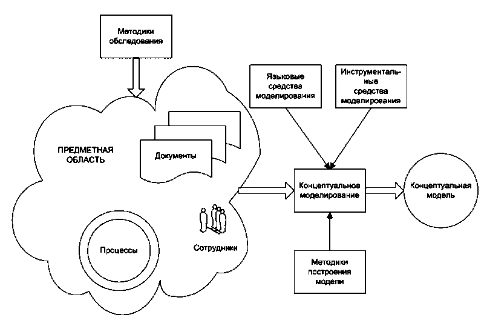

Рис. 8.2. Схема построения концептуальной модели

Экземпляр атрибута - определенная характеристика конкретного экземпляра сущности, значение атрибута (например, «цвет» - это атрибут, а «зеленый» - экземпляр атрибута).

Cтр. 128

Первичный ключ сущности - это неизбыточный набор атрибутов, значения которых в совокупности являются уникальными для каждого экземпляра сущности. Неизбыточность заключается в том, что удаление любого атрибута из состава ключа приведет к нарушению его уникальности. Первичный ключ предназначен для уникальной идентификации каждого экземпляра сущности, т.е. представляет собой совокупность признаков, позволяющих идентифицировать объект. Ключевые атрибуты помещают в начало списка и помечают символом «#» (рис. 8.3, в).

Связь — это отношение одной сущности к другой или к самой себе. Каждая сущность может обладать любым количеством связей с другими сущностями модели. Различают три типа связей (рис. 8.4): $1*1$ — «один-к-одному»; $1*n$ — «один-ко-многим»; $n*m$ — «многие-ко-многим».

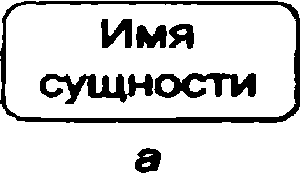

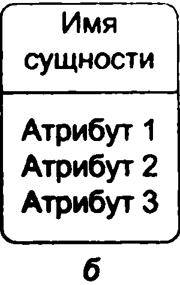

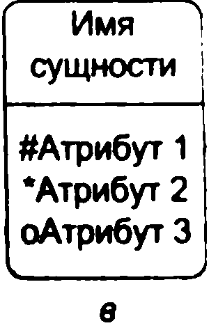

Рис. 8.3. Обозначения сущности в нотации Баркера: а - без атрибутов; б - с указанием атрибутов; в — с уточнением атрибутов и их типов (# — ключевой, * — обязательный, о — необязательный)

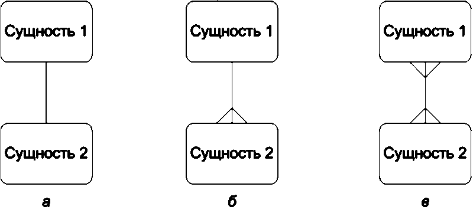

Рис. 8.4. Обозначение разных типов связи в нотации Баркера: а — «один-к-одному»; б — «один-ко-многим»; в - «многие-ко-многим»

Связь типа «один-к-одному» означает, что один экземпляр первой сущности связан только с одним экземпляром второй сущности. Такая связь, скорее всего, свидетельствует о том, что была неверно разделена одна сущность на две (хотя иногда к такому типу связи прибегают в случае, если есть необходимость «засекретить» часть данных). Связь типа «один-ко-многим» означает, что каждый экземпляр первой сущности связан с несколькими экземплярами второй сущности. Связь типа «многие-ко-многим» означает, что каждый экземпляр первой сущности может быть связан с несколькими экземплярами второй сущности, и наоборот. Такой тип связи является временным, допустимым на ранних этапах разработки модели. В дальнейшем такую связь необходимо заменить двумя связями типа «один-ко-многим» путем выделения промежуточной сущности.

Cтр. 129

Некоторые ограничения целостности задаются на ER-диаграмме, другие описываются на естественном языке. В качестве примера рассмотрим небольшую базу данных, отражающую процесс поставки и продажи некоторого товара постоянным клиентам. База данных проектируется для автоматизированной информационной системы «Склад оптовой торговли». Исходя из анализа предметной области, можно выделить следующие сущности — Товар, Поставщик и Покупатель. Сразу возникает очевидная связь между сущностями — «покупатели могут приобретать много товаров», «товары могут приобретаться многими покупателями» Отношение между ними относится к типу «многие-ко-многим» (рис. 8.5).

Cтр. 130

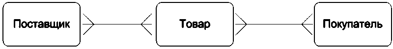

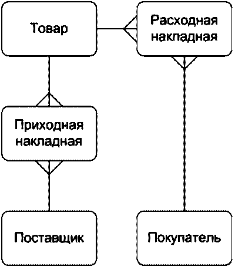

Рис. 8.6. Промежуточный вариант ER-диаграммы

Проанализируем атрибуты сущностей. Каждый поставщик и покупатель являются юридическими лицами и имеют наименование, адрес, банковские реквизиты. Каждый товар имеет наименование, цену, характеризуется единицей измерения. Каждая накладная имеет уникальный номер, дату выписи, список товаров с количествами и ценами, а также общую сумму накладной. Покупатели покупают товары, получая при этом расходные накладные, в которые внесены данные о количестве и цене приобретенного товара. Каждый покупатель может получить несколько накладных. Каждая накладная должна выписываться на одного покупателя и должна содержать не менее одного товара (не может быть «пустой» накладной). Каждый товар, в свою очередь, может быть продан нескольким покупателям по нескольким накладным. Аналогичную цель рассуждений можно выстроить для определения связей между сущностями «Товар» и «Поставшик». Покупатель может быть одновременно и поставщиком, поэтому эти два объекта объединены в одну сущность «Контрагент».

Важной задачей в создании базы данных является выявление первичных ключей. Для таблицы «Товар» название товара не может служить первичным ключом, так как товары разных типов могут иметь одинаковые названия, поэтому введем первичный ключ «Код», под которым можно понимать, например, артикул товара. Точно так же «Наименование» не может служить первичным ключом в таблице «Контрагенты». Введем первичный ключ «Код» для поставщиков и покупателей, под которым можно понимать номер паспорта, идентификационный номер налогоплательщика или любой другой атрибут, однозначно определяющий каждого контрагента. Для таблиц «Расходная накладная»/«Приходная накладная» первичным ключом является поле «Номер», так как номер однозначно определяет каждую накладную. Теперь можно все это внести в диаграмму. После уточнения диаграмма будет выглядеть следующим образом (рис. 8.7).

Cтр. 131

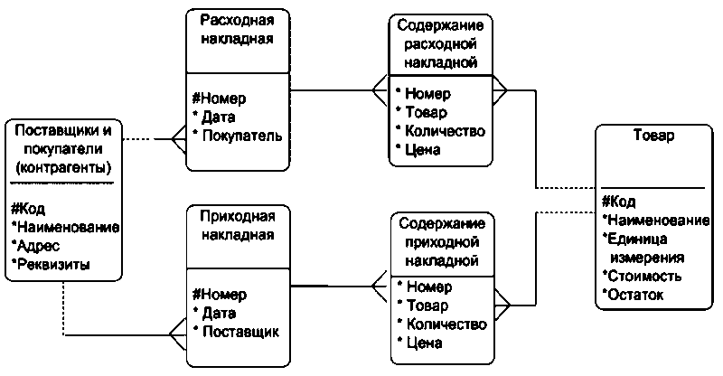

Рис. 8.7. Окончательный вариант ER-диаграммы

Данная диаграмма должна быть проверена с точки зрения возможности получения всех выходных данных, показанных на диаграмме потоков данных разрабатываемой системы. В качестве самостоятельного объекта в ER-модели следует изображать сущности, для которых фиксируются какие-либо их свойства, либо участвующие более чем в одной связи. При возникновении сомнений лучше принять решение о создании самостоятельного объекта, так как это в дальнейшем потребует меньших изменений в модели. Следует помнить, что количественные характеристики всегда являются свойствами какого-либо объекта, и никогда — самостоятельными объектами. Например, год рождения не может рассматриваться как самостоятельный объект. Построение концептуальной модели может выполняться как «вручную», так и с использованием автоматизированных средств проектирования - CASE-средств.

Cтр. 132

# 8.3. Логическое проектирование и физическая модель БД

При проектировании логической структуры БД осуществляются преобразование исходной концептуальной модели в модель данных, поддерживаемую конкретной СУБД, и проверка адекватности полученной логической модели отображаемой предметной области. Для любой предметной области существует множество вариантов проектных решений ее отображения в логической модели. Методика проектирования должна обеспечивать выбор наиболее подходящего проектного решения. Этап создания логической модели называется логическим проектированием. При переходе от концептуальной (инфологической) модели к логической (даталогической) следует иметь в виду, что концептуальная модель должна включать в себя всю информацию о предметной области, необходимую для проектирования базы данных. Преобразование концептуальной модели в логическую, осуществляется по формальным правилам. Логическая модель базы данных строится в терминах информационных единиц, допустимых в той конкретной СУБД, в среде которой мы проектируем базу данных.

Описание логической структуры базы данных на языке СУБД называется схемой данных. Спроектировать логическую структуру базы данных означает определить все информационные единицы и связи между ними, задать их имена; если для информационных единиц возможно использование разных типов, то определить их тип. Следует также задать некоторые количественные характеристики, например длину поля. Любая система управления данными оперирует с допустимыми для нее логическими единицами данных. Кроме того, многие СУБД накладывают количественные и иные ограничения на структуру базы данных. Поэтому, прежде чем приступить к построению логической модели, необходимо детально изучить особенности СУБД, возможности и целесообразности ее использования, ознакомиться с существующими методиками проектирования, а также проанализировать имеющиеся средства автоматизации проектирования.

Хотя логическое проектирование является проектированием логической структуры базы данных, на него оказывают влияние возможности физической организации данных, предоставляемые конкретной СУБД. Следовательно, при проектировании логической структуры необходимо знание особенностей физической организации данных. В базе данных отражается определенная предметная область. Поэтому процесс проектирования БД предусматривает предварительную классификацию объектов предметной области, систематизиро-ванное представление информации об объектах и связях между ними. На проектные решения оказывают влияние особенности требуемой обработки данных. Значит, соответствующая информация должна быть определенным образом представлена и проанализирована на начальных этапах проектирования БД.

Cтр. 133

В концептуальной модели должна быть отображена вся информания, циркулирующая в информационной системе. Но это вовсе не означает, что вся она должна храниться в базе данных и все сушности, зафиксированные в концептуальной модели, должны в явном виде отражаться в логической модели. Прежде чем строить логическую модель, необходимо решить, какая информация будет храниться в базе данных. Например, в концептуальной модели должны быть отражены вычисляемые показатели, но вовсе не обязательно, что они должны храниться в базе данных. В связи с этим одним из первых шагов проектирования является определение состава БД, т.е. перечня тех показателей, которые целесообразно хранить в базе данных. Кроме того, не все виды связей, существующие в предметной области, могут быть непосредственно отображены в конкретной логической модели. Так, многие СУБД не поддерживают непосредственно отношение «многие-ко-многим» между элементами. В этом случае в логическую модель вводится дополнительный вспомогательный элемент, отображающий эту связь (таким образом, отношение «многие-ко-многим» как бы разбивается на два отношения «один-ко-многим» между этим вновь введенным элементом и исходными элементами). Пример этого был приведен ранее.

Для привязки логической модели к среде хранения используется модель данных физического уровня, для краткости часто называемая физической моделью. Эта модель определяет способы физической организации данных в среде хранения. Модель физического уровня строится с учетом возможностей, предоставляемых СУБД. Описание физической структуры базы данных называется схемой хранения. Соответствующий этап проектирования БД называется физическим проектированием. СУБД обладают разными возможностями по физической организации данных. В связи с этим различаются для конкретных систем сложность и трудоемкость физического проектирования и набор выполняемых шагов.

Физическая модель данных описывает данные средствами конкретной СУБД. На этапе физического проектирования учитывается специфика конкретной модели данных и специфика конкретной СУБД. Отношения, разработанные на стадии формирования логической модели данных, преобразуются в таблицы, атрибуты становятся столбцами таблиц, для ключевых атрибутов создаются уникальные индексы, домены преображаются в типы данных, принятые в используемой СУБД. Ограничения, имеющиеся в логической модели данных, реализуются различными средствами СУБД, например при помоши индексов, ограничений целостности, триггеров, хранимых процедур. При этом решения, принятые на уровне логического моделирования, определяют некоторые границы, в пределах которых можно развивать физическую модель данных. Точно также в пределах этих границ можно принимать различные решения. Например, отношения, содержащиеся в логической модели данных, должны быть преобразованы в таблицы, но для каждой таблицы можно дополни-тельно объявить различные индексы, повышающие скорость обращения к данным. Многое тут зависит от конкретной СУБД.

Cтр. 134

Физическое проектирование БД предполагает также выбор эффективного размещения БД на внешних носителях для обеспечения наиболее эффективной работы приложения. На этапе физического моделирования производятся оценка требований к вычислительным ресурсам, необходимым для функционирования системы, выбор типа и конфигурации ЭВМ, типа и версии операционной системы. Выбор зависит от таких показателей, как: примерный объем данных в БД; динамика роста объема данных; характер запросов к данным (извлечение и обновление отдельных записей, обработка групп записей, обработка отдельных отношений или соединение отношений); интенсивность запросов к данным по типам запросов; требования к времени отклика системы по типам запросов.

Выбор СУБД и инструментальных программных средств является одним из важнейших моментов в разработке проекта базы данных, так как он принципиальным образом влияет на весь процесс проектирования БД и реализации информационной системы. Теоретически при осуществлении этого выбора нужно принимать во внимание десятки факторов. Но на практике разработчики руководствуются лишь собственной интуицией и несколькими наиболее важными критериями, к которым, в частности, относятся: тип модели данных, которую поддерживает данная СУБД, адек-ватность модели данных структуре рассматриваемой ПО; характеристики производительности СУБД; запас функциональных возможностей для дальнейшего развития информационной системы; степень оснащенности СУБД инструментарием для персонала администрирования данными; удобство и надежность СУБД в эксплуатации; стоимость СУБД и дополнительного программного обеспечения.

Cтр. 135

# 8.4. Нормализация таблиц баз данных

С теорией нормализации связана классическая технология проектирования реляционных баз данных. Нормализация представляет собой процесс реорганизации данных путем ликвидации избыточ-ности данных и иных противоречий с целью приведения таблиц к виду, позволяющему осуществлять непротиворечивое и корректное редактирование данных. Цель нормализации сводится к получению оптимальной структуры базы данных с минимальной логической избыточностью. Метод нормализации основан на теории реляционных моделей данных. Исходной точкой является представление предметной области в виде одного или нескольких отношений, и на каждом шаге проектирования производится некоторый набор таблиц, обладающих «улучшенными» свойствами. Процесс проектирования представляет собой процесс нормализации схем отношений. Иными словами, осуществляется декомпозиция отношения, находящегося в предыдущей нормальной форме, в два или более отношения, удовлетворяющих требованиям следующей нормальной формы.

В теории реляционных баз данных обычно выделяется следующая последовательность нормальных форм:

- первая нормальная форма (1нф, 1 Normal Form, 1NF);
- вторая нормальная форма (2нф, 2NF);
- третья нормальная форма (3нф, 3NF);
- нормальная форма Бойса-Кодда (BCNF);
- четвертая нормальная форма (4нф, 4NF);
- пятая нормальная форма, или нормальная форма проекции-сое-динения (5нф, 5NF, или PJ/NF).

Каждой нормальной форме соответствует некоторый определенный набор ограничений, и отношение находится в некоторой нормальной форме, если удовлетворяет свойственному ей набору ограничений. Обычно на практике применение находят только первые три нормальные формы, которые и будут рассмотрены далее. Процесс проектирования базы данных с использованием метода нормальных форм является пошаговым. Проектирование начинается с определения всех объектов, информация о которых должна содержаться в базе данных, определения атрибутов этих объектов. Атрибуты всех объектов сводятся в одну таблицу, которая является исходной. Эта таблица приводится к первой нормальной форме в соответствии с ее требованиями. Затем эта таблица декомпозируется на две или несколько таблиц, те, в свою очередь, тоже могут быть преобразованы в другие таблицы. Так последовательно создается совокупность взаимосвязанных таблиц, отвечающих требованиям нормальных форм. На практике обычно используют первые три нормальные формы.

Cтр. 136

Для примера разработаем базу данных для хранения сведений о студентах: ФИО, год рождения, группа, классный руководитель, шифр и наименование специальности. Приведенная таблица имеет довольно простую структуру, на практике таблица содержала бы гораздо больше данных. Но для демонстрации процедуры нормализации этих данных вполне достаточно. Тип и размер полей в данном случае большой роли не играют, поэтому ограничимся только их названиями. Созданную таблицу будем рассматривать как однотабличную базу данных. Для того чтобы таблица соответствовала требованиям первой нормальной формы, должно выполняться следующее условие — поля таблицы должны содержать неделимую (атомарную) информацию. Приведем исходную таблицу к первой нормальной форме. Тогда в таблице «Студенты» будет 6 столбцов: ФИО, Год рождения, Шифр, Специальность, Группа, Классный руководитель (рис. 8.8).

| ФИО | Год рожд. | Специальность | Шифр | Группа | Классный руководитель |
| --- | --- | --- | --- | --- | --- |
| Иванов Ф И | 1998 | Информационные системы | 230401 | 35и | Попенко Б С |
| Кириллова Е Е | 1998 | Информационные системы | 230401 | 35и | Попенко Б С |
| Поталов В С | 1998 | Информационные системы | 230401 | 35и | Попенко Б С |
| Дудко О В | 1997 | Информационные системы | 230401 | 35и | Попенко Б С |
| Таран О С | 1998 | Обработка металлов давлением | 150412 | 480 | Демина Е. Е |
| Ильин Г С | 1998 | Компьютерные сети | 230111 | 44к | Павлова Н.И |
| Федорова Д С | 1998 | Информационные системы | 230401 | 35и | Попенко Б С |
| Медведева Ж А | 1997 | Компьютерные сети | 230111 | 44к | Павлова Н И |
| Пушкина А А | 1998 | Компьютерные сети | 230111 | 44к | Павлова Н И |

Рис. 8.8. Таблица, соответствующая 1-й нормальной форме

Ко второй нормальной форме предъявляются следующие требования: таблица должна удовлетворять требованиям первой нормальной формы; любое неключевое поле должно однозначно идентифицироваться ключевыми полями. Другими словами, таблица находится во второй нормальной форме в том и только в том случае, если эта таблица соответствует первой нормальной форме и каждый неключевой атрибут полностью зависит от первичного ключа. Записи таблицы, приведенной к первой нормальной форме не являются уникальными. Таблица на рис. 8.8 соответствует Інф, но ввиду отсутствия первичного ключа не соответствует 2нф. Чтобы обеспечить уникальность записей, введем в таблицу ключевое поле - номер студенческого билета. При этом значение ключа будет однозначно идентифицировать каждую запись в таблице (рис. 8.9). Записи этой таблицы имеют значительное избыточное дублирование данных, так как классный руководитель указывается для каждой группы, а наименование специальности - для каждого шифра специальности. Избавиться от дублирования можно, разбив таблицу. При этом таблицы будут соответствовать 3нф.

Cтр. 137

| Ном. | ФИО | Год рожд. | Специальность | Шифр | Группа | Классный руководитель |
| --- | --- | --- | --- | --- | --- | --- |
| 101 | Иванов Ф.И | 1998 | Информационные системы | 230401 | 35и | Попенко Б.С |
| 102 | Кириллова Е.Е | 1998 | Информационные системы | 230401 | 35и | Попенко Б.С |
| 103 | Потапов В.С | 1998 | Информационные системы | 230401 | 35и | Попенко 6 С |
| 104 | Дудко О.В | 1997 | Информационные системы | 230401 | 35 | Попенко Б С |
| 105 | Таран О.С | 1998 | Обработка металлов давлением | 150412 | 480 | Демина Е.Е |
| 106 | Ильин Г.С | 1998 | Компьютерные сети | 230111 | 44к | Павлова Н.И |
| 107 | Федорова Д.С. | 1998 | Информационные системы | 230401 | 35и | Попенко Б.С |
| 108 | Медведева Ж.А | 1997 | Компьютерные сети | 230111 | 44К | Павлова Н.И |
| 109 | Пушкина А.А | 1998 | Компьютерные сети | 230111 | 44к | Павлова Н.И |

Рис. 8.9. Таблица, соответствующая второй нормальной форме

Cтр. 138

[output not shown]

| Код | Специальность | Шифр |
| --- | --- | --- |
| 10 | Информационные системы | 230401 |
| 30 | Обработка металлов давлением | 150412 |
| 20 | Компьютерные сети | 230111 |

| Код | Группа | Классный руководитель |
| --- | --- | --- |
| 13 | 35и | Попенко Б.С |
| 15 | 480 | Демина Е.Е |
| 14 | 44к | Павлова Н.И. |

Рис. 8.10. Таблицы в третьей нормальной форме

Требования третьей нормальной формы следующие: таблица должна удовлетворять требованиям второй нормальной формы; неключевые поля не зависят друг от друга.

Cтр. 139

На рис. 8.9 таблица не соответствует 3нф, потому что значение поля «Классный руководитель» зависит от номера группы, а наименование специальности зависит от шифра, и наоборот. Для того чтобы привести таблицу в соответствие третьей нормальной форме, следует разбить ее на несколько таблиц. Информацию о специальностях и о группах нужно вынести в отдельные таблицы, в каждой из которых определить свой первичный ключ. После приведения к третьей нормальной форме база данных будет иметь структуру, показанную на рис. 8.10. В таблице «Студенты» теперь вместо полной информации о специальности и группе хранится только код специальности и код группы соответственно. Следование требованиям нормальных форм не всегда является обязательным. С ростом числа таблиц усложняется структура базы данных и увеличивается время обработки данных. В ряде случаев для упрощения структуры можно позволить частичное дублирование данных, при этом не допуская нарушения их целостности и соблюдая непротиворечивость.

Cтр. 140

# Глава 9. АРХИТЕКТУРЫ СИСТЕМЫ ОБРАБОТКИ ДАННЫХ

### 9.1. Архитектура файл-сервер

В архитектуре файл-сервер базы данных хранятся на сервере, клиент обращается к серверу с файловыми командами, а механизм управления всеми информационными ресурсами находится на компьютере клиента (рис. 9.1).

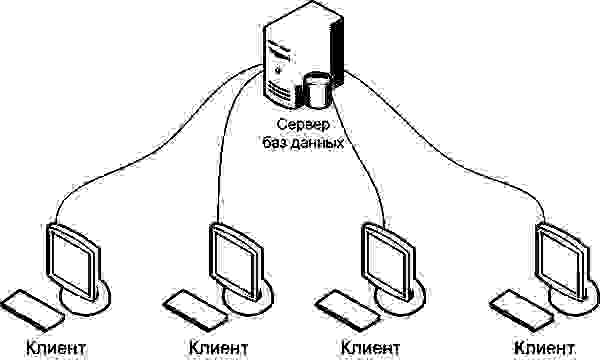

Рис. 9.1. Архитектура «файл-сервер»

Cтр. 141

Если записей в базе данных много, то даже при небольшом числе клиситов сеть будет загружена очень основательно, что серьезно скажется на скорости выполнения запросов. В результате циркуляции в сети больших объемов избыточной информации резко возрастает нагруза на сеть, что приводит к соответствующему снижению ее быстродействия и производительности информационной системы в целом. Значительный сетевой трафик особенно сказывается при организации удаленного доступа к базам данных на файл-сервере через низкоско-ростные каналы связи. Другой недостаток связан с тем, что забота о целостности данных при такой организации работы возлагается на программы клиентов. Одним из традиционных средств, на основе которых создаются файл-серверные системы, являются локальные СУБД. При их использовании задача обеспечения целостности данных возлагается на клиентские приложения, что приводит к их усложнению. Если они недостаточно тщательно продуманы, в базу данных легко занести ошибки, которые могут отразиться на всех пользователях.

Кроме того, в файл-серверной архитектуре изменения, сделанные в базе данных одним пользователем, не видны другим пользователям. Пока один пользователь редактирует какую-либо запись, она заблокирована для других клиентов. Возникает необходимость синхронизации работы отдельных пользователей, связанная с блокировкой записей. И еще один недостаток - управление базой данных осуществляется с разных компьютеров, поэтому в значительной степени затруднена организация контроля доступа, соблюдения конфиденциальности, что также усложняет поддержку целостности базы данных. Тем не менее файл-серверная архитектура привлекает своей простотой и доступностью. Поэтому файл-серверные информационные системы до сих пор представляют интерес для малых рабочих групп. Такие системы имеют достаточно обширную область применения. Прежде всего это государственные (муниципальные) учреждения, сфера образования, сфера обслуживания, малый и средний бизнес. Специфика решаемых там задач заключается в том, что объемы данных не являются чрезвычайно большими, обновления производятся не слишком часто, организация территориально обычно расположена в одном небольшом здании, количество пользователей колеблется от одного до десяти человек. В подобных условиях использование настольных СУБД для управления информационными системами вполне оправданно.

Cтр. 142

Одними из первых СУБД были так называемые d Base-совмести мые программные системы, разработанные разными фирмами: dBase II - PLUS (фирма Achton-Tate), Clipper (фирма Nantucket Inc.), FoxPro (фирма Fox Software), FoxBase + (фирма Fox Software), Visual FoxPro (фирма Microsoft). Одно время достаточно широко исполь-зовалась СУБД PARADOX (фирма Borland International). В последние годы очень широкое распространение получила система управления базами данных Microsoft Access, которая входит в целый ряд версий пакета Microsoft Office (фирма Microsoft). Для крупных организаций ситуация принципиально меняется. Там использование файл-серверных технологий является неприемлемым по описанным выше причинам. Поэтому используются более дорогостоящие серверные СУБД.

# 9.2. Архитектура клиент-сервер

Особенностью архитектуры клиент-сервер является наличие вы-деленных серверов баз данных, принимающих запросы на языке структурированных запросов (Structured Query Language, SQL) и выполняющих поиск, сортировку, агрегирование информации и прочие операции. В общем случае предполагается, что клиент и сервер функционируют на разных компьютерах. Сервер - программа, реализующая функции СУБД, такие как определение данных, запись, чтение, удаление данных, диспетчери-зация и оптимизация выполнения запросов, защита данных. Клиент - программа (приложение), обращающаяся для выполнения операций с данными к компонентам СУБД через внешние интерфейсы.

Разделение процесса выполнения запроса на «клиентскую» и «серверную» часть позволяет: различным прикладным (клиентским) программам одновременно использовать общую базу данных; централизовать функции управления, такие как защита информации, обеспечение целостности данных, управление совместным использованием ресурсов; обеспечивать параллельную обработку запросов; высвобождать ресурсы компьютеров-клиентов; повышать эффективность управления данными за счет использования специализированных компьютеров - серверов баз данных.

База данных на платформе клиент-сервер используется для систем с большим количеством пользователей. В контексте базы данных клиент управляет пользовательским интерфейсом и логикой прило-жения, действуя как рабочая станция. Сервер принимает и обрабатывает запросы от клиентов и отправляет им полученные результаты. Такая обработка включает проверку полномочий клиента, обеспечение требований целостности, выполнение запросов, обновление данных. Помимо этого, поддерживается управление параллельностью и восстановлением.

В базах данных клиент-сервер возникает дополнительная проблема - спроектировать приложение так, чтобы оно максимально использовало возможности сервера и минимально нагружало сеть, передавая через нее только необходимую информацию. Описанная архитектура является двухуровневой и называется «толстым клиентом» (рис. 9.2), так как реализация основной функциональности сосредоточена на компьютере клиента и приложение имеет большой вес.

Cтр. 143

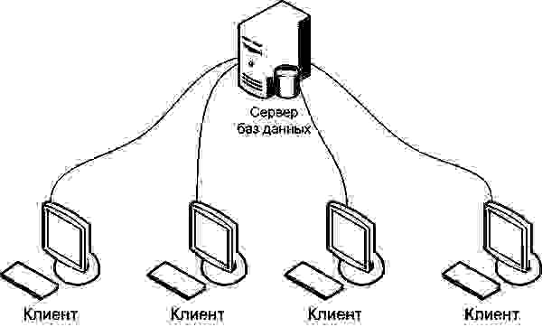

Рис. 9.2. Двухуровневая архитектура клиент-сервер

В настоящее время архитектура клиентсервер получила признание и широкое распространение как способ организации информационных систем корпоративного уровня. Подобная организация повышает эффективность работы приложений за счет использования возможностей сервера базы данных, снижения нагрузки на сеть и обеспечения контроля целостности данных. Повышение безопасности информации связано с тем, что обработка запросов всех клиентов выполняется единой программой, расположенной на сервере. Сервер устанавливает общие для всех пользователей правила использования БД, управляет режимами доступа клиентов к данным, запрешая, в частности, одновременное изменение одной записи разными пользователями. Также уменьшается сложность клиентских приложений за счет отсутствия у них кода, связанного с контролем БД и разграничением доступа к ней.

Cтр. 144

К числу недостатков можно отнести более высокие финансовые затраты на аппаратное и программное обеспечение, а также то, что большое количество клиентских компьютеров, расположенных в разных местах, вызывает определенные трудности со своевременным обновлением клиентских приложений на всех компьютерах-клиентах. В архитектуре клиент-сервер работают так называемые «промышленные» СУБД. Промышленными они называются из-за того, что именно СУБД этого класса могут обеспечить работу информационных систем масштаба среднего и крупного предприятия, организации, банка. К разряду промышленных СУБД принадлежат MS SQL Server, Oracle, Informix, Sybase, DB2, InterBase и ряд других. Двухуровневые схемы архитектуры клиент-сервер могут привести к некоторым проблемам в сложных информационных приложениях с множеством пользователей и запутанной логикой. Решением этих проблем может стать применение многоуровневой архитектуры.

# 9.3 Трехуровневая архитектура клиент-сервер

Дальнейшее расширение двухуровневой архитектуры клиент-сервер предполагает разделение функциональной части «толстого» («интеллектуального») клиента на две части (рис. 9.3).

На нижнем уровне на компьютерах пользователей расположены приложения клиентов, выделенные для выполнения функций и логики представлений, обеспечивающие программный интерфейс для вызова приложения на среднем уровне. Приложение нижнего уровня называют «тонким» или «облегченным» клиентом. В качестве клиента может выступать обычный web-браузер.

На среднем уровне расположен сервер приложений, на котором выполняется прикладная логика, и с которого логика обработки данных выполняет операции с базой данных, т.е. этот уровень обеспечивает обмен данными между пользователями и базами данных. Сервер приложений размешается в узле сети доступно всем клиентам.

На третьем, верхнем, уровне расположен удаленный специализированный сервер базы данных, принимающий информацию от сервера приложений. Сервер баз данных выделен для услуг обработки данных и файловых операций.

Кратко можно следующим образом описать работу СУБД с трехзвенной архитектурой клиент-сервер. СУБД и база данных в виде набора файлов находится на жестком диске специально выделенного компьютера (сервера сети). На специально выделенном сервере приложений располагается программное обеспечение (бизнес-логика). На каждом клиентском компьютере установлен так называемый «тонкий» клиент -- клиентское приложение, реализующее интерфейс пользователя. Клиент инициирует обращение к программному обеспечению, расположенному на сервере приложений. Сервер приложений формирует запросы к БД на языке SQL, т.е. по сети от сервера приложений к серверу БД передается лишь текст запроса. Результат выполнения запроса копируется на сервер приложений, который возвращает результат в клиентское приложение (пользователю). Приложение отображает результат выполнения запросов.

Cтр. 145

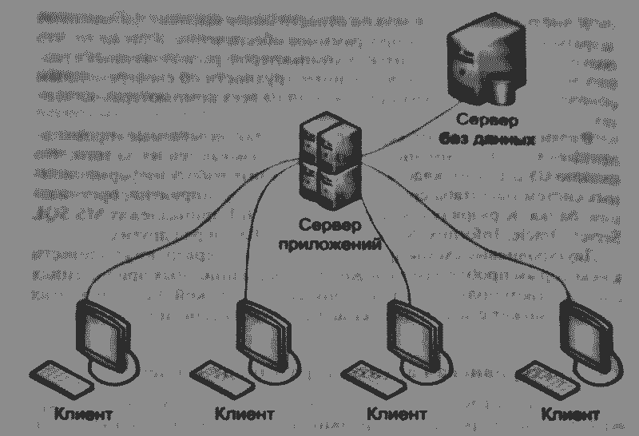

Рис. 9.3. Трехуровневая архитектура клиент-сервер

Достоинства трехуровневой архитектуры: разгрузка сервера баз данных от выполнения части операций, пе-ренесенных на сервер приложений; уменьшение размера клиентских приложений за счет разгрузки их от лишнего кода; упрощение настройки клиентов - при изменении общего кода сервера приложений автоматически изменяется поведение приложений клиентов, т.е. обеспечивается единое поведение всех клиентов; еще больше сбалансирована нагрузка на сеть. С ростом пользователей систем клиент-сервер необходимость трехуровневой организации становится все более очевидной.

Cтр. 146

# 9.4. Кластер серверов

Для того чтобы организовать бесперебойную, устойчивую к отказам работу с объемными базами данных большого количества пользователей используют кластеры серверов. Кластер - совокупность нескольких вычислительных систем, работающих совместно для выполнения общих приложений и представляющихся пользователю единой системой. Группа серверов обладает большей надежностью и производительностью, чем один сервер. Физически кластер может представлять собой объединение нескольких серверов, но клиент взаимодействует с кластером так, как будто он является единым сервером. В состав кластера входит несколько серверов (узлов), каждый из которых конфигурируется таким образом, чтобы приложение могло работать на любом из них. При этом само приложение становится независимым от какого-либо узла, т.е. виртуализируется. Обязательным условием является наличие общей для всех узлов системы хранения. Основное приложение и все необходимые для его работы ресурсы (файловые, сетевые и др.), объединяются в общую кластер-ную группу. В случае недоступности в кластерной группе одного из ресурсов, управляющее приложение переводит основное приложение и всю кластерную группу на другой узел. Чаще всего серверы группируются посредством локальной сети.

Кластеры разбивают задание на параллельно выполняющиеся ветви, которые обмениваются данными по сети, тем самым позволяют уменьшить время расчетов и обработки. В настоящее время становятся популярными системы распреде-ленных вычислений. Их не принято считать кластерами, но их принципы в значительной степени сходны с кластерной технологией. Их также называют grid-системами. В этих системах узлы подключаются и отключаются в процессе работы, поэтому задача должна быть разбита на ряд независимых друг от друга процессов, так как невозможно гарантировать работу узла в заданный момент времени. Такая система в отличие от кластеров не похожа на единый компьютер, а служит упрощенным средством распределения вычислений. Большое коли - чество узлов делает систему надежной даже при нестабильной конфигурации. Часто кластер серверов организуют программно. В таких случаях кластер серверов определяется как логическое понятие, которое обозначает совокупность процессов, обслуживающих одни и те же данные. В этом случае кластер серверов можно определить как группу серверов, объединенных логически, способных обрабатывать идентичные запросы и используемых как единый ресурс. Объединение серверов в один ресурс происходит на уровне программных протоколов. Принцип организации кластера серверов на уровне программного протокола дает возможность функционировать и на одном компьютере. Однако чаще всего кластеры серверов функционируют на раз-личных компьютерах, при этом распределяется нагрузка на аппаратные ресурсы, что обеспечивает отказоустойчивость на аппаратном уровне и позволяет повысить производительность.

Cтр. 147

# 9.5. Объекты серверной базы данных

Объекты базы данных содержат всю информацию о ее структуре и данных. Объекты базы данных так же упоминаются, как металанные. База данных состоит из различных объектов, таких как таблицы, домены, хранимые процедуры, тригтеры и т.д. Ниже даются определения объектов серверных баз данных. Некоторые из этих объектов будут рассмотрены подробно. Таблица (table) - это основной объект любой реляционной базы данных, в котором хранятся все данные из базы данных. Домен (domain) - объект базы данных, описывающий некоторые характеристики столбца. На домен можно ссылаться при описании столбцов создаваемой таблицы или при изменении характеристик столбцов существующей в базе данных таблицы. Индекс (index) - объект базы данных, предназначенный для повышения производительности в процессе выборки данных из таблицы и/или для упорядочения результатов выборки данных. Для первичных, уникальных и внешних ключей система создает индексы автоматически. Генератор (generator) — объект реляционной базы данных, предназначенный для получения уникального числового значения, используемого, как правило, для формирования значения первичного ключа или иногда уникального ключа.

Хранимая процедура (stored procedure) - программа, написанная на процедурном расширении языка SQL (который также называется языком хранимых процедур и триггеров), хранящаяся в области металанных базы данных, позволяющая выполнять различные действия с данными в базе данных на сервере. К хранимым процедурам могут обращаться хранимые процедуры этой базы данных, пользователь-ские (клиентские) программы. Хранимая процедура выполняется на стороне сервера, что во многих случаях может резко сократить сетевой трафик и заметно увеличить скорость решения задач предметной области. Триггер (trigger) — как и хранимая процедура, является программой, написанной на процедурном расширении языка SQL, хранящейся в области метаданных и выполняемой на сервере. Однако обращение напрямую к тригтеру невозможно. Он автоматически вызывается при наступлении одной из фаз события, связанного с изменением данных в таблицах, или события, связанного с подключением к базе данных и с работой с транзакциями. События таблицы - добавление данных, изменение строки таблицы, удаление строки. Фазами являются «ДО» (before) выполнения действия и «после» (after) выполнения действия.

Cтр. 148

Пользовательские исключения (exception) - это объект реляционной базы данных, который позволяет создавать, а затем выдавать сообщения пользователю при появлении некоторой ситуации в процессе работы программ с базой данных. Это могут быть как ошибочные ситуации, возникающие при каких-либо нарушениях в базе данных, так и любые другие особые случаи обработки данных в базе данных. Эти исключения могут использоваться только в хранимых процедурах и триггерах. События базы данных (event) — существует возможность из хранимых процедур и триггеров передавать некоторые сообщения всем клиентским приложениям, работающим с конкретной базой данных. Это средство позволяет во многих случаях осуществлять синхронизацию отображения данных либо выполнять более сложные действия по взаимодействию клиентских приложений при их совместной одновременной работе с базой данных.

Представление (view, другие названия - обзор, просмотр) - это результат выборки данных из одной или более таблиц базы данных на основании конкретных, часто довольно сложных, критериев. Основой представления является оператор SELECT любой сложности. Представление является как бы виртуальной таблицей, которая на самом деле не хранится в базе данных. Представление - удобное средство для получения данных в случае достаточно сложной выборки данных, когда от пользователя нужно скрывать сложные условия такой выборки. Кроме того, представления являются полезным средством скрыть от пользователя некоторые столбцы таблиц, значения которых не предназначены для просмотра этим пользователем. Функции, определенные пользователем (User Defined Functions, UDF), — функции, написанные на любом языке программирования, хранящиеся вне базы данных, но описанные в этой базе. Могут использоваться для расширения возможностей языка SQL и соответствующих языков программирования. Часто позволяют описывать довольно сложные действия с данными из базы данных (или с данными, передаваемыми в виде входных параметров).

Cтр. 149

# Глава 10. ОСНОВЫ SQL

10.1. Введение в язык SQL

На сегодняшний день язык SQL является первым и пока единственным стандартным языком работы с базами данных. Язык SOL поддерживается многими СУБД различных типов, разработанных для самых разнообразных вычислительных платформ. SQL — прежде всего информационно-логический язык, предназначенный для описания, изменения и извлечения данных, хранимых в реляционных базах данных. Это непроцедурный язык, более того, его нельзя назвать языком программирования. Язык SQL ориентирован на операции с данными, представленными в виде логически взаимосвязанных таблиц, что позволило создать компактный язык с небольшим набором предложений. Важнейшей особенностью структуры языка SQL является ориентация на конечный результат обработки данных, а не на процедуру этой обработки. Для расширения функциональных возможностей многие разра-ботчики, придерживающиеся принятых стандартов, добавляют к стандартному языку SQL различные расширения. Реализацией языка SQL называется программный продукт SQL соответствующего производителя. Основные категории команд языка SQL предназначены для выполнения различных функций, включая построение объектов базы данных и манипулирование ими, начальную загрузку данных в та-блицы, обновление и удаление существующей информации, выполнение запросов к базе данных, управление доступом к ней и ее общее администрирование.

Основные категории команд языка SQL: DDL — язык определения данных; DML - язык манипулирования данными; DQL — язык запросов; DCL - язык управления данными; команды администрирования данных; команды управления транзакциями. Язык определения данных DDL (Data Definition Language) позволяет создавать и изменять структуру объектов базы данных, например создавать и удалять таблицы. Основными командами языка DDL являются следующие: CREATE TABLE - создание таблицы; ALTER TABLE - изменение таблицы; DROP TABLE - удаление таблицы; CREATE INDEX - создание индекса; ALTER INDEX - изменение индекса; DROP INDEX - удаление индекса.

Cтр. 150

Язык манипулирования данными DML (Data Manipulation Language) используется для манипулирования информацией внутри объектов реляционной базы данных посредством трех основных команд: INSERT - вставка записей; UPDATE - обновление записей; DELETE - удаление записей. Любая модель данных определяет множество действий, которые допустимо производить над некоторой реализацией БД для ее перевода из одного состояния в другое. Язык запросов DQL (Data Query Language) наиболее известен пользователям реляционной базы данных, несмотря на то, что он включает всего одну команду SELECT, которая возвращает строки из базы данных и позволяет делать выборку одной или нескольких строк или столбцов из одной или нескольких таблиц. Любая операция над данными включает в себя селекцию данных (select), т. е. выделение из всей совокупности именно тех данных, над которыми должна быть выполнена требуемая операция, и действие над выбранными дан-ными, которое определяет характер операции. Условие селекции - это некоторый критерий отбора данных, в котором могут быть использованы логическая позиция элемента данных, его значение и связи между данными.

Язык управления данными DCL (Data Control Language) включает команды управления данными, которые позволяют управлять доступом к информации, находящейся внутри базы данных. Как правило, они используются для создания объектов, связанных с доступом к данным, а также служат для контроля над распределением привилегий между пользователями. Команды управления данными следующие: GRANT - установить права доступа; REVOKE - аннулировать права доступа. Синтаксис этих команд зависит от СУБД. Для того чтобы упростить процесс управления доступом, многие СУБД предоставляют возможность объединять пользователей в группы или определять роли. Роль — это совокупность привилегий, предоставляемых пользователю и/или другим ролям. Такой подход позволяет предоставить конкретному пользователю определенную роль или соотнести его определенной группе пользователей, обладающей набором прав в соответствии с залачами, которые на нее возложены. С помощью команд администрирования данных пользователь осуществляет контроль за выполнением действий с базой данных, анализирует операции базы данных, анализирует производительность системы и т.п. Следует отметить, что администрирование данных и администрирование базы данных не одно и то же. Администрирование базы данных представляет собой общее управление базой данных и подразумевает использование команд всех уровней.

Cтр. 151

Команды управления транзакциями включают в себя следующие команды: COMMIT - подтверждение транзакции; ROLLBACK - откат транзакции; SAVEPOINT — установка точки прерывания (неполный откат); SET TRANSACTION - начало транзакции. Язык SQL является основой многих СУБД, так как отвечает за физическое структурирование и запись данных на диск, а также за чтение данных с диска, позволяет принимать SQL-запросы от других компонентов СУБД и пользовательских приложений. Таким образом, SQL — мощный инструмент, который обеспечивает пользователям, программам и вычислительным системам доступ к информации, со-держащейся в реляционных базах данных. Идентификаторы языка SQL предназначены для обозначения объектов в базе данных и являются именами таблиц, представлений, столбцов и других объектов базы данных. Стандарт SQL задает набор символов, который используется по умолчанию, - он включает строчные и прописные буквы латинского алфавита (A-Z, a-z), цифры (0-9) и символ подчеркивания (_). Язык, в терминах которого дается описание языка SQL, называется метаязыком. Синтаксические определения обычно задают с помощью специальной металингвистической символики, называемой Бэкуса-Наура формулами (БНФ). Для записи зарезервированных слов используются прописные буквы. Строчные буквы употребляются для записи слов, определяемых пользователем. Применяемые в нотации БНФ символы и их обозначения показаны в табл. 10.1:

Металингвистическая символика БНФ. Таблица 10.1

[output not shown]

Cтр. 152

Ранее мы уже определили данные как совокупную информацию, хранимую в БД в виде одного из нескольких различных типов. С помощью типов дан ных устанавливаются основные правила для данных, содержащихся в конкретном столбце таблицы, в том числе размер выделяемой для них памяти. В языке SOL имеется шесть скалярных типов данных, определенных стандартом (табл. 10.2): Таблица 10.2

| Тип данных | Объявления |
| --- | --- |
| Символьный | CHAR \| VARCHAR |
| Битовый | BIT \|BIT VARYING |
| Точные числа | NUMERIC\|DECIMAL\|INTEGER\|ISMALLINT |
| Округленные числа | FLOAT\|REAL\|DOUBLE PRECISION |
| Дата/время | DATE\|TIME\|TIMESTAMP |
| Интервал | INTERVAL |

Символьные данные состоят из последовательности символов, входящих в определенный создателями СУБД набор символов. Поскольку наборы символов являются специфическими для различных диалектов языка SQL, перечень символов, которые могут входить в состав значений данных символьного типа, также зависит от конкретной реализации. При определении столбца с символьным типом данных параметр «длина» применяется для указания максимального количества символов, которые могут быть помещены в данный столбец. Символьная строка может быть определена как имеющая фиксированную (CHAR) или переменную (VARCHAR) длину. Если строка определена с фик-сированной длиной значений, то при вводе в нее меньшего количества символов значение дополняется до указанной длины пробелами, добавляемыми справа. Если строка определена с переменной длиной значений, то при вводе в нее меньшего количества символов в базе данных будут сохранены только введенные символы, что позволит достичь определенной экономии внешней памяти. Битовый тип данных используется для определения битовых строк, т.е. последовательности двоичных цифр (битов), каждая из которых может иметь значение либо 0, либо 1. Тип точных числовых данных применяется для определения чисел, которые имеют точное представление, т.е, числа состоят из цифр, необязательной десятичной точки и необязательного символа знака. Данные точного числового типа определяются точностью и длиной дробной части. Точность задает общее количество значащих десятичных цифр числа, в которое входит длина как целой части, так и дробной, но без учета самой десятичной точки. Масштаб указывает количество дробных десятичных разрядов числа.

Cтр. 153

Типы NUMERIC и DECIMAL предназначены для хранения чисел в десятичном формате. По умолчанию длина дробной части равна нулю, а принимаемая по умолчанию точность зависит от реализации. Тип INTEGER (INT) используется для хранения больших положительных или отрицательных целых чисел. Тип SMALLINT - для хранения небольших положительных или отрицательных целых чи-сел; в этом случае расход внешней памяти существенно сокращается. Тип округленных чисел применяется для описания данных, которые нельзя точно представить в компьютере, в частности действительных чисел. Округленные числа или числа с плавающей точкой представляются в научной нотации, при которой число записывается с помощью мантиссы, умноженной на определенную степень десяти (порядок). Тип данных «дата/время» используется для определения моментов времени с некоторой установленной точностью. Стандарт SQL поддерживает следующий формат: тип данных DATE используется для хранения календарных дат, включающих поля YEAR (год), MONTH (месяц) и DAY (день). Тип данных ТІМЕ - для хранения отметок времени, включающих поля HOUR (часы),MINUTE (минуты) и SECOND (секунды). Тип данных TIMESTAMP - для совместного хранения даты и времени. Данные типа INTERVAL используются для представления периодов времени.

# 10.2. Работа с таблицами. Ограничения целостности

10.2.1. Работа с доменами

Домен - объект реляционной базы данных, позволяющий описывать характеристики столбцов таблиц. При создании или изменении любой таблицы при описании столбцов можно ссылаться на существующий домен для копирования всех его характеристик в столбец таблицы. Иногда в нескольких таблицах баз данных присутствуют столбцы, обладающие одними и теми же характеристиками. В таком случае можно предварительно описать тип такого столбца и его поведение с помощью домена, а затем поставить в соответствие кажлому из одинаковых столбцов имя домена. При копировании в столбец отдельные характеристики, описанные в домене, могут быть изменены и дополнены. Домены также можно использовать при описании локальных переменных и параметров в хранимых процедурах и в триггерах. Основной характеристикой домена является тип данных. Типы данных задаются при создании или изменении доменов, при создании или изменении характеристик столбцов таблиц, при описании внутренних переменных в хранимых процедурах и тригтерах. Типы данных можно объединить в группы, или категории — числовые дан-ные, строковые, данные даты и времени, а также единственный в группе двоичный тип данных BLOB.

Cтр. 154

Домен определяется оператором CREATE DOMAIN, имеющим следующий формат:

```
CREATE DOMAIN ‹имя домена> [AS] ‹тип данных>
[DEFAULT ‹значение по умолчанию>]
[NOT NULL] [CHECK (‹условие ограничения>)]
[COLLATE <порядок сортировки>]
```

Предложение DEFAULT определяет выражение, которое по умолчанию заносится в колонку, ассоциированную с доменом, при создании записи таблицы. Это значение будет присутствовать в соответствующем столбце записи до тех пор, пока пользователь не изменит его каким-либо образом. Значения по умолчанию могут быть выражены как литерал-значение (числовое, строковое или дата).

Предложение СНЕСК определяет требования к значениям каждого столбца, ассоциированного с доменом. Столбцу не могут быть присвоены значения, не удовлетворяющие ограничениям, наложенным в предложении СНЕСК. Формат ограничения, накладываемого на значения полей, ассоциированных с доменом:

```
<условие ограничения домена>::={
    VALUE <оператор> <значение>
    | VALUE [NOT] BETWEEN <значение 1> AND <значение 2>
    | VALUE [NOT] LIKE <значение> [ESCAPE <значение>]
    | VALUE [NOT] IN (<значение1> [, <значение2>...]
    | VALUE IS [NOT] NULL
    | VALUE [NOT] CONTAINING <значение>
    | VALUE [NOT] STARTING [WITH] <значение>
    <ограничения домена>
    <ограничения домена> OR <ограничения домена>
    <ограничения домена> AND ‹ограничения домена>
}
```

где <оператор> = {=|<|>|<=|>=|!<|!>|<>|!=};

VALUE <оператор> <значение> - значение домена находится с параметром <значение> во взаимоотношениях, определяемых параметром <оператор>. Другими словами , VALUE — означает и все правильные значения, которые могут быть присвоены столбцу, ассоциированному с доменом;

BETWEEN <значение1> AND <значение2> - значение домена должно находиться в промежутке между <значение1> и <зна-чение2>, включая их;

Cтр. 155

LIKE <значение1> [ESCAPE <значение2>] - задает шаблон подобия, при этом символ «%» указывает любое значение любой длины, а символ «_» - любой одиночный символ. ЕSCAPE используется, если в операторе LIKE символы «%» и «_» присутствуют в шаблоне как обычные символы. В этом случае выбирается некоторый символ <значение 2>, после которого служебные символы теряют свой специальный статус и входят в поисковую строку как обычные параметры. Например, СНЕСК (VALUE LIKE «%!%» ESCAPE «!») - любое количество символов «!» оканчивается «%»;

IN (<значение1> [, <значение2>...] - значение домена должно совпадать с одним из приведенных в списке параметров;

IS [NOT] NULL — столбцы обязательно должны содержать како-е-либо значение, отличное от пустого;

CONTAINING <значение> - значение домена обязательно должно содержать вхождение параметра <значение>, неважно в каком месте.

STARTING [WITH] <значение> - значение домена должно начинаться параметром значение.

Может быть задана комбинация условий, которым должно соответствовать значение домена. В этом случае отдельные условия соединяются оператором AND или OR. Например, создалим домен ОТДЕЛ символьного типа с условием, что данные, записываемые в этот домен, будут начинаться с комбинации символов «отд» и содержать внутри себя строку «018»:

```
CREATE DOMAIN ОТДЕЛЫ AS VARCHAR (10)
CHECK (VALUE STARTING WITH «отд» AND VALUE
CONTAINING «018»)
```

Для изменения определения домена используется оператор:

```
ALTER DOMAIN <имя>
{
    [SET DEFAULT {литерал |NULL |USER }]
    |[DROP DEFAULT]
    |[ADD [CONSTRAINT] СНECK (<ограничения домена>)]
    |[DROP CONSTRAINT]
}
```

Cтр. 156

Оператор позволяет изменить параметры домена, определенного ранее оператором CREATE DOMAIN. Однако нельзя изменить тип данных и определение NOT NULL, если в столбцах уже есть значения, не соответствующие устанавливаемому типу данных, либо являющимися пустыми. Все сделанные изменения будут учтены для всех столбцов, определенных с использованием данного домена.

В этом операторе:

[SET DEFAULT] - устанавливает значения по умолчанию, по-добно тому, как это делается в операторе CREATE DOMAIN;

[DROP DEFAULT] - отмена текущих значений по умолчанию, назначенных по умолчанию;

[ADD [CONSTRAINT] СНЕСК (<ограничения домена>) ] - добавление условий, которым должны соответствовать значения столбца, ассоциированного с доменом. При этом возможно определение условий, рассмотренных выше для предложения СНЕСК оператора CREATE DOMAIN.

[DROP CONSTRAINT] - удаление условий, определенных для домена в предложении СНЕСК оператора CREATE DOMAIN или предыдущих операторов ALTER DOMAIN.

Примеры использования доменов будут рассмотрены после того, как изучим операторы создания таблиц.

# 10.2.2. Управление таблицами

Таблицы представляют собой отношения, входящие в состав базы данных. Напомним, что таблица - основной объект для хранения информации в реляционной базе данных. Перед созданием таблиц базы данных необходимо продумать определение всех столбцов таблицы и характеристик каждого столбца, индексов, ограничений целостности по отношению к другим таблицам. Предварительно должны быть определены домены, если они используются в таблицах. База данных, в которую добавляется создаваемая таблица, должна быть открыта, т.е. с ней должно быть установлено активное соединение. Создание таблицы БД осуществляется оператором CREATE TABLE. Базовый синтаксис оператора создания таблицы имеет следующий вид:

```
CREATE TABLE ‹имя таблицы>
{{<определение столбца>|<определение ограничения таблицы>}
[,.., {<определение столбца>|<определение ограничения таблицы>}]}
```

После задания имени таблицы через запятую в круглых скобках должны быть перечислены все предложения, определяющие отдельные элементы таблицы - столбцы или ограничения целостности: <имя таблицы› - идентификатор создаваемой таблицы; <определение столбца> - задание имени, типа данных и параметра отдельного столбца таблицы. Названия столбцов должны соответствовать правилам для идентификаторов и быть уникальными в пределах таблицы; <определение ограничения таблицы> - залание некоторого ограничения целостности на уровне таблицы.

Cтр. 157

С помощью предложения <определение столбца> залаются свойства столбца:

```
<определение столбца>::=
<имя столоца><тип данных>
[<ограничение столбца>] [,...., <ограничение столбца>]
```

Рассмотрим назначение и использование параметров:  
<имя столбца> - идентификатор, задающий имя столбца та блицы;  
<тип данных> — тип данных столбца;  
<ограничение столбца > — с помощью этого предложения указы ваются ограничения, которые будут определены для столбца.

Синтаксис предложения следующий:

```
<ограничение столбца>::=
[CONSTRAINT<имя ссылочной целостности>]
{
    [DEFAULT <выражение>]
    | [NULL|NOT NULL]
    | [PRIMARY KEY |UNIQUE]
    | [
        FOREIGN KEY REFERENCES <имя главной таблицы>
        [（<имя столбца>[,...,n])]
        [ON DELETE {NO ACTION|CASCADE | SET DEFAULT | SET NULL}]
        [ON UPDATE {NO ACTION|CASCADE| SET DEFAULTISET| SET NULL}]
    ]
    |[(СНЕСК<условие столоца>) ]
}
```

Рассмотрим назначение параметров:

CONSTRAINT - необязательное ключевое слово, после которого указывается название ограничения на значения столбца (<имя ссылочной целостности>). Имена должны быть уникальны в пределах базы данных. Имя ссылочной целостности не является обязательным. Оно присутствует в системных сообщениях относительно нарушения целостности и может использоваться при изменении структуры таблиц. Ели это имя отсутствует, будет установлено системное имя. Для удаления непоименованной целостности придется использовать ее системное имя;

DEFAULT — задает значение по умолчанию для столбца. Это значение будет использовано при вставке строки, если для столбца не указано никакое значение;

NULLINOT NULL — ключевые слова, разрешающие или запрещающие хранение в столбце значений NULL. Ключевое слово NULL используется для указания того, что в данном столбце могут содержаться значения NULL. Значение NULL отличается от пробела или нуля - к нему прибегают, когда необходимо указать, что данные недоступны, опущены или недопустимы. Если указано ключевое слово NOT NULD, то будут отклонены любые попытки поместить значение NULL в данный столбец. Если указан параметр NULL, помещение значений NULL в столбец разрешено. По умолчанию стандарт SQL предполагает наличие ключевого слова NULL;

Cтр. 158

PRIMARY KEY - определение первичного ключа. Если по столбцу строится первичный ключ, столбцу может быть приписан атрибут PRIMARY KEY. Если в первичный ключ входит един-ственный столбец, спецификатор ставится при определении столбца. Если в состав первичного ключа должны входить несколько столбцов, спецификатор ставится после определения всех столбцов. В любом случае поля, по которым строится первичный ключ, не могут быть пустыми, поэтому указывается спецификатор NOT NULL;

UNIQUE - атрибут, означающий что в столбце не может быть два одинаковых значения. Уникальный ключ строится по столбцу (столбцам), когда столбец не входит в состав первичного ключа, но тем не менее его значение должно всегда быть уникальным. Столбец, объявленный с этим атрибутом, как и первичный ключ, может применяться для обеспечения ссылочной целостности между родительской и дочерней таблицами. Для соединения с родительской таблицей в дочерней таблице строится внешний ключ. В таблице может быть создано несколько ограничений целостности UNIQUE;

FOREIGN KEY — внешний ключ, создается для обеспечения ссы-лочной целостности в подчиненной таблице.

Формат определения внешнего ключа:

```
FOREIGN KEY (<список столбцов подчиненной таблицы>)
REFERENCES <имя главной таблицы>
[<список столбцов главной таблицы>]
[ON DELETE (NO ACTION | CASCADE | SET DEFAULT | SET NULL} ]
[ON UPDATE (NO ACTION | CASCADE | SET DEFAULT | SET NULL} ]
```

В списке столбцов подчиненной таблицы содержатся те поля. которые входят в состав внешнего ключа. В списке столбцов главной таблицы содержатся те поля, которые являются ключевыми для связи таблиц (список можно опускать, если связь с родительской таблицей осушествляется по первичному ключу).

Cтр. 159

Необязательные параметры ON DELETE, ON UPDATE указывают, что должен делать сервер при удалении и изменении первичного ключа родительской таблицы соответственно:

NO ACTION - при наличии подчиненных записей в дочерней таблице удаление или изменение соответствующих записей головной таблицы запрещено;

CASCADE - при удалении записи в головной таблице происходит удаление всех подчиненных записей в дочерней таблице. При изменении записей в головной таблице изменяются значения ключевого поля во всех подчиненных ей записях дочерней таблицы;

SET DEFAULT - при удалении или изменении записей в головной таблице ключевому полю во всех записях дочерней таблицы присвивается значение по умолчанию, указанное при определении поля; если это значение отсутствует в первичном ключе, возбуждается исключение; причем используется значение по умолчанию, имевшее место на момент определения ссылочной целост-ности, если впоследствии это значение будет изменено, ссылочная целостность при SET DEFAULT все равно будет использовать прежнее значение;

SET NULL — в ключевое поле подчиненных записей дочерней таблицы заносится пустое значение NULL.

Ограничения, накладываемые на столбцы таблицы, определяются с помощью предложения СНЕСК (<условие столбца>), общий формат которого приводится ниже:

```
<условие столбца>::= {
    VALUE <оператор> <значение>
    | VALUE [NOT] BETWEEN <значение1> AND <значение2>
    | VALUE [NOT] LIKE <значение> [ESCAPE <значение>]
    | VALUE [NOT] IN (<значение1> [, <значение2>...]
    | VALUE IS [NOT] NULL
    | VALUE [NOT] CONTAINING <значение>
    | VALUE [NOT] STARTING [WITH] <значение>
}
```

В данном условии ограничения на значение столбца описываются в том же формате, что и при определении домена:

<оператор> = { = |-|<|>|<=|>=|!<|!>|<>|!=};

VALUE <оператор> <значение> - значение домена находится с параметром <значение> во взаимоотношениях, определяемых параметром <оператор>;

BETWEEN <значение1> AND <значение2> - значение домена должно находится в промежутке между <значение1 > и <значение2>, включительно;

Cтр. 160

LIKE <значение1> [ESCAPE <значение2>] — задает шаблон подобия, при этом символ «%» указывает любое значение любой длины, а символ «_» - любой одиночный символ. ESCAPE используется, если в операторе LIKE символы «%» и « » присутствуют в шаблоне как обычные символы. В этом случае выбирается некоторый символ <значение 2>, после которого служебные символы теряют свой специальный статус и входят в поисковую строку как обычные параметры. Например, СНЕСК (VALUE LIKE «%!%» ESCAPE «!») - любое количество символов «! » окан-чивается «%»;

IN (<значение1> [, <значение2>...] - значение домена должно совпадать с одним из приведенных в списке параметров;  
IS [NOT] NULL — столбцы обязательно должны содержать какое-либо значение, отличное от пустого;  
CONTAINING <значение> - значение домена обязательно должно содержать вхождение параметра <значение>, неважно в каком месте.  
STARTING [WITH] <значение> - значение домена должно начинаться параметром <значение>.

Может быть задана комбинация условий, которым должно соответствовать значение домена. В этом случае отдельные условия соединяются оператором AND или OR. Описание существующих в базе данных таблиц (характеристик столбцов, их порядка, наличие различных ключей или ограничения СНЕСК) можно изменять после создания таблиц. Проиллюстрируем вышесказанное примерами. Определим таблицу ОТДЕЛЫ с полями Номер и Наименование:

```
CREATE TABLE ОТДЕЛЫ
(
    Номер INTEGER NOT NULL
    ,Наименование VARCHAR (20)
)
```

Определим таблицу ОТДЕЛЫ с полями Номер, Наименование и первичным ключом по полю Номер:

```
CREATE TABLE ОТДЕЛЫ
(
    Номер INTEGER NOT NULL PRIMARY KEY
    , Наименование VARCHAR (20)
)
```

Та же таблица, но с первичным ключом уже по двум полям (определение ограничений на уровне таблицы):

```
CREATE TABLE ОТДЕЛЫ
(
    Номер INTEGER NOT NULL
    , Наименование VARCHAR(20) NOT NULL
    , PRIMARY KEY (Номер, Наименование)
)
```

Теперь приведем пример использования в таблице домена. Создадим домен Домен_Номер, имеющий целочисленный тип с ограничением - больше или равно 100:

```
CREATE DOMAIN Домен_Номер AS INTEGER CHECK (VALUE>=100);
```

В определении таблицы СОТРУдНИКИ поле Номер ассоциировано с доменом Домен_Номер:

```
CREATE TABLE СОТРУДНИКИ
(
    Номер Домен_Номер NOT NULL
    , ФИО VARCHAR (20)
    , PRIMARY KEY (Номер)
)
```

Cтр. 161

Создалим две таблицы. Главная таблица ТОВАРЫ с полями Товар и Цена, а также с первичным ключом по полю Товар:

```
CREATE TABLE ТОВАРЫ
(
    Товар VARCHAR (20) NOT NULL
    , Цена INTEGER NOT NULL
    , PRIMARY KEY (Товар)
)
```

Подчиненная таблица ПРОДАЖИ имеет первичный ключ по полю Номер и внешний по полю Товар для обеспечения ссылочной целостности с таблицей ТОВАРЫ. Поскольку не указывается поле связи в главной таблице, то для связи используется первичный ключ таблицы ТОВАРЫ:

```
CREATE TABLE ПРОДАЖИ
(
    Номер INTEGER NOT NULL PRIMARY KEY
    , Дата DATE
    , Товар VARCHAR (20) NOT NULL
    , FOREIGN KEY (Товар) REFERENCES ТОВАРЫ
)
```

Определение общих полей главной и подчиненной таблиц должно в точности совпадать. Если будут различия в порядке сортировки символов, то столбцы связи не будут фактически идентичными, что приведет к нарушению ссылочной целостности. Еще один пример построения связи между таблицами ТОВАРЫ и ПРОДАЖИ. В подчиненной таблице указываются действия сервера при изменении значения в составе первичного ключа и при удалении записи в главной таблице:

```
CREATE TABLE ПРОДАЖИ
(
    Номер INTEGER NOT NULL PRIMARY KEY
    , Дата DATE
    , Товар VARCHAR (20) NOT NULL
    , CONSTRAINT FK1 FOREIGN KEY (Товар) REFERENCES ТОВАРЫ
    ON UPDATE NO ACTION
    ON DELETE NO ACTION
)
```

Теперь для таблицы ТОВАРЫ будет установлена блокировка удаления или изменения значения в столбце Товар если в таблице ПРОДАЖИ имеются записи о продаже этого товара. При этом ссылочной целостности в данном примере было присвоено имя FК1. Изменение структуры таблиц, уже заполненных данными, явля-ется одним из наиболее опасных действий, которое часто приводит к исключениям базы данных или к потере существующих в таблице данных.

Cтр. 162

Для изменения структуры существующих таблиц используется оператор ALTER TABLE, упрощенный синтаксис которой представлен ниже:

```
ALTER TABLE ‹имя таблицы›
{
    [ADD <имя столоца> <тип данных> [ NULL | NOT NULL ]]
    | [DROP [COLUMN] <имя столбца>]
}
```

В одном операторе можно выполнить произвольное количество изменений в таблице. Различные операции по изменению существующей таблицы отделяются друг от друга запятыми. Оператор ALTER TABLE позволяет: добавить определение нового столбца; удалить столбец из таблицы; удалить атрибуты целостности таблицы или отдельного столбца; добавить новые атрибуты целостности. Изменение характеристик столбца, а также удаление столбца может закончиться неудачей, если: столбец приобретает атрибуты PRIMARY KEY или UNIQUE, но старые значения в столбце нарушают требования уникальности данных; удаленный столбец входил как часть в первичный или внешний ключ, что привело к нарушению ссылочной целостности между таблицами; столбцу были приписаны ограничения целостности на уровне таблицы; столбец используется в иных компонентах базы данных в просмотрах, триггерах, в выражениях для вычисляемых столбцов. Таким образом, в случае необходимости изменения атрибутов столбца или в случае удаления столбца сначала необходимо тщательно проанализировать, какие последствия для таблицы и базы данных в целом может повлечь такое изменение или удаление. Добавление нового столбца:

```
ALTER TABLE <имя таблицы> ADD <определения столбца>
```

Добавление нового ограничения целостности:

```
ALTER TABLE <имя таблицы> ADD [CONSTRAINT <имя ограничения>] <определения целостности>
```

Удаление столбца:

```
ALTER TABLE <имя таблицы> DROP <имя столбца> [...,...]
```

Удаление ограничения целостности:

```
ALTER TABLE <имя таблицы> DROP <имя ограничения>
```

Удаление таблицы производится оператором:

```
DROP TABLE <имя таблицы>
```

Cтр. 163

Например, добавление столбца в таблицу можно осуществить сле-дующей командой:

```
ALTER TABLE KLIENT
ADD ADRES VARCHAR (50)
```

Добавление ограничения целостности (первичного ключа) в таблицу можно выполнить командой:

```
ALTER TABLE KLIENT
ADD CONSTRAINT PK_KLIENT
PRIMARY KEY (ID)
```

Пример удаления таблицы:

```
DROP TABLE KLIENT
```

Удаление может быть блокировано для главных таблиц, для которых в подчиненных таблицах (на данный момент не удаленных) имеются ссылки по внешнему ключу этих таблиц. Действительно, удаление главной таблицы разрушило бы ссылочную целостность. Поэтому следует либо удалить ограничения ссылочной целостности во всех подчиненных таблицах, либо, по необходимости, сначала удалить сами подчиненные таблицы, а затем уже удалять главную таблицу.

# 10.3. Выборка данных. Оператор SELECT

Оператор SELECT относится к подразделу языка манипулирования данными DML. Это один из самых сложных и самых мощных операторов SQL. Этот оператор имеет довольно сложную и развитую структуру. Его необходимо знать любому специалисту, так или иначе связанному с базами данных. Поэтому в данном учебном пособии ему уделяется достаточно много внимания. На рис. 10.1 приведена модель базы данных, которая в дальнейшем изложении будет использоваться в качестве примера. Таблица Товары связана с таблицей Продажи по полю Товар связью «один-ко-многим». Аналогично таблица Клиенты связана с таблицей Продажи по полю Клиент связью «один-ко-многим». SELECT (англ. выбрать) - оператор языка SQL, возвращающий набор данных (выборку) из базы данных, удовлетворяющих заданному условию. Он позволяет производить выборки данных из одной или нескольких таблиц базы данных и преобразовывать к нужному виду полученные результаты. Этот оператор способен выполнять действия, эквивалентные операторам реляционной алгебры. При его помощи можно реализовать сложные и громоздкие условия отбора данных из различных таблиц. Если выборка осуществляется

Cтр. 164

| Поле | Тип попя | Описание |
| --- | --- | --- |
| Товар | Строка | Наименование товара |
| ЕИ | Строка | Единица измерения |
| Цена | Число | Цена |

(а)

| Поле | Тип поля | Описание |
| --- | --- | --- |
| Клиент | Строка | Клиент |
| ИНН | Строка | ИНН клиента |
| Город | Строка | Город |
| Телефон | Строка | Телефон |

(б)

| Поле | Тип поля | Описание |
| --- | --- | --- |
| Номер | Число | Номер документа |
| Дата | Дата | Дата документа |
| Товар | Строка | Наименование товара |
| Количество | Число | Количество товара |
| Клиент | Строка | Клиент |

(в)

Рис. 10.1. Структура таблиц, используемых для примеров: а — таблица ТОВАРЫ; 6 - таблица КЛИЕНТЫ; в — таблица ПРОДАЖИ

из нескольких таблиц, то говорят об операции слияния. При формировании запроса SELECT пользователь описывает желаемый набор данных (набор столбцов, критерии отбора записей, группировка значений, порядок вывода записей и т.п.). Сначала извлекаются все записи из таблицы, а затем для каждой записи набора проверяется ее соответствие заланному критерию. Если осуществляется слияние из нескольких таблиц, то сначала составляется произведение та-блиц, а уже затем из полученного набора отбираются требуемые записи. В самом общем виде оператор SELECT имеет следующий синтаксис:

```
SELECT [ALL|DISTINCT]{*| [имя_столбца [AS новое_имя]]} [,...n]
FROM имя таблицы ((AS) псевдоним) [....n)
[WHERE <условия>]
[GROUP BY имя_столбца [,...n]]
[HAVING <критерии выбора групп>]
[ORDER BY имя_столбца [,...n]]
```

Cтр. 165

Оператор SELECT определяет поля (столбцы), которые будут входить в результат выполнения запроса. В списке они разделяются запятыми и приводятся в такой очередности, в какой должны быть представлены в результате запроса. Если используется имя поля, содержащее пробелы или разделители, его следует заключить в квадратные скобки. Символом * можно выбрать все поля, а вместо имени поля применить выражение из нескольких имен. Если обрабатывается несколько таблиц, то при наличии одноименных полей в разных таблицах в списке полей используется полная специфика-ция поля, т.е. ИмяТаблицы.ИмяПоля.

Обработка элементов оператора SELECT выполняется в следующей последовательности:  
FROM — список таблиц базы данных, из которых будет происходить выборка данных;  
WHERE — выполняется фильтрация строк объекта в соответствии с заданными условиями;  
GROUP BY - образуются группы строк, имеющих одно и то же значение в указанном столбце;  
HAVING - фильтруются группы строк объекта в соответствии с указанным условием;  
SELECT — устанавливается, какие столбцы должны присутствовать в выходных данных;  
ORDER BY — определяется упорядоченность результатов выполнения операторов.

Порядок предложений и фраз в операторе SELECT не может быть изменен. Только два предложения SELECT и FROM являются обязательными, все остальные могут быть опущены. SELECT — закрытая операция: результат запроса к таблице представляет собой другую таблицу. Существует множество вариантов записи данного оператора, что иллюстрируется приведенными ниже примерами. Например, создать набор данных, состоящий из всех столбцов и всех записей таблицы Клиенты, можно с помощью такого оператора:

```
SELECT * FROM Клиенты
```

Такой же набор данных можно получить, если вместо звездочки перечислить все столбцы таблицы:

```
SELECT Клиент, ИНН, Город, Телефон
FROM Клиенты
```

Результат выполнения запроса может содержать дублирующиеся значения, поскольку оператор SELECT не исключает повторяющихся значений при выполнении выборки данных. Предикат DISTINCT следует применять в тех случаях, когда нужно исключить повторяющиеся записи. Значения для каждого из приведенных в инструкции SELECT полей должны быть уникальными, чтобы солержашая их запись смогла войти в выходной набор. Использование DIST INCT может ощутимо замедлить выполнение запросов.

Cтр. 166

Откорректируем предыдущий запрос следующим образом:

```
SELECT DISTINCT КЛИЕНТЫ.Город
FROM КЛИЕНТЫ
```

В результате получим список городов - местонахожление клиентов. Оператор WHERE используется для включения в набор данных за-писей, удовлетворяющих определенным условиям. В этом случае оператор SELECT имеет следующий формат:

```
SELECT {* | <значение1> [, <значение2> ... ]}
FROM <таблица1> [, <таблица2> ...]
WHERE <условие>
```

За ключевым словом WHERE следует перечень условий поиска. Далее будут рассмотрены довольно сложные условия выбора данных из различных таблиц, а пока разберем простейшие. Основными типами условий поиска (или предикатов) являются: сравнение: сравниваются результаты вычисления одного выражения с результатами вычисления другого, либо значения разных столбцов; диапазон: проверяется, попадает ли значение столбца либо результат вычисления выражения в заданный диапазон значений; принадлежность множеству: проверяется, принадлежит ли значе-ние столбца либо результат вычислений выражения заданному множеству значений; соответствие шаблону: проверяется, отвечает ли некоторое стро-ковое значение заданному шаблону; значение NULL: проверяется, содержит ли данный столбец определитель NULL (неизвестное значение).

Cтр. 167

Например, список клиентов из Санкт-Петербурга из таблицы КЛИЕНТЫ можно получить с помощью запроса:

```
SELECT *
FROM КЛИЕНТЫ
WHERE КЛИЕНТЫ.Город = «Санкт-Петербург»
```

В языке SQL можно использовать следующие операторы сравнения:  
$=$ равно  
$<$ меньше  
$>$ больше  
$<=$ меньше или равно  
$>=$ больше или равно  
$<>$ не равно

Например, показать все операции продажи товаров, где количество проданного товара больше 10:

```
SELECT *
FROM ПРОДАЖИ
WHERE Количество>10
```

Более сложные предикаты могут быть построены с помощью логических операторов AND, OR или NOT, а также скобок, используемых для определения порядка вычисления выражения. Вычисление выражения в условиях выполняется по следующим правилам: выражение вычисляется слева направо; первыми вычисляются подвыражения в скобках; операторы NOT выполняются до выполнения операторов AND и OR; операторы AND выполняются до выполнения операторов OR.

Для устранения любой возможной неоднозначности рекоменду-ется использовать скобки. Приведем примеры использования более сложных условий поиска. В результате следующего запроса выводится список товаров, цена которых больше или равна 50 и меньше или равна 100:

```
SELECT Товар, Цена
FROM ТОВАРЫ
WHERE Цена>=50 AND Цена<=100
```

Этот же запрос можно выполнить с помощью оператора BETWEEN. Ключевое слово BETWEEN используется для поиска значения внутри некоторого интервала, определяемого своими минимальным и максимальным значениями. При этом указанные значения включаются в условие поиска:

```
SELECT Товар, Цена
FROM ТОВАРЫ
WHERE Цена BETWEEN 50 And 100
```

Полученная выборка будет аналогична выборке из предыдущего примера. При использовании отрицания NOT BETWEEN будут получены значения вне границ заданного диапазона. Оператор IN используется для сравнения некоторого значения со списком заданных значений, при этом проверяется, соответствует ли результат вычисления выражения одному из значений в предоставленном списке. При помощи оператора IN может быть получен тот же результат, что и в случае применения оператора OR, однако оператор IN выполняется быстрее. NOT IN используется для отбора любых значений, кроме тех, которые указаны в представленном списке. Например, для того чтобы вывести список клиентов, не проживающих ни в Москве, ни в Санкт-Петербурге, необходимо выполнить запрос:

```
SELECT Клиент, Город
FROM КЛИЕНТЫ
WHERE Город NOT IN ("Москва", "Санкт-Петербург")
```

Cтр. 168

С помощью оператора LIKE можно выполнять сравнение выражения с заданным шаблоном, в котором допускается использование символов-заменителей: • символ «%» - вместо этого символа может быть подставлено любое количество произвольных символов; • символ « » заменяет один символ строки. Например, в результате выполнения следующего запроса будет выведен список клиентов, у которых в номере телефона вторая цифра — 4:

```
SELECT *
FROM КЛИЕНТЫ
WHERE КЛИЕНТЫ.Телефон LIKE '_4%'
```

Для того чтобы выбрать клиентов, у которых в фамилии или названии встречается слог «ва», нужно составить запрос с использованием двух символов «%»:

```
SELECT *
FROM КЛИЕНТЫ
WHERE КЛИЕНТЫ.Клиент LIKE '%ва%',
```

Такая форма поиска применяется в тех случаях, когда пользователь не знает или не помнит всех данных о нужном объекте. Оператор IS NULL используется для сравнения текущего значения со значением NULL - специальным значением, указывающим на отсутствие любого значения (важно подчеркнуть, что NULL - это не знак пробела или ноль). Выражение IS NOT NULL используется для проверки присутствия значения в каком-либо поле. Например, необходимо найти клиентов, у которых не указан телефон (поле Телефон не содержит никакого значения):

```
SELECT Клиент
FROM КЛИЕНТЫ
WHERE Телефон IS NULL
```

Выборка клиентов, у которых есть телефон (поле Телефон содержит какое-либо значение):

```
SELECT Клиент
FROM КЛИЕНТЫ
WHERE Телефон IS NOT NULL
```

Cтр. 169

В общем случае строки в результирующем наборе данных SQL-запроса никак не упорядочены. Однако их можно отсортировать в определенном порядке. Для этого в оператор SELECT помещается ключевое слово ORDER BY, котороя сортирует данные выходного набора в заданной последовательности. Сортировка может выполняться по нескольким полям, в этом случае они перечисляются за ключевым словом ORDER BY через запятую. Способ сортировки (по возрастанию или по убыванию) задается ключевым словом, указы-ваемым в рамках параметра ORDER BY следом за названием поля, по которому выполняется сортировка. По умолчанию реализуется со-ртировка по возрастанию. Явно она задается ключевым словом ASC. Для выполнения сортировки в обратной последовательности необходимо после имени поля, по которому она выполняется, указать ключевое слово DESC. Например, необходимо вывести список товаров в алфавитном порядке:

```
SELECT *
FROM ТОВАРЫ
ORDER BY ТОВАРЫ.Товар
```

В следующем запросе сортировка осуществляется сначала по имени покупателя, затем по названию товара и, наконец, по дате:

```
SELECT Клиент, Товар, Дата, Количество
FROM Продажи
ORDER BY Клиент, Товар, Дата
```

Соединение - это процесс, когда две или более таблицы объединяются в один набор данных. С помощью оператора WHERE можно наложить ограничения на результат запроса. Если в качестве условия ограничения установить связь между таблицами по определенным столбцам, то это и будет соединением двух таблиц. В соединении могут участвовать поля, относящиеся к одному и тому же типу данных и содержащие один и тот же вид данных, но они не обязательно должны иметь одинаковые имена. Блоки данных из двух таблиц объединяются, как только в указанных полях будут найдены совпадающие значения. Чтобы выбрать все записи о продажи товаров из таблицы ПРОДАЖИ и для каждого товара указать его цену из таблицы товАры, можно выполнить такой запрос:

```
SELECT ПРОДАЖИ.*, ТОВАРЫ.ЦЕНА
FROM ПРОДАЖИ, ТОВАРЫ
WHERE ПРОДАЖИ.ТОВАР = ТОВАРЫ.ТОВАР
```

При выполнении этого оператора для каждой записи из таблицы ПРОДАЖИ ищется запись в таблице ТОВАРЫ, у которой значение в поле Товар совпадает со значением в поле Товар текущей записи таблицы ПРОДАЖИ.

При этом безразлично, в каком порядке перечислять таблицы в условии поиска, т.е. безразлично, какая из таблиц будет упомянута слева, а какая справа. Такой способ соединения таблиц называется внутренним соединением.

Cтр. 170

В рассмотренных выше примерах связывания таблиц в перечнях возвращаемых столбцов после слова SELECT и в условии поиска после WHERE перед именем столбца через точку пишется название таблицы, например:

```
WHERE ПРОДАЖИ.ТОВАР = ТОВАРЫ.ТОВАР
```

Перед именем столбца необходимо указывать имя таблицы в тех случаях, когда в разных таблицах есть одноименные столбцы (как в данном примере). Использование имен таблиц для идентификации столбцов неудобно, так как делает его громоздким и трудночитаемым. Намного лучше присвоить каждой таблице какое-нибудь краткое имя - псевдоним. Псевдоним отделяется от фактического имени таблицы пробелом в списке таблиц-источников после слова ключевого слова FROM. Например, запрос

```
SELECT ПРОДАЖИ.*, КЛИЕНТЫ.Город
FROM ПРОДАЖИ, КЛИЕНТЫ
WHERE КЛИЕНТЫ.Клиент = ПРОДАЖИ.Клиент
```

после введения в него псевдонимов таблиц выглядит намного компактнее:

```
SELECT П.*, К.Город
FROM ПРОДАЖИ П, КЛИЕНТЫ К
WHERE К.Клиент = П.Клиент
```

Для расчета значений вычисляемых столбцов результирующего набора данных используются арифметические выражения. При этом после оператора SELECT в списке столбцов вместо имени вычисля-емого столбца указывается выражение. Например, следующий запрос возвращает все записи о продаже товаров из таблицы Продажи и для каждого факта реализации товара рассчитывает общую стоимость отпущенного товара:

```
SELECT П.*, Т.Цена, П.Количество * Т.Цена
FROM ПРОДАЖИ П, ТОВАРЫ Т
WHERE П.Товар = Т.Товар
```

Можно явным образом задавать имена столбцов результирующей таблицы, для чего применяется слово AS. В следующем запросе выводится список товаров с указанием года и месяца продажи:

```
SELECT T. Товар, Yea (П.Дата) AS Год, Month (П.Дата)
AS Месяц
FROM ТОВАРЫ Т, ПРОДАЖИ П WHERE T. Товар=П. Товар
```

В запросе использованы встроенные функции Уеат и Month для выделения года и месяца из даты.

Cтр. 171

Агрегатные (итоговые) функции предназначены для вычисления итоговых значений операций над всеми записями набора данных. К агрегатным относятся следующие функции:  
COUNT (<выражение>) - определяет количество записей в выходном наборе SQL-запроса (число вхождений значения выражения во все записи результирующего набора данных;  
SUM (< выражение>) - суммирует значения выражения;  
AVG (< выражение>) - эта функция позволяет рассчитать среднее значение множества значений, хранящихся в определенном поле отобранных запросом записей. Оно является арифметическим средним значением, т.е. суммой значений, деленной на их количество;  
МАХ (<выражение>) - определяет максимальное значение;  
MIN (<выражение>) - определяет минимальное значение.

Все эти функции оперируют со значениями в единственном столбце таблицы (столбцами нескольких таблиц) или с арифметиче-ским выражением и возвращают единственное значение. Вариант COUNT (*) - особый случай использования функции COUNT — под-счете всех строк в результирующей таблице, независимо от того, содержатся там пустые, дублирующиеся или любые другие значения.

В результате выполнения следующего запроса будет подсчитано количество строк в таблице ПРОДАЖИ:

```
SELECT Count (*) AS КоличествоПродаж FROM ПРОДАЖИ
```

Если из группы одинаковых записей нужно учитывать только одну, то перед выражением в скобках включают ключевое слово DIST INCT:

```
COUNT (DISTINCT Клиент)
```

Например, в следующем запросе вычисляется количество покупателей, приобретавших товары на складе:

```
SELECT COUNT (DISTINCT ПРОДАЖИ. КЛИЕНТ) AS КолКлиентов
FROM ПРОДАЖИ
```

В другом примере вычисляется общая стоимость отпущенных товаров за один день:

```
SELECT SUM (П. Количество*т. Цена) AS ОбщСтоимость
FROM ПРОДАЖИ П, ТОВАРЫ Т
WHERE (П.Товар=Т.Товар) AND (П.Дата='02.04.2013')
```

Функции COUNT, MIN, MAX применимы как к числовым, так и к нечисловым полям. Функции SUM И AVG могут использоваться только в случае числовых полей.

Cтр. 172

Если требуется получить результат выполнения функции не для всего набора данных, а для определенных групп записей (например. подсчитать итог для каждого клиента, для каждого товара, за определенную дату), тогда в операторе SELECT используется предложение GROUP BY. Запрос, в котором присутствует GROUP BY, называется группирующим. Например, группируя запрос по товарам в таблице ПРОДАЖИ, нельзя в предложении SELECT указать еще и дату, так как каждому товару могут соответствовать разные даты продажи, и, сле-довательно, подобный запрос будет неверен:

```
SELECT П.Товар, П.Дата, SUM (П.Количество)
FROM ПРОДАЖИ П
GROUP BY П.Товар
```

Для того чтобы получить суммарное количество каждого проданного товара, следует использовать запрос:

```
SELECT П.Товар, SUM (П.Количество)
FROM ПРОДАЖИ П
GROUP BY П.Товар
```

А чтобы получить количество проданного товара за каждую дату, нужно откорректировать предыдущий запрос следующим образом:

```
SELECT П.Товар, П.Дата, SUM (П.Количество)
FROM ПРОДАЖИ П
GROUP BY П.Товар, П.Дата
```

Если совместно с GROUP BY используется предложение WHERE, то оно обрабатывается первым, а группированию подвергаются только те строки, которые удовлетворяют условию поиска. Например, для того чтобы определить, на какую сумму был продан товар каждого наименования, можно составить запрос:

```
SELECT П.Товар, SUM (П.Количество * Т.Цена)
FROM ПРОДАЖИ П, ТОВАРЫ T
WHERE T.Товар = П.Товар
GROUP BY П.Товар
```

Чтобы определить количество покупателей на каждую дату, нужно выполнить такой запрос:

```
SELECT Дата, COUNT (DISTINCT Клиент)
FROM ПРОДАЖИ
GROUP BY Дата
```

Если в результирующем наборе данных нужно наложить ограничения на значения итоговых строк, то после предложения GROUP BY используют предложение HAV ING. Это дополнительная возможность «отфильтровать» выходной набор. Важно отметить, что итоговые функции могут использоваться только в списке предложения SELECT и в составе предложения HAVING, в то время как в предложении WHERE такие функции указывать нельзя. Например, следующий запрос позволяет вывести список товаров, проданных на сумму более 3000 руб.:

```
SELECT П.Товар, SUM (П.Количество* Т.Цена)
FROM ПРОДАЖИ П, ТОВАРЫ Т
WHERE T.Товар = П.Товар
GROUP BY П.Товар
HAVING SUM(П.Количество * Т.Цена)>3000
```

Cтр. 173

Иногда в запросах при использовании операций сравнения значение, с которым надо сравнивать результат запроса, заранее не определено и представляет собой не одно, а несколько значений либо должно быть получено путем выполнения другого оператора SELECT. В таких случаях используются подзапросы (вложенные запросы). Подзапрос (вложенный запрос) - это инструмент создания временной таблицы, используемой в основном запросе. Оператор SELECT с подзапросом имеет следующий вид:

```
SELECT ... FROM ... WHERE <сравниваемое значение> <оператор> (SELECT ... )
```

Существуют два типа подзапросов: скалярный - возвращает единственное значение. В принципе, он может использоваться везде, где требуется указать единственное значение; табличный - возвращает множество значений, т.е. значения одного или нескольких столбцов таблицы, размещенные в более чем одной строке. Он возможен везде, где допускается наличие таблицы.

Вложенный запрос имеет тот же синтаксис, что и основной (внешний), следовательно, вложенный запрос также может содержать подзапрос. Внешний оператор SELECT использует результат выполнения внутреннего оператора для определения содержания окончательного результата всей операции. Внутренние операторы SELECT могут применяться в операторах INSERT, UPDATE и DELETE (вставка, обновление и удаление записей). Следующий запрос возвращает даты, когда было продано максимальное количество товара:

```
SELECT Количество, Дата
FROM ПРОДАЖИ
WHERE Количество = (SELECT MAX (Количество) FROM ПРОДАЖИ)
```

Очевидно, что вложенный оператор SELECT должен возвращать единичное значение, а не список. Во вложенном подзапросе определяется максимальное количество товара. Во внешнем подзапросе - дата, для которой количество товара оказалось равным максимальному. Необходимо отметить, что нельзя прямо использовать предложение

```
WHERE Количество = Мах (Количество).
```

поскольку применять обобщающие функции в предложениях WHERE запрещено. Усложним предыдущий пример. Определим даты, когда со склада было оттружено максимальное количество товара, и для каждого клиента, который этот товар приобрел, укажем город:

```
SELECT П.Количество, П.Дата, К.Клиент, К.Город
FROM ПРОДАЖИ П, КЛИЕНТЫ К WHERE (П.Клиент = К.Клиент)
AND П.Количество = (SELECT MAX (Количество) FROM ПРОДАЖИ)
```

Cтр. 174

По сравнению с предыдущим примером в запрос включено внутреннее соединение таблиц ПРОДАЖИ и КЛИЕНТЫ. Применяемые к подзапросу операции основаны на тех операциях, которые, в свою очередь, применяются к множеству, а именно:

```
[NOT] IN;
{ALL | SOME | ANY};
[NOT] EXISTS;
```

Оператор IN используется для сравнения некоторого значения со списком значений, при этом проверяется, входит ли значение в представленный список или сравниваемое значение не является элементом этого списка. В следующем примере выводится список продаж клиентов, которые однажды приобрели максимальную партию какого-либо товара:

```
SELECT П.*
FROM ПРОДАЖИ П
WHERE П.Клиент IN
(
    SELECT П1.Клиент, FROM ПРОДАЖИ П1
    WHERE П1.Количество =
    (SELECT MAX (П2.Количество) FROM ПРОДАЖИ П2)
)
```

Разъясним логику выполнения этого запроса. Сначала определяется максимальное значение в столбце Количество:

```
SELECT MAX (П2.Количество) FROM ПРОДАЖИ П2
```

Далее, в следующем запросе определяются клиенты, осуществившие эту покупку:

```
SELECT П1.Клиент
FROM ПРОДАЖИ П1
WHERE П1.Количество=
(SELECT MAX (П2.Количество) FROM ПРОДАЖИ П2)
```

А затем основной запрос выбирает все записи с найденными клиентами из таблицы ПРОДАЖИ с помощью оператора IN, т.е. в результирующий набор данных попадают только те записи из таблицы ПРОДАЖИ, в которых значение поля Клиент принадлежит множеству, полученному во вложенных запросах. С помощью NOT IN можно получить выборку строк, в которых сравниваемое значение не входит в множество, полученное во вложенных запросах.

Cтр. 175

Существует также такой вид соединения таблиц - внешнее соеди-мение. Оно определяется в предложении FROM следующим образом:

```
SELECT ...
FROM <таблица1><вид соединения> JOIN <таблица2>
ON ‹условие соединения>
```

Внешнее соединение отличается от внутреннего тем, что в нем одна из таблиц является ведущей. В результирующий набор данных включаются записи ведущей таблицы соединения, которые могут объединяться с пустым множеством записей другой таблицы. Какая из таблиц будет ведущей, определяет вид соединения.

Левое внешнее соединение (LEFT) - это соединение, в котором ведущей является первая таблица, в предложении FROM расположенная слева от вида соединения. Соответственно, строки ведущей (первой) таблицы, не имеющие совпадающих значений в общих столбцах второй таблицы, также включаются в результирующий набор данных.

Правое внешнее соединение (RIGHT) - это соединение, когда ведущей является вторая таблица, в предложении FROM расположен-ная справа от вида соединения. В результирующем отношении содержатся все строки правой таблицы.

Полное внешнее соединение (FULL) — когда ведущими таблицами являются все таблицы. В результирующий набор данных включаются все записи обеих таблиц. Если для записи первой таблицы имеются записи второй таблицы, удовлетворяющие условию соединения, в результирующий набор данных будут включены все комбинации соединения таких записей обеих таблиц. И наче в результирующий набор данных будет включена запись первой таблицы, соединенная с пустой записью. С другой стороны, если для записи второй таблицы имеются записи первой таблицы, удовлетворяющие условию соединения, в результирующий запрос будут включены все комбинации соединения таких записей обеих таблиц. Иначе в результирующий набор данных будет включена запись второй таблицы, соединенная с пустой записью. Проиллюстрируем это на примере. Выполнение оператора, реа-лизующего внешнее левое соединение таблиц КЛИЕНТЫ И ПРОДАЖИ:

```
SELECT ПРОДАЖИ.*, КЛИЕНТЫ.*
FROM КЛИЕНТЫ LEFT JOIN ПРОДАЖИ
ON ПРОДАЖИ.Клиент = КЛИЕНТЫ.Клиент
```

В результате некоторые строки таблицы КЛИЕНТЫ не будут иметь парных записей в таблице ПРОДАЖИ, удовлетворяющих условию соединения. Аналогичным образом осуществляются правое внешнее соединение:

```
SELECT ПРОДАЖИ.*, КЛИЕНТЫ.*
FROM КЛИЕНТЫ RIGHT JOIN ПРОДАЖИ
ON ПРОДАЖИ.Клиент = КЛИЕНТЫ.Клиент
```

Cтр. 176

и полное внешнее соединение:

```
SELECT ПРОДАЖИ.*, КЛИЕНТЫ.*
FROM КЛИЕНТЫ FULL JOIN ПРОДАЖИ
ON ПРОДАЖИ.Клиент = КЛИЕНТЫ.Клиент
```

Иногда нужно объединить два или более результирующих набора данных, возвращаемых после выполнения операторов SELECT. Такое объединение производится при помощи оператора UNION. Объединяемые наборы данных должны иметь одинаковую структуру, т.е. одинаковый состав полей (тип, размер). Если в результирующих наборах данных имеются одинаковые записи, то в объединенный набор они будут записаны одной строкой.

[output not shown]

С помощью оператора SELECT можно реализовать самые разнообразные и сложные условия выбора данных из различных таблиц.

# 10.4. Изменение данных. Операторы INSERT, UPDATE, DELETE

Для заполнения БД пользовательскими данными, изменения и удаления существующих данных используются операторы SQL категории DML. Для добавления новых строк в таблицы базы данных используется оператор INSERT, для изменения данных применяется оператор UPDATE, для удаления строк - оператор DELETE. Все действия по изменению данных выполняются под управлением какой-либо транзакции. Это может быть предварительно запущенная в клиенте оператором SET TRANSACTION транзакция с необходимыми характеристиками или транзакция по умолчанию, запускаемая системой автоматически при выполнении любых операций с данными и метаданными базы данных. Язык SQL ориентирован на выполнение операций над группами записей, поэтому операторы добавления, изменения и удаления записей в общем случае вызывают соответствующие операции над группами записей. Добавление новых строк в обычную таблицу или в таблицу, лежашую в основе представления, осуществляется с помощью оператора INSERT. Его синтаксис:

```
INSERT INTO <объект>
[(столбец1 [, столбец2 ... ]) ]
(VALUES (<значение>[, < значение 2>...])
| <оператор SELECT>}
```

Cтр. 177

Объект - это таблица базы данных. Список столбцов указывает столбцы, которым будут присвоены значения в добавляемых записях. Список столбцов может быть опушен. В этом случае подразумеваются все столбцы объекта, причем в том порядке, в котором они определены в данном объекте. Поставить в соответствие столбцам списки значений можно двумя способами: явно указать значения после слова VALUES либо формировать список значений при помощи оператора SELECT. Например, в таблицу ТОВАРЫ новую запись можно добавить следующим оператором:

```
INSERT INTO ТОВАРЫ (Товар, ЕИ, Цена)
VALUES («Сахар», «кг.», 100)
```

Поскольку столбцы таблицы ТОВАРЫ указаны в полном составе и именно в том порядке, в котором они перечислены при создании таблицы ТОВАРЫ, оператор можно упростить:

```
INSERT INTO ТОВАРЫ
VALUES («Сахар», «кг.», 100)
```

Добавление записей в таблицу ПРОДАЖИ_ГЛ из таблицы ПРОДАЖИ с определенным условием может быть реализовано оператором:

```
INSERT INTO ПРОДАЖИ_ГЛ
SELECT * FROM ПРОДАЖИ
WHERE Дата = <дата>
```

, где <дата> - значение текущей даты. Синтаксис оператора UPDATE представлен следующим форматом:

```
UPDATE <объект>
SET столбец1 =<значение1> [, столбец2 =<значение2>...]
[WHERE <условие>]
```

Изменения выполняются для всех записей, удовлетворяющих условию, которое задается так же, как в операторе SELECT. Предложение SET задает список выполняемых изменений: указываются имя изменяемого столбца и после знака равенства новое значение столбца. Значением, как и в случае оператора INSERT, может быть сколь угодно сложное выражение. Через запятую в следующих предложениях SET можно перечислять значения других столбцов таблицы. Предложение WHERE в операторе определяет множество строк, к которым будет применяться операция изменения существующих данных. Если это предложение не указано, то будут изменены все строки таблицы. Например,

[output not shown]

Cтр. 178

Оператор DELETE предназначен для удаления группы записей из объекта. В частном случае может быть удалена только одна запись. Формат оператора DELETE:

```
DELETE FROM <объект>
[WHERE <условие>]
```

Cтр. 179

# Глава 11. АДМИНИСТРИРОВАНИЕ И ОБЕСПЕЧЕНИЕ ЦЕЛОСТНОСТИ ДАННЫХ

### 11.1. Механизм транзакций

В клиент-серверных СУБД проблемы целостности баз данных особенно важны. Напомним, что под целостностью БД понимается непротиворечивость ее содержимого, т.е. соответствие имеющейся в базе данных информации ее внутренней логике, структуре и всем явно заданным правилам. Нарушение целостности может быть вызвано, например, программными ошибками или техническими сбоями, так как в этом случае система не в состоянии обеспечить нормальную обработку или выдачу достоверных данных. Для обеспечения целостности служит механизм транзакций.

Транзакция - это неделимая с точки зрения воздействия на данные последовательность операций манипулирования данными. Работает этот механизм следующим образом. Когда стартует каждая из транзакций, они по порядку получают свой внутренний уникальный номер. Транзакция обладает копией внутренней структуры, называемой Transaction Inventory Page (TIP), по которой она получает информацию о состоянии других транзакций на момент ее старта. Когда транзакция воздействует на строку в таблице (изменяя, добавляя или удаляя и т.д.), создается новая версия строки и помечается уникальным номером породившей ее транзакции. Теперь, когда другая транзакция выполняет запрос на выборку записей, который воз-вращает эту строку данных, сервер выдаст наиболее новую версию.

Cтр. 180

Понятие транзакции имеет непосредственную связь с понятием целостности БД. Часто в транзакцию объединяются операции над несколькими таблицами, когда производятся действия по внесению в разные таблицы взаимосвязанных изменений. Предположим, осуществляется перенос записей из одной таблицы в другую. Если запись сначала удаляется из первой таблицы, затем заносится во вторую таблицу, то при возникновении сбоя, например из-за перерыва в энергопитании компьютера, возможна ситуация, когда запись уже удалена, но во вторую таблицу не попала. Если запись сначала заносится во вторую таблицу, а затем удаляется из первой таблицы, то при сбое возможна ситуация, когда запись будет находиться в двух таблицах. В обоих случаях имеет место нарушение целостности и непротиворечивости БД. Для предотвращения подобной ситуации операции удаления записи из одной таблицы и занесения ее в другую таблицу объединяются в одну транзакцию. Выполнение этой транзакции гарантирует, что при любом ее результате целостность БД нарушена не будет. Существуют средства использования вложенных транзакций, когда созлаются определенные контрольные точки, и откат транзакции можно выполнить не на самое начало транзакции, а на определенную контрольную точку. Требования к транзакиионной системе управления базой данных описываются следующим образом: во первых, атомарность (Atomicity) гарантирует, что никакая транзакция не будет зафиксирована в системе частично. Будут либо выполнены все ее операции, либо не выполнено ни одной; во вторых, согласованность (Consistency) - транзакция, подтвердившая свое успешное завершение сохраняет согласованность базы данных; в третьих, изолированность (Isolation) — во время выполнения транзакции параллельные транзакции не должны оказывать влияние на ее результат. Это свойство будет рассмотрено ниже; в четвертых, надежность (Durability) — изменения, сделанные успешно завер-шенной транзакцией, должны остаться сохраненными после возвращения системы в работу. Другими словами, если пользователь получил подтверждение от системы, что транзакция выполнена, он может быть уверен, что сделанные им изменения не будут отменены из-за какого-либо сбоя. Совокупность этих требований обозначается акронимом ACID.

# 11.2. Транзакции и блокировки. Управление параллельными процессами.

Когда множество пользователей работает с базой данных, возникаст необходимость введения ограничений на непосредственный доступ к данным для того, чтобы предотвратить одновременное обновление одной и той же записи. В этом случае прибегают к использованию блокировок. Блокировка - это временное ограничение на выполнение некоторых операций обработки данных. Блокировка может быть наложена на отдельную запись таблицы, на таблицу и даже на всю базу данных. Управляет блокировками на сервере объект, называемый менеджером блокировок, который контролирует их применение и разрешение конфликтов. Транзакции накладывают блокировки на данные, чтобы обеспечить выполнение требований ACID. Без использования блокировок несколько транзакций могли бы изменять одни и те же данные.

Cтр. 181

Различают два вида блокировки: во первых, блокировка записи - транзакция блокирует строки в таблицах таким образом, что запрос другой транзакции к этим строкам будет отменен; во вторых, блокировка чтения - транзакция блокирует строки так, что запрос со стороны другой транзакции на блокировку записи этих строк будет отвергнут, а на блокировку чтения - принят. Решение проблемы параллельной обработки БД заключается в том, что строки таблиц блокируются, а последующие транзакции, модифицирующие эти строки, отвергаются и переводятся в режим ожидания. Если в системе управления базами данных не реализованы меха-низмы блокирования, то при одновременном чтении и изменении одних и тех же данных несколькими пользователями могут возникнуть проблемы одновременного доступа:

- проблема последнего изменения возникает, когда несколько пользователей изменяют одну и ту же строку, основываясь на ее начальном значении; тогда часть данных будет потеряна, так как каждая последующая транзакция перезапишет изменения, сделанные предыдущей. Выход из этой ситуации заключается в последовательном внесении изменений;
- проблема «грязного» чтения возможна в том случае, если пользователь выполняет сложные операции обработки данных, требующие множественного изменения данных перед тем, как они обретут логически верное состояние. Если во время изменения данных другой пользователь будет считывать их, то может оказаться, что он получит логически неверную информацию. Для исключения подобных проблем необходимо производить считывание данных после окончания всех изменений;
- проблема неповторяемого чтения является следствием неоднократного считывания транзакцией одних и тех же данных. Во время выполнения первой транзакции другая может внести в данные изменения, поэтому при повторном чтении первая транзакция получит уже иной набор данных, что приводит к нарушению их целостности или логической несогласованности;
- проблема чтения фантомов появляется после того, как одна транзакция выбирает данные из таблицы, а другая вставляет или удаляет строки до завершения первой. Выбранные из таблицы значения будут некорректны.

Для того чтобы избежать подобных проблем, требуется согласование выполнения параллельных транзакций. Для поддержки целостности базы данных возможно наличие нескольких уровней изолированности транзакций.

Cтр. 182

Уровень изолированности транзакцый значение, опрелеляющее уровень, при котором в транзакции допускаются несогласованные данные, ке. степень изолированности одной траизакции от другой. Более высокий уровень изолированности повышает точность данных. нопри этом может снижаться количество параллельно выполняемых транзакций. С другой стороны, более низкий уровень изолированности позволяет выполнять болыше параллельных транзакций, но снижает точность данных.

При соблюдении обязательного требования поддержания целостности базы данных возможны следующие уровни изолированности транзакций:

SERIALIZABE - самый высокий уровень изолированности соответствует протоколу сериализации транзакций. Этот уровень обеспечивает полную изоляциютранзакций и полную корректную обработку параллельных транзакций;

REPEATAblE READ - уровень подтвержденного чтения. На этом уровне транзакция не имеет доступа к промежуточным или окончательным результатам других транзакций, поэтомутакие проблемы, как пропавшие обновления, промежуточные или несогласованные данные, возникнуть не могут. Однако во время выполнения своей транзакции можно, например, увидеть строку, добавленную в базу данных другой транзацией. Поэтому один и тот же запрос, выполняется в течение одной транзакции, может дать разные результаты. Таким образом, проблема строк-призраков оставется. Если такая проблема критична, лучше ее разрешать алгоритмически, изменяя алгоритм обработки, исключая повторное выполнение запроса в одной тарнзакции;

READ COMMITED - завершенное чтение (чтение фиксированных данных). На этом уровне изолированности транзакция не имеет доступа к промежуточным результатам других транзакций, поэтому проблемы пропавших обновлений и промежуточных данных возникнуть не могут. Однако окончательные данные, полученные в ходе выполнения других транзакций, могут быть доступны нашей транзакции. В этом случае отсутствует черновое, «грязное» чтение (т.е. чтение одним пользователем данных, которые не были зафиксированы в БД командой COMMIT). Тем не менее в процессе работы одной транзакции другая может быть успешно завершена и сделанные ею изменения зафиксированы. В итоге первая транзакция будет работать с другим набором данных. Это проблема неповторяемого чтения. При этом уровне изолированности транзакция не может обновлять строку, уже обновленную другой транзакцией. При попытке выполнить подобное обновление транзакция будет отменена автоматически, во избежание возникновения проблемы пропавшего обновления;

Cтр. 183

READ UNCOMMITED — самый низкий уровень изолированности, называемый уровнем неподтвержденного, или «грязного», чтения. На этом уровне изолированности текушая транзакция видит промежуточные и несогласованные данные, и также ей доступны строки-призраки. Если несколько транзакций одновременно пытались изменять одну и ту же строку, то в окончательном варианте строка будет иметь значение, определенное последней успешно выполненной транзакцией. Однако даже при этом уровне изолированности СУБД предотвращает пропавшие обновления. Чтобы обеспечить изолированность транзакций, в СУБД должны использоваться методы регулирования их совместного выполнения. Способ выполнения набора транзакций, в котором операции разных транзакций чередуются или выполняются параллельно, называется сериальным, если результат совместного выполнения транзакций эквивалентен результату некоторого последовательного выполнения этих же транзакций. Сериализация транзакций — это механизм их выполнения по некоторому сериальному плану. Обеспечение такого механизма является основной функцией компонента СУБД, ответственного за управление транзакциями. Система, в которой поддерживается сериализация транзакций, обеспечивает реальную изолированность пользователей.

# 11.3. Способы контроля доступа к данным и управления привилегиями

После проектирования логической структуры базы данных, связей между таблицами, ограничений целостности и других объектов необходимо определить категории пользователей, которые будут иметь доступ к базе данных. Как правило, в СУБД организована двухуровневая настройка ограничения доступа к данным. На первом уровне необходимо создать так называемую учетную запись для подключения к самому серверу, что еще не дает возможности доступа к базам данных. На втором уровне для каждой базы данных сервера на основании учетной записи необходимо создать запись пользователя для подключения к базе данных. Учетную запись пользователя можно добавить, изменить или удалить. Таким образом, сервер обеспечивает двухуровневую защиту данных: во первых, аутентификацию на уровне сервера; во вторых, идентификацию на уровне базы данных. Права доступа устанавливаются командой GRANT. Пользователь, выдающий права командой GRANT, может присвоить другому пользователю только те права, которыми он владеет сам, или более слабый набор прав. Для работы с таблицей или с представлением пользователь должен обладать правами на выполнение команд SELECT, INSERT, UPDATE, DELETE ИЛИ REFERENCES. Для того чтобы задать привилегии на все эти команды сразу, можно использовать привилегию ALL. Для вызова хранимой процедуры в приложении пользователь или объект должны обладать правом на выполнение команды EXECUTE.

Cтр. 184

Перед тем как присвоить пользователю новые права, необходимо забрать у него старые. Это позволяет сделать команда REVOKE. Привилегии, которые были предоставлены указанному пользователю другими пользователями, не могут быть затронуты оператором REVOKE. Как правило, в работе с учетными записями используют более крупные объекты — роли. Роль представляет собой объект базы данных, обладающий некоторыми правами и содержащий в себе учетные записи пользователей. Работать с ролью гораздо удобнее, чем с отдельными пользователями. Намного проще переопределить права одной роли, чем каждой учетной записи в отдельности. Роль позволяет объединить в одну группу пользователей, выполняющих одинаковые функции. Для создания роли используется оператор:

```
CREATE ROLE <имя роли>
```

Одна учетная запись может состоять сразу в нескольких ролях. Но во время одной сессии клиент может работать только под одной ролью. Это может быть удобно только в тех случаях, когда один пользователь должен иметь разные права доступа в зависимости от ситуации. Пользователь, работающий под правами какой-либо роли, наследует собственные права. Каждая СУБД должна поддерживать механизм, гарантирующий. что доступ к базе данных смогут получить только те пользователи. которые имеют соответствующее разрешение. Язык SQL включает операторы GRANT и REVOKE, предназначенные для организации зашиты таблиц в базе данных. Механизм защиты построен на использовании идентификаторов пользователей, предоставляемых им прав владения и привилегий.

Cтр. 185

# 11.4. Резервное копирование данных

Резервное копирование (backup copy) - процесс создания копии данных на внешнем носителе. Оно предназначено для последующего восстановления данных в случае их повреждения или разрушения. Причины повреждения баз данных могут быть различными, среди них: неисправное состояние сервера - жестких дисков, дисковых кон-троллеров, оперативной памяти компьютера и кэш-памяти RAID-контроллеров и т.п.; некорректное соединение с базой данных одного или более клиентов (пользователей); файловое копирование или другой файловый доступ к базе ланных при запущенном сервере.

Резервное копирование - практически самый надежный способ защиты данных от потери в результате программных и аппаратных сбоев и повреждений. Оно не является обычным файловым копированием. Это считывание информации из базы данных, выполняемое специальной утилитой в режиме клиентского доступа.

Особенности резервного копирования следующие: копирование базы данных может осуществляться одновременно с работой обычных клиентских программ; копия базы данных содержит данные, которые находились в БД на момент начала подключения утилиты, осуществляющей резервное копирование. Все изменения, проводимые выполняющимися параллельно процессу резервного копирования клиентскими программами, в резервную копию не попадают; во время резервного копирования происходит считывание каждой записи из всех таблиц в базе данных. Версии записей или их фрагменты, которые не являются актуальными, уничтожаются. Оставшиеся записи оптимизируются; в процессе резервного копирования происходит перестройка индекса, что улучшает производительность операций, которые используют эти индексы. Важно заметить, что недостаточно одного лишь резервного копирования, нужно иногда проверять восстанавливаемость базы данных из резервной копии, потому что бывают случаи, что база данных при нормальном резервном копировании в силу определенных причин не восстанавливается.

Cтр. 186

# Глава 12. ОСНОВЫ СЕТЕВЫХ ТЕХНОЛОГИЙ

### 12.1. Элементы и структуры компьютерных сетей

Компьютерной сетью называют совокупность компьютеров, связанных между собой для обмена данными. Передача информации между компьютерами позволяет организовать совместную работу отдельных компьютеров, решать одну задачу с помощью нескольких компьютеров, совместно использовать общие ресурсы и решать множество других проблем. Компьютерные сети и телекоммуникационные технологии являются результатом развития вычислительной техники, программного обеспечения, средств коммуникации и связи. Они стали основой для построения современных информационных систем.

Компьютерная сеть (network) - это совокупность компьютеров и телекоммуникационного оборудования, обеспечивающая обмен информацией между компьютерами. Можно сказать, что основным назначением компьютерных сетей является обеспечение совместного доступа пользователей к инфор мации (базам данных, документам и т.д.) и аппаратным ресурсам (дисковым устройствам, принтерам, модемам и т.д.). Узел сети (node) - устройство, являющееся частью компьютерной сети, соединенное с другими устройствами. Узлами могут быть компьютеры, мобильные телефоны, карманные компьютеры, а также специальные сетевые устройства, такие как маршрутизатор, коммутатор или концентратор.

Коммутация - это технология организации передачи данных в сетях. Скорость передачи данных по каналу связи измеряется количеством единиц информации, передаваемых за единицу времени. Объем информации, передаваемой через компьютерную сеть за определенный период времени, называют сетевым трафиком. Количество трафика измеряется как в пакетах, так и в битах, байтах и их производных: килобайтах (Кб), мегабайтах (Мб) и т.д. Трафик классифицируется как: входящий (информация, поступающая в сеть); исходящий (информация, поступающая из сети); внутренний (в пределах определенной сети, чаще всего локальной); внешний (за пределами определенной сети, чаще всего - интернеттрафик).

Cтр. 187

Канал связи (channel, data line) - система технических средста и среда распространения сигналов для передачи данных от источника к получателю. Сетевой коммутатор (switch) — устройство, предназначенное для соединения нескольких узлов компьютерной сети в пределах одного или нескольких сегментов сети. Для соединения нескольких сетей служат маршрутизаторы. Сетевой концентратор или хаб (hub ) - устройство для объединения компьютеров в сеть с применением кабельной инфраструктуры. Сегодня существует огромное количество различных видов сетей, отличающихся друг от друга назначением, используемых компьютерными и коммуникационными технологиями, сетевыми архитектурами. По технологии передачи данных сети можно подразделить на два типа: соединение «один-ко-многим» (вещание) и соединение «точка-точка». В первом случае сообщение, отправленное одним компьютером, получают все компьютеры сети, в соединении «точка-точка» используется индивидуальный канал связи для обмена информацией компьютерами. По территориальному признаку, т.е. по величине территории, покрывающей сеть, различают локальные, городские и глобальные. Отличия технологий локальных и глобальных сетей очень значительные, невзирая на их постоянное сближение.

Локальные сети (Local Area Networks — LAN) связывают персональные компьютеры и периферийные устройства, находящиеся в одном здании или комплексе зданий. Локальные сети представляют собой простейшую форму сетей. Они соединяют вместе группу персональных компьютеров или связывают их с более мощным компьютером, выполняющим роль сетевого сервера. Все персональные компьютеры в локальной сети могут использовать специализированные приложения, хранящиеся на сетевом сервере, и работать с общими устройствами: принтерами, факсами и другой периферией. Каждый персональный компьютер в локальной сети называется рабочей станцией или сетевым узлом. Локальные сети позволяют отдельным пользователям легко и быстро взаимодействовать друг с другом.

Cтр. 188

Глобальные сети (Wide Area Networks - WAN) - совмещают компьютеры, находяшиеся в разных городах и странах и, возможно, расположенные на расстоянии сотен и тысяч километров. Для надежной передачи данных применяются более сложные методы и оборудование, чем в локальных сетях.

Региональные или городские сети (MetropolitanArea Nerworks - MAN) занимают промежуточное положение между локальными и глобальными. Объединяют компьютеры на территории городского района или города целиком. MAN объединяют в себе достоинства локальных и глобальных сетей: они способны охватывать достаточно большие расстояния между компьютерами (до нескольких десятков километров) и при этом отличаются высокой скоростью передачи данных, зачастую превышающей даже скорость в локальных сетях. В настоящее время уже невозможно четко классифицировать сети. В частности из-за того, что большинство локальных сетей имеют выход в глобальные сети. Тем не менее принципы организации обмена данными и доступа по-прежнему существенно отличаются в разных типах сетей.

Маршрутизатор или роутер (router) — специализированное сетевое устройство, имеющее как минимум один сетевой интерфейс и пересылающий пакеты данных между различными сегментами сети, связывающий разнородные сети различных архитектур, принимающий решения о пересылке на основании информации о топологии сети и определенных правил, заданных администратором. По принципу организации иерархии компьютеров вычислительные сети подразделяются на два кардинально различающихся класса: одноранговые (одноуровневые) и иерархические (многоуровневые).

Одноранговая сеть представляет собой сеть равноправных компьютеров, каждый из которых имеет уникальное имя (имя компью-тера) и обычно пароль для входа в него во время загрузки операционной системы. Имя и пароль входа назначаются владельцем персонального компьютера средствами операционной системы. Одноранговые сети могут быть организованы с помощью различных разновидностей операционных систем. Иерархическая сеть включает в себя один или несколько специальных компьютеров (серверов), которые предоставляют другим объектам некоторые услуги. На серверах хранится информация, совместно используемая различными пользователями. Компьютеры, с которых осуществляется доступ к информации на сервере, называются рабочими станциями или клиентами.

Cтр. 189

Сервер - это компьютер и программное обеспечение, предостав-ляющие клиентам доступ по сети к своим службам и ресурсам с целью хранения, обмена и обработки информации. Другими словами, сервер - это постоянное хранилище разделяемых ресурсов. Сам сервер может быть клиентом только сервера более высокого уровня иерархии. Поэтому иерархические сети иногда называются сетями с выделенным сервером. Серверы обычно представляют собой высокопроизводительные компьютеры, возможно, с несколькими параллельно работающими процессорами, с жесткими дисками большой емкости, с высокоскоростными сетевыми картами.

В сетях с выделенным сервером различают две архитектуры использования сервера: файл-сервер и клиент-сервер. В архитектуре файл-сервер данные и программы хранятся на сервере, а обработка их и выполнение заданий осуществляются на компьютерах клиентов. Например, использование дискового пространства компьютера, находящегося в сети. В архитектуре клиент-сервер выполнение программ и обработка данных происходят на сервере, клиент же получает результат обработки.

Хост (host) или узел - любое устройство, предоставляющее сервисы формата «клиент-сервер» в режиме сервера по каким-либо интерфейсам и уникально определенное на этих интерфейсах. В более частном случае под хостом могут понимать любой компьютер, сервер, подключенный к локальной или глобальной сети. Иногда при упоминании конкретного устройства в сети также используют термин «узел» (очевидно, по аналогии с прототипом компьютерной сети, ведь реальная сеть, например рыболовная, состоит из нитей, соединенных между собой множеством узлов). По типу среды передачи данных сети разделяются на проводные и беспроводные (радиоканалы, спутниковые каналы). Принципы и технологии передачи информации в тех и других будут разъяснены далее.

Cтр. 190

**Сервис World Wide Web (WWW, «всемирная паутина» или просто сеть Web)** - основная служба в сети Интернет, позволяющая получать доступ к информации на любых серверах, подключенных к сети. WWW - это глобальное информационное пространство, основанное на физической инфраструктуре Интернета и протоколе передачи данных НТТР (речь о нем пойдет чуть позже). Зачастую, говоря об Интернете, подразумевают именно сеть Web. Служба WWW организована на принципах гиперсреды - технологии представления информации в виде относительно небольших блоков, ассоциативно связанных друг с другом.

**Гипертекст** - принцип организации информационных массивов, при котором отдельные информационные элементы связаны между собой ассоциативными отношениями, обеспечивающими быстрый поиск необходимой информации и/или просмотр взаимосвязанных данных. **Ассоциативная связь** — вид связи, устанавливаемый исходя из заданного сочетания признаков данных, которые образуют упорядоченные последовательные цепочки. Указатели на связанные данные могут размещаться в самих данных или программных средствах управления базой данных. В гипертексте материал организован таким образом, что его единицы представлены не в линейной последовательности, а как система явно указанных возможных переходов и связей между ними. Следуя этим связям, можно читать материал в любом порядке, образуя разные линейные тексты. Часто гипертекстовая информация представляется в виде набора связанных узлов. Читатели могут изучать информацию различными способами, перемещаясь от одного узла к другому. Примером гипертекста могут служить документы HTML (гипертекстовый язык разметки). WWW построена по схеме «клиент-сервер». **Web-сервер** - сервер, принимающий НТТР-запросы от клиентов, обычно web-браузеров, и выдающий им НТТР-ответы, как правило, вместе с HTML-страницей, изображением, файлом, медиа-потоком или другими данными. Web-сервером называют как программное обеспечение, выполняющее функции web-сервера, так и непосред-ственно компьютер, на котором это программное обеспечение рабо-тает. Клиент, которым обычно является web-браузер, передает web-cep-веру запросы на получение ресурсов, обозначенных URL-адресами. **Ресурсы** - это HTML-страницы, изображения, файлы, медиа-потоки или другие данные, которые необходимы клиенту. В ответ web-сервер передает клиенту запрошенные данные. Этот обмен происходит по протоколу НТТР.

Cтр. 191

Помимо текста и изображений web-страницы могут содержать ссылки на другие страницы, на графические изображения, аудио-и видеоинформацию, различные объекты ввода данных (поля, кнопки, формы и т. д.), а также другие объекты. Страницы web представляют собой некоторое связующее звено между объектами раз-личных типов. **Web-cam** — система электронных документов (файлов данных и кода) частного лица или организации в компьютерной сети под общим адресом (доменным именем или IP-адресом). **Браузер** - это комплексное приложение для обработки и вывода разных составляющих web-страницы и для предоставления интерфейса между web-сайтом и его посетителем. Браузер способен предварительно обрабатывать данные, отправляемые на сервер, а также обрабатывать и представлять результаты, полученные от сервера, в удобном для пользователя виде. Браузер обычно принято называть «тонким клиентом», т.е. клиентом, который содержит минимальное количество бизнес-логики. **Web-приложение** — это клиент-серверное приложение, в котором в роли клиента выступает браузер, а сервером является web-сервер. Логика web-приложения распределена между сервером и клиентом, хранение данных осуществляется преимущественно на сервере, обмен информацией происходит по сети. Одним из преимуществ такого подхода заключается в том, что клиенты не зависят от конкретной операционной системы пользователя, поэтому web-приложения являются межплатформенными сервисами. Как правило, web-прило-жения не требуют установки дополнительного программного обеспечения на стороне клиента, а вся логика в основном выполняется на стороне сервера. **Web-программирование** — это частный случай программирования клиент-серверного приложения. **Интернет** — очень сложная сеть, и соответственно такой же сложной является задача организации взаимодействия между узлами сети.

Cтр. 192

# 12.3. Задачи сетевого взаимодействия

Сеть представляет собой соединение разного оборудования, поэтому одной из наиболее острых проблем является проблема его совместимости. Если бы всеми производителями не соблюдались общепринятые правила конструирования оборудования, то было бы невозможно развитие компьютерных технологий. **Открытая система** - это некая вычислительная среда, состоящая из аппаратных и программных продуктов и технологий, разработанных в соответствии с общедоступными и общепринятыми международными стандартами. Открытыми системами являются компьютер, вычислительная сеть, операционная система, другие аппаратные и программные продукты. Основу стандартизации в компьютерных сетях составляет много-уровневый подход к разработке средств сетевого взаимодействия. Именно на основе этого подхода была создана стандартная модель взаимодействия открытых систем, ставшая своего рода универсальным языком сетевых специалистов. Сетевая модель обеспечивает возможность стандартизации всех выполняемых в сети процедур. разделения их на уровни и подуровни, взаимодействующие между собой. Они устанавливают соглашения о том, как передавать и принимать данные на всех этапах взаимодействия. При этом сетевые модели позволяют правильно организовать обмен информацией как абонентам внутри одной сети, так и самым разным сетям на различных уровнях.

**Протоколы** - это формализованные правила, определяющие порядок и формат сообщений, которыми обмениваются сетевые компоненты, представляющие один уровень, но находящиеся в разных узлах сети. Иными словами, протоколы - это набор процедур и правил, регулирующих порядок обеспечение связи в сети. Модули, реализующие протоколы соседних уровней и находящиеся в одном узле, также взаимодействуют друг с другом в соответствии с четко определенными правилами с помощью стандартизированных форматов сообщений. Эти правила принято называть интерфейсом (рис. 12.1). Интерфейс определяет последовательность и формат сообщений, которыми обмениваются сетевые компоненты, лежащие на соседних уровнях в одном узле. Интерфейс определяет набор услуг, предоставляемых данным уровнем соседнему уровню. На первый взгляд, протокол и интерфейс выражают одно и то же понятие, но на самом деле у них разные за-дачи: протоколы определяют правила взаимодействия модулей одного уровня в разных узлах, а интерфейсы — модулей соседних уровней в одном узле. Иерархически организованный набор протоколов, достаточный для организации взаимодействия узлов в сети, называется стеком коммуникационных протоколов.

Cтр. 193

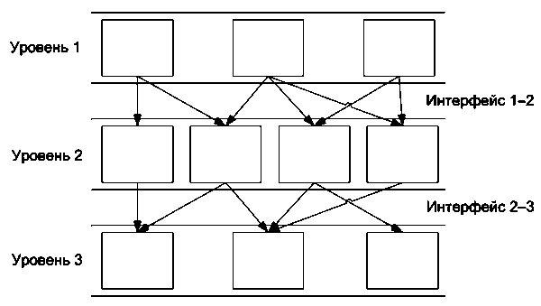

Рис. 12.1. Организация взаимодействия уровней

Коммуникационные протоколы могут быть реализованы как про-граммно, так и аппаратно. Протоколы нижних уровней часто реализуются комбинацией программных и аппаратных средств, а протоколы верхних уровней - как правило, только программными средствами. Протоколы реализуются не только компьютерами, но и другими сетевыми устройствами — концентраторами, мостами, коммутаторами, маршрутизаторами и т.д. В зависимости от типа устройства в нем должны быть встроенные средства, реализующие тот или иной набор протоколов.

# 12.4. Сетевая модель OSI

Международной организацией по стандартизации (ISO) в конце 1970-х гт. был предложен стандарт, охватывающий все аспекты сетевой связи, - это эталонная модель обмена информацией открытой системы OSI (Open System Interconnection). Модель OSI разбивает все процессы взаимодействия и передачи данных по сети на семь уровней: (7-й уровень) прикладной; (6-й уровень) представительный; (5-й уровень) сеансовый; (4-й уровень) транспортный; (3-й уровень) сетевой; (2-й уровень) канальный; (1-й уровень) физический. Для каждого уровня определяются выполняемые ими функции, даются термины и определения основных понятий.

Cтр. 194

Принято начинать описание уровней модели OSI с 7-го уровня, называемого прикладным, на котором пользовательские приложения обращаются к сети. Модель OSI заканчивается 1-м уровнем - физическим, на котором определены стандарты, предъявляемые независимыми производителями к средам передачи данных: тип передающей среды (медный кабель, оптоволокно, радиоэфир и др.), тип модуляции сигнала, сигнальные уровни логических дискретных состояний (нуля и единицы). Любой протокол модели OSI должен взаимодействовать либо с протоколами своего уровня, либо с протоколами на единицу выше и/или ниже своего уровня (рис. 12.2). Взаимодействия с протоколами своего уровня называются горизонтальными, а с уровнями на единицу выше или ниже - вертикальными.

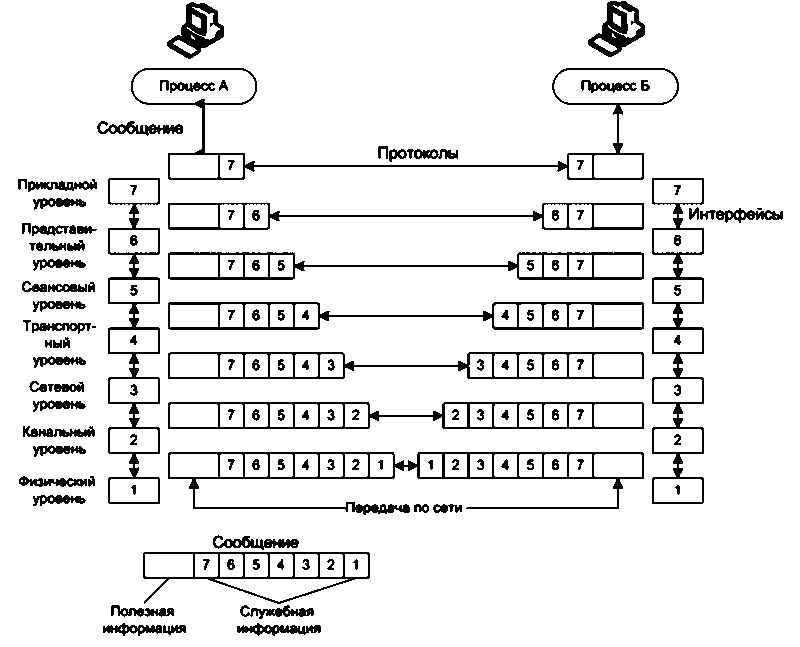

Рис. 12.2. Модель взаимодействия открытых систем

Каждому уровню условно соответствует свой логически неделимый элемент данных, которым на отдельном уровне можно оперировать в рамках модели и используемых протоколов. На физическом уровне мельчайшая единица - бит, на канальном уровне информация объединена в кадры, на сетевом - в пакеты и т.д. Любой фрагмент данных, логически объединенных для передачи (кадр, пакет, дейтаграмма), считается сообщением. Модель OSI описывает только системные средства взаимодействия, не касаясь приложений конечных пользователей. Приложения реализуют свои собственные протоколы взаимодействия, обращаясь к системным средствам. Когла приложение обращается с запросом к прикладному уровню, например к файловому сервису, то программное обеспечение прикладного уровня на основании этого запроса формирует сообщение стандартного формата, в которое помешает служебную информацию (заголовок) и, возможно, передаваемые данные. Поле данных сообщения может быть пустым или содержать какие-либо данные, например те, которые необходимо записать в удаленный файл. Но для того чтобы доставить эту информацию по назначению, предстоит решить еще много задач.

Cтр. 195

Протокол представительного уровня на основании информации, полученной из заголовка прикладного уровня, выполняет требуемые действия и добавляет к сообщению собственную служебную информацию - заголовок представительного уровня, в котором содержатся указания для протокола представительного уровня машины-адресата. Полученное в результате сообщение передается вниз, сеансовому уровню, который, в свою очередь, добавляет свой заголовок, и т. д. Некоторые протоколы помещают служебную информацию не только в начале сообщения в виде заголовка, но и в конце, в виде так называемого «концевика», или, как иногда его называют, «терминатора». Наконец, сообщение достигает нижнего физического уровня, который, собственно, и передает его по линиям связи компьютеру-получателю. К этому моменту сообщение «обрастает» заголовками всех уровней. Когда сообщение по сети поступает на другую машину, оно последовательно перемещается вверх с уровня на уровень. Каждый уровень анализирует, обрабатывает и удаляет заголовок своего уровня, выполняет соответствующие данному уровню функции и передает сообщение вышележащему уровню (рис. 12.3). **Физический уровень** - нижний уровень модели, который определяст метод передачи данных, представленных в двоичном виде, от одного устройства (компьютера) к другому. Физический уровень реализуется аппаратно. Функции физического уровня реализуются на всех устройствах, подключенных к сети. На этом уровне работают концентраторы, повторители сигнала и медиаконвертеры. Со стороны компьютера функции физического уровня выполняются сетевым адаптером или последовательным портом. К физическому уровню относятся физические, электрические и механические интерфейсы между двумя системами.

Cтр. 196

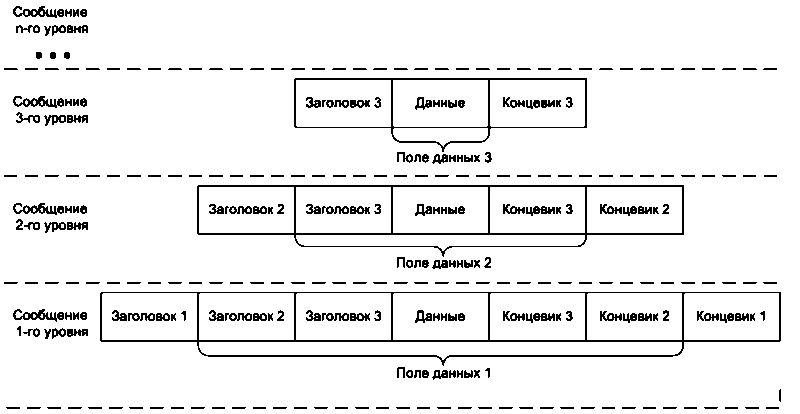

Рис. 12.3. Структура сообщений различных уровней

Канальный уровень предназначен для обеспечения взаимодействия сетей по физическому уровню и контроля над ошибками, которые могут возникнуть. На физическом уровне просто пересылаются биты. При этом не учитывается, что в тех сетях, в которых линии связи разделяются попеременно несколькими парами взаимодействующих компьютеров, физическая среда передачи может быть занята. Основные задачи канального уровня - проверка доступности среды передачи и обнаружение и исправление ошибок. Для этого биты группируются в наборы, называемые кадрами. Канальный уровень обеспечивает корректность передачи каждого кадра, помещая специальную последовательность бит в начало и конец каждого кадра, для его выделения, а также вычисляет контрольную сумму, обрабатывая все биты кадра определенным способом, и добавляет контрольную сумму к кадру. Когда кадр приходит по сети, получатель снова вычисляет контрольную сумму полученных данных и сравнивает результат с контрольной суммой из кадра. Если они совпадают, кадр считается правильным и принимается. Если же контрольные суммы не совпадают, то фиксируется ошибка. Канальный уровень может не только обнаруживать ошибки, но и корректировать их за счет повторной передачи поврежденных кадров.

Cтр. 197

Сетевой уровень модели предназначен для определения пути передачи данных. Отвечает за трансляцию логических адресов и имен в физические, определение кратчайших маршрутов, коммутацию и маршрутизацию, отслеживание неполадок и «заторов» в сети. Сетевой уровень должен также обеспечивать обработку ошибок, мультиплексирование (передачу нескольких потоков с меньшей пропускной способностью по одному каналу), управление потоками данных. На этом уровне вводится понятие «сеть». В данном случае под сетью понимается совокупность компьютеров, соединенных между собой в соответствии с одной из стандартных типовых топологий и использующих для передачи данных один из протоколов канального уровня, определенный для этой топологии.

Cтр. 198

Сообщения сетевого уровня называют пакетами. При организации доставки пакетов на сетевом уровне используется понятие номера сети. Адрес получателя состоит из номера сети и номера узла в этой сети. Все узлы одной сети должны иметь одну и ту же старшую часть адреса, поэтому термину «сеть» на сетевом уровне можно дать и другое, более формальное, определение: сеть - это совокупность узлов, сетевой адрес которых содержит один и тот же номер сети. Примерами протоколов сетевого уровня являются протокол межсетевого взаимодействия IP стека ТСР/Р и протокол межсетевого обмена пакетами РХ стека Novell. Транспортный уровень является своего рода связующим звеном между более высокими уровнями, которые очень зависят от приложений, и нижними уровнями, более привязанными к линиям связи. Можно сказать, что транспортный уровень модели предназначен для обеспечения надежной передачи данных от отправителя к получателю. Задачей транспортного уровня является обеспечение доставки информации с требуемым качеством между любыми узлами сети, а именно: разбивка сообщения сеансового уровня на пакеты, их нумерация; буферизация принимаемых пакетов; упорядочивание прибывающих пакетов; адресация прикладных процессов; управление потоком. Как правило, все протоколы, начиная с транспортного уровня и выше, реализуются программными средствами конечных узлов сети - компонентами их сетевых операционных систем. В качестве примера транспортных протоколов можно привести протоколы ТСР и UDP стека ТСР/Р и протокол SPX стека Novell.

Cтр. 199

**Сеансовый уровень** отвечает за поддержание сеанса связи, позволяя приложениям взаимодействовать между собой длительное время, иными словами, обеспечивает координацию связи между двумя рабочими станциями сети. Уровень организует сеанс обмена данными, управляет созданием и завершением сеанса, синхронизацией задач, определением права на передачу данных и поддержанием сеанса в периоды неактивности приложений. **Уровень представления** обеспечивает то, что информация, передаваемая прикладным уровнем, будет понятна прикладному уровню в другой системе. С его помощью преодолеваются различия, например, между всевозможными кодировками символов и синтаксиса. Уровень представления выполняет преобразование форматов данных в некоторый общий формат представления, а на приеме, соответственно, выполняет обратное преобразование. На этом уровне может выполняться шифрование и дешифрование данных, благодаря которому секретность обмена данными обеспечивается сразу для всех прикладных сервисов.

Прикладной уровень обеспечивает взаимодействие сети и пользо-вателя. Уровень разрешает приложениям пользователя иметь доступ к сетевым службам, таким как обработчик запросов к базам данных, доступ к файлам, пересылке электронной почты. Также отвечает за передачу служебной информации, предоставляет приложениям информацию об ошибках и формирует запросы к уровню представле-ния. Пример: НТТР, РОP3, SMTP. Прикладной уровень — это в действительности просто набор различных протоколов, с помошью которых пользователи сети получают доступ к разделяемым ресурсам, таким как файлы, принтеры или гипертекстовые web-страницы, а также организуют свою совместную работу, например, с помощью протокола электронной почты. Единица данных, которой оперирует прикладной уровень - сообщение. Модель OSI представляет только одну из многих моделей комму-никаций. Эти модели и связанные с ними стеки протоколов могут отличаться количеством уровней, их функциями, форматами сооб-щений, сервисами, предоставляемыми на верхних уровнях и прочими параметрами.

# 12.5. Стек протоколов Интернет

Взаимодействие компьютеров в сетях происходит в соответствии с определенными правилами обмена сообщениями и их форматами, т.е. в соответствии с определенными протоколами. Иерархически организованная совокупность протоколов различных уровней, достаточных для организации взаимодействия узлов в компьютерной сети, называют стеком протоколов. В отличие от сетевой модели, представляющей собой концептуальную схему взаимодействия систем, стек протоколов представляет собой набор конкретных спецификаций, позволяющих реализовать сетевое взаимодействие. Существует довольно много стеков протоколов, широко применяемых в сетях. Примерами популярных стеков протоколов могут служить стек IPX/SPX фирмы Novell, стек ТСР/IP, используемый в сети Internet и во многих сетях на основе операционной системы UNIX, стек OSI международной организаци ти по стандартизаци и др.

Использование в сети того или иного стека коммуникационных протоколов во многом определяет характеристики сети. В небольших сетях может использоваться один стек. В крупных корпоративных сетях, объединяющих различные сети, параллельно используется, как правило, несколько стеков. В основе работы глобальной сети Интернет лежит стек протоколов TCP/IP - набор сетевых протоколов передачи данных, используемых в сетях, включая сеть Интернет. Название ТСР/Р происходит из двух наиважнейших протоколов семейства — Transmission Control Protocol (ТСР) и Internet Protocol (IP), которые были разработаны и описаны первыми в данном стандарте.

Cтр. 200

Основной стек протоколов сети Интернет — стек TCP/IP. Эти протоколы и иначально ориентированы на глобальные сети, в которых качество соелинительных каналов не идеально. Он позволяет создавать глобальн weб-сети, компьютеры в которых соединены друг с другом самыми разными способами от высокоскоростных оптоволоконных кабелей и спутниковых каналов до коммутируемых телефонных тиний. Название стека протоколов TCP/IP состоит из названий двух разных протоколов. Протокол IP (Internet Protocol) представляет собой протокол нижнего (сетевого) уровня и отвечает за передачу пакетов данных в сети. Над протоколом IР работает протокол передачи данных более высокого (транспортного) уровня — TCP (Transmission Control Protocol). Посылая и принимая пакеты через протокол IP, протокол TCP гарантирует доставку всех переданных пакетов данных в правильной последовательности.

Самый верхний уровень в иерархии протоколов Интернет занимают следующие протоколы прикладного уровня: **DNS** - распределенная система доменных имен, которая по запросу, содержащему доменное имя хоста, сообщает IP адрес; **HTTP** - протокол передачи гипертекста в Интернет; **HTTPS** - расширение протокола HТТР, поддерживающее шифрование; **FTP** (File Transfer Protocol - RFC 959) - протокол, предназначенный для передачи файлов в компьютерных сетях; **Telnet** (TELecommunication NETwork - RFC 854)- сетевой протокол для реализации текстового интерфейса по сети; **SSH** (Secure Shell - RFC 4251)-протокол прикладного уровня, позволяющий производить удаленноеуправление операционной системой и передачу файлов. В отличие от Telnet шифрует весь трафик; **POP3** - протокол почтового клиента, который используется для получения сообщений электронной почты с сервера (перенесение на компьютер пользователя); **IMAP** - протокол доступа к электронной почте. При использовании POР3 клиент подключается к серверутолько на промежуток времени, необходимый для загрузки новых сообщений. При использовании IMАР соединение не разрывается, пока пользовательский интерфейс активен, а сообщения загружаются только по требованию клиента. Это позволяетуменьшить время отклика для пользователей, в чьихящиках имеется много сообщений большого объема; **SMTP**- протокол, который используетсядляотправки почты от пользователей к серверам и междусерверами для дальнейшей пересылки к получателю;

Стр. 201

**LDAP** - протокол для доступа к службе каталогов Х.500, является широко используемым стандартом доступа к службам каталогов; **XMPP** (Jabber) - основанный на XML расширяемый протокол длямгновенного обмена сообщениями в почти реалыном времени; **SNMP** - базовый протокол управления сети Internet. **НТТР** (Hyper Text Transfer Protocol) - протокол прикладного уровня для передачи гипертекста. В простейшем виде web-сервер получает по сети НТТР-запрос на определенный ресурс, находит соответствующий файл на локальном жестком диске и отправляет его по сети запросившему компьютеру. Более сложные web-серверы способны динамически формировать ресурсы в ответ на НТТР-запрос.

# 12.6. Адресация узлов в сети

### 12.6.1. Общее представление об адресации в сетях

Для передачи данных в локальных и глобальных сетях устройство-отправитель должно знать адрес устройства-получателя. Поэтому каждое сетевое устройство имеет уникальный адрес (идентифи-катор): физический или аппаратный (МАС-адрес); логический или сетевой (ІР-адрес); символьный. На самом деле адресация производится не для самих устройств, а для их сетевых интерфейсов. Напомним, что интерфейс — это набор средств и правил, позволяющих осуществлять обмен информацией. Один узел сети может иметь несколько сетевых интерфейсов.

При иерархической схеме адресации множество адресов организовано в виде вложенных друг в друга подгрупп, которые, последовательно сужая адресуемую область, в итоге определяют отдельный сетевой интерфейс. Примером иерархически организованных адресов служат обычные почтовые адреса, в которых последовательно уточняется местонахождение адресата: страна, город, улица, дом, квартира. Типичными представителями иерархических числовых адресов являются сетевые IP- и IPX-адреса. В них поддерживается двухуровневая иерархия, адрес делится на старшую часть (номер сети) и младшую (номер узла). Такое разделение позволяет передавать сообщения между сетями только на основании номера сети и затем, после доставки сообщения в нужную сеть, использовать номер узла. Точно так же, как название улицы используется почтальоном только после того, как письмо доставлено в нужный город.

Символьные адреса или имена предназначены для запоминания людьми и поэтому обычно несут смысловую нагрузку. Символьные адреса можно использовать как в небольших, так и в крупных сетях. Для работы в больших сетях символьное имя может иметь иерархическую структуру.

Стр. 202

В современных сетях для адресации узлов, как правило, применяются все три приведенные выше схемы одновременно, так как сетевой интерфейс компьютера может одновременно иметь несколько адресов-имен. В зависимости от того, использование какого вида адресации наиболее удобно, применяется соответствующее множество адресов. Пользователи адресуют компьютеры символьными именами, которые автоматически заменяются в сообщениях, передаваемых по сети, на числовые номера. С помощью этих числовых номеров сообщения передаются из одной сети в другую, а после доставки сообщения в сеть назначения вместо числового номера используется аппаратный адрес компьютера. Сегодня такая схема характерна даже для небольших автономных сетей, где, казалось бы, она явно избыточна — это делается для того, чтобы при включении сети в большую сеть не нужно было менять состав операционной системы.

Конечной целью пересылаемых по сети данных являются не компьютеры или маршрутизаторы, а выполняемые на этих устройствах программы - процессы. Поэтому в адресе назначения наряду с информацией, идентифицирующей порт устройства, должен указы - ваться адрес процесса, которому предназначены посылаемые данные. После того как эти данные достигнут указанного в адресе назначения сетевого интерфейса, программное обеспечение компьютера должно их направить соответствующему процессу. Понятно, что адрес процесса не обязательно должен задавать его однозначно в пределах всей сети, достаточно обеспечить его уникальность в пределах компью-тера. Примером адресов процессов могут служить номера портов ТСР и UDP, используемые в стеке ТСР/Р.

Стр. 203

# 12.6.2. IP-адрес

**Сетевые IP-адреса** — это логические адреса, которые использует при работе протокол IР стека ТСР/IР. ІР-адреса называют сетевыми адресами, поскольку протокол IP относится к сетевому уровню. IР-адрес (Internet Protocol Address) - уникальный сетевой адрес узла в компьютерной сети, построенной по протоколу ІР. В сети Internet требуется глобальная уникальность адреса; в случае работы в локальной сети требуется уникальность адреса в пределах сети. **Локальный IР-адрес** назначается устройству для получения доступа к определенным ресурсам, находящимся в локальной сети. **Внешний IP-адрес** — это IP-адрес, уникальность которого определяется не в локальной сети, а глобально во всей сети Internet. **IP-адреса** - это основной тип адресов, на основании которых сетевой уровень передает сообщения, называемые IP-пакетами. IР-адрес представляет собой двоичное число. В версии протокола IPу4 IР-адрес имеет длину 4 байта или 32 бита, ограничивающие адресное пространство 4 294 967 296 ($2^{32}$) возможными уникальными адресами. IPv4 (Internet Protocol version 4) - четвертая версия IP-протокола, первая широко используемая версия. В шестой версии IP-адрес является 128-битовым. Ру6 (Internet Protocol version 6) — новая версия протокола IP, призванная решить проблемы, с которыми столкнулась предыду-щая версия (IPv4) при ее использовании в интернете, за счет использования длины адреса 128 бит вместо 32.

Удобной формой записи IP-адреса (IPv4) является запись в виде четырех десятичных чисел (от 0 до 255), разделенных точками (например, 192.168.0.1). Это традиционная десятичная форма представления адреса. При этом каждое из четырех десятичных чисел можно записать в двоичной системе счисления, используя восемь бит. В этом случае максимальным будет число, состоящее из восьми двоичных единиц — 11111111, что в пересчете в десятичную систему счисления будет равно 255. Таким образом, каждое из четырех чисел IP-адреса в десятичном представлении не может быть больше 255. IP-адрес состоит из двух частей: адреса сети и номера узла. Адрес сети (идентификатор сети) — это один сетевой сегмент в более крупной объединенной сети (сети сетей), использующей протокол ТСР/IP. IP-адреса всех систем, подключенных к одной сети, имеют один и тот же идентификатор сети. Номер узла (идентификатор, адрес узла) определяет узел ТСР/Р (рабочую станцию, сервер, маршрутизатор или другое ТСР/Р-устройство) в пределах каждой сети. Не нужно забывать, что IP-адрес идентифицирует не отдельный узел в сети, а отдельный сетевой интерфейс. Узел может входить в несколько сетей и в этом случае он должен иметь несколько IР-адресов, по количеству связанных с ним сетей.

К специально зарезервированным IP-адресам относятся... Адрес, состоящий только из двоичных нулей. Обозначает тот же самый узел сети, который сгенерировал пакет, содержащий такой IР-адрес. Адрес, в котором номер сети содержит все нули. Обозначает данти ную сеть, т.е. ту же сеть, в которой находится компьютер, сгенерировавший пакет с этим адресом. Адрес, в котором номер узла содержит все нули. Обозначает узел, принадлежащий той же сети, что и узел, сгенерировавший пакет. Адрес состоит только из двоичных единиц - обозначает, что пакет с таким адресом предназначен всем узлам той же сети, что и источник пакета. При этом такой пакет не выйдет за пределы данной сети, поэтому такая рассылка называется ограниченным широковещанием. Пакет с адресом 127.0.0.1 не передается в сеть, а возвращается верхним уровням стека протоколов, как только что принятый. Адреса, начинающиеся с 127, используются для тестирования программного обеспечения и взаимодействия сетевых процессов в пределах отдельного узла. Поэтому в сети запрещается присваивать компьютерам адреса, начинающиеся с 127.

Стр. 204

Для того чтобы сделать систему адресации более гибкой, используются маски IP-адресов. Маской подсети или маской сети в терминологии сетей ТСР/IР называется битовая маска, определяющая, какая часть IP-адреса узла сети относится к адресу сети, а какая - к адресу самого узла в этой сети. Для этого одна сеть разбивается на несколько подсетей, разделяя адресное пространство на непересекающиеся друг с другом диапазоны. Двоичная запись маски содержит единицы в тех разрядах, которые должны в IP-адресе интерпретироваться как номер сети. Там, где значение бита маски равно единице, адресация узлов запрещена, там, где значение равно нулю - разрешена. При этом «маскировка» происходит от старшего бита к младшему Для стандартных классов сетей маски имеют следующие значения:  
класс А - $11111111.00000000.00000000.00000000$ (255.0.0.0);  
класс В - $11111111.11111111.00000000.00000000$ (255. 255.0.0);  
класс С - $11111111.11111111.11111111.00000000$ (255. 255. 255.0).  
Механизм масок широко распространен в IP-маршрутизации, при этом маски могут использоваться для самых разных целей. С помощью масок администратор может структурировать свою сеть, не требуя от поставщиков услуг дополнительных номеров сетей. Поставщики услуг используют механизм масок для объединения адресного пространства нескольких сетей, вводя так называемые «префиксы». Если сеть является частью Internet, то номера сетей назначаются централизовано. Если сеть работает изолированно, то номера сетей назначаются произвольно.

# 12.6.3. Протокол динамической настройки узла DHCP

Для возможности обмениваться информацией по сети кажлому сетевому интерфейсу узла необходим свой IР-адрес. Назначение IP-а дресов интерфейсам может производиться как вручную, так и автоматически. Ручное назначение адресов обычно производится в процессе настройки конфигурации работы сетевого интерфейса, при этом новые назначаемые адреса не должны повторять уже используемые IP-адреса в сети. Естественно, что даже при небольших размерах сетей такая настройка представляет утомительную процедуру и может вызвать некоторые проблемы. Автоматическое назначение IP-адресов упрощает процесс определения адресов для каждого сетевого интерфейса и освобождает администратора, занимающегося настройкой сетевого взаимодействия, от рутинной работы. Для автоматического назначения IP-адресов используется вспомогательный протокол динамической конфигурации узлов DHCP.

Стр. 205

**DHCP (Dynamic Host Configuration Protocol)** - сетевой протокол, позволяющий компьютерам автоматически получать IP-адрес и другие параметры, необходимые для работы в сети ТСР/Р. Данный протокол работает по модели «клиент-сервер». Для автоматической конфигурации компьютер-клиент на этапе конфигурации сетевого устройства обращается к так называемому серверу DHCP и получает от него нужные параметры. Сетевой администратор может задать диапазон адресов, распределяемых сервером среди компьютеров. Это позволяет избежать ручной настройки компьютеров сети и уменьшает количество ошибок. Протокол DHCP используется в большинстве сетей ТСР/IP. **При автоматическом получении IP-адресов** существуют статический и динамический способы распределения адресов по интерфейсам. При статическом способе сервер DHCP в ответ на запрос рабочей станции посылает ей произвольный Р-адрес, выбранный из диапазона наличных адресов. Диапазон адресов задается при настройке сервера DHCP. Выбранный для рабочей станции адрес дается ей в пользование на неограниченный срок, при этом при последующих обращениях к серверу станция будет получать этот же IР-адрес. При динамическом распределении адрес выдается компьютеру не на постоянное пользование, а на определенный срок. Это дает возможность впоследствии повторно использовать этот IP-адрес для назначения другому компьютеру. Поскольку при таком распределении один и тот же адрес может использоваться несколькими интерфейсами, а также за счет того, что обычно одновременно работают далеко не все зарегистрированные в сети рабочие станции, появляется возможность экономить Р-адреса, выделяя их под конкретные нужды, а не под простаивающие узлы. Можно построить IP-сеть с количеством узлов, превышающем число IP-адресов, имеющихся в распоряжении администратора. **Для определения локального (физического) адреса по IP-адресу** используется протокол разрешения адреса (Address Resolution Protocol, ARP). Для решения обратной задачи, т.е. определение IP-адреса по известному физическому адресу, используется протокол обратного разрешения адресов RARP (Reverse Address Resolution Protocol).

Стр. 206

# 12.6.4. Система доменных имен

Для идентификации компьютеров аппаратное и программное обеспечение в сетях ТСР/Р использует IP-адрес, чтобы программа правильно поняла, к какому хосту ей обратиться. Например, команда http://81.19.70.3 откроет начальную страницу интернет-портала «Рамблер». Но пользователи предпочитают работать с символьными именами компьютеров, и, например, в адресной строке браузера в данном случае удобнее ввести rambler.ru. Человеку гораздо проще запомнить осмысленные имена, чем наборы цифр. В настоящее время существует слишком много IP-адресов, чтобы можно было запомнить хотя бы их малую часть. Поэтому, кроме числовых схем адресации, также применяется символьное представление адресов. Следовательно, в сетях ТСР/Р должны существовать символьные имена хостов и механизм для установления соответствия между символь ными именами и IP-адресами.

**DNS (Domain Name System - система доменных имен)** — это система, позволяющая преобразовывать символьные имена доменов в IP-адреса и наоборот в сетях ТСР/Р. **Домен (domain)** - определенная зона в системе доменных имен (DNS) Интернета, выделенная какой-либо стране, организации или для иных целей. **Доменное имя** может состоять из нескольких частей, отделенных друг от друга точками, например mail.rambler.ru. Каждую из таких частей тоже называют доменом. В домене слева записывается имя узла, входящего в домен, имеющий самый низкий уровень в иерархии, а справа - домен, имеющий самый высокий иерархический уровень. Поэтому крайний справа домен называется доменом верхнего (первого) уровня. Следующий слева домен, отделенный точкой, является дочерним доменом по отношению к домену первого уровня, т.е. входит в него как его составная часть. Этот домен называется доменом второго уровня. Домены, которые являются дочерними для домена второго уровня, называются доменами третьего уровня и т.д. Так, например, в адресе mail.rambler.ru доменом верхнего (первого) уровня является домен «ги», доменом второго уровня — «га», слово «mail» является третьим уровнем — именем хоста (рис. 12.4).

| 3-й уровень | . | 2-й уровень | . | Верхний уровень | <-корень |
| --- | --- | --- | --- | --- | --- |
| mail | . | rembler | . | ru | <- корень |

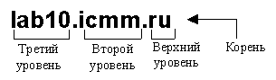

Рис. 12.4. Компоненты имени домена

Иерархия доменных имен аналогична иерархии имен файлов, принятой в файловой системе. Названия доменов первого уровня назначаются централизованно, в соответствии с международным стандартом. Имена доменов первого уровня могут обозначать страны или типы организаций и обычно представляют собой двух- или трехбуквенные аббревиатуры (табл. 12.2).

Стр. 207

Таблица 12.2 Примеры доменов первого уровня

| --- | --- | --- |
| --- | --- | --- |
| Домены Назначение Общие (типы организаций) |  |  |
|  | Com | Коммерческие |
|  | Edu | Образовательные |
|  | Gov | Правительственные |
|  | int | Международные |
|  | mil | Военные |
|  | info | Информационные |
|  | net | Сетевые |
|  | org | Некоммерческие |

| --- | --- | --- |
| --- | --- | --- |
| Региональные (страныи регионы) |  |  |
|  | ru | Российская Федерация |
|  | us | США |
|  | jp | Япония |
|  | de | Германия |
|  | gb | Великобритания |
|  | au | Австралия |
|  | za | Южная Африка |

Если один домен входит в другой домен как его составная часть,то такой домен могут называть поддоменом или субдоменом (sub-domain). **Разделение имени на части позволяет** разделить административную ответственность за назначение уникальных имен между различными людьми или организациями в пределах своего уровня иерархий. Это позволяет решить проблему образования уникальных имен без взаимного согласования организаций. Очевидно, что должна существовать одна организация, отвечающая за назначение имен верхнего уровня иерархий. **DNS** является распределенной базой данных. База данных DNS имеет структуру дерева, называемого доменным пространствам имен (рис. 12.5). Имя домена идентифицирует его положение в этой базе данных по отношению к родительскому домену, при этом точки в имени отделяют части, соответствующие узлам домена. **С помощью сервиса DNS** централизованно осуществляется установление соответствия доменных имен сетевым адресам.

Стр. 208

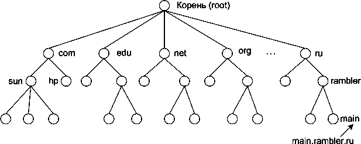

Рис. 12.5. Структура базы данных DNS

**Один IP-адрес может иметь множество имен**, что позволяет поддерживать на одном компьютере множество веб-сайтов (виртуальный хостинг). Обратное тоже справедливо - одному имени может быть сопоставлено множество IP-адресов, что позволяет создавать балан - сировку нагрузки. **Для повышения устойчивости** системы используется множество серверов, содержащих идентичную информацию, а в протоколе есть средства, позволяющие поддерживать синхронность информации, расположенной на разных серверах. **Можно следующим образом определить характеристики DNS**:**Распределенность хранения информации**. Каждый узел сети в обязательном порядке должен хранить только те данные, которые входят в его зону ответственности и (возможно) адреса корневых DNS-серверов. **Иерархическая структура**, в которой все узлы объединены в дерево, и каждый узел может или самостоятельно определять работу нижестоящих узлов, или делегировать (передавать) их другим узлам. **Безопасность и резервирование**. За хранение и обслуживание своих узлов (зон) отвечают (обычно) несколько серверов, разделенных как физически, так и логически, что обеспечивает сохранность данных и продолжение работы даже в случае сбоя одного из узлов.

Стр. 209

**Все программные решения DNS требуют защиты.** Ведь если хакер атакует DNS-сервер, то пользователи будут попадаться в довушку, даже не подозревая об этом. С этим подвидом атак связаны следующие опасности. **В результате DNS-атак** пользователь рискует не попасть на нужную страницу. При вводе адреса сайта атакованный DNS будет перенаправлять запрос на подставные страницы. **В результате перехода** пользователя на ложный IP-адрес хакер может получить доступ к его личной информации. При этом пользователь даже не будет подозревать, что его информация рассекречена. **DDoS-атаки**, приводящие к неработоспособности DNS-сервера. При недоступности DNS-сервера пользователь не сможет попасть на нужную ему страницу, так как его браузер не сможет найти IP-адрес, соответствующий введенному адресу сайта. DDoS-атаки на DNS-сервера могут осуществляться за счет как невысокой производительности DNS-сервера, так и недостаточной ширины канала связи. **Процедура получения доменного имени называется регистрацией домена.** Заключается в создании записей, указывающих на администратора домена, в базе данных DNS. Порядок регистрации и требования зависят от выбранной доменной зоны. Регистрация домена может быть выполнена как организацией-регистратором, так и частным лицом, если это позволяют правила выбранной доменной зоны.

# 12.6.5. URL - универсальный идентификатор ресурсов

URL (Uniform Resource Locator) — это стандартизированный способ записи адреса ресурса в сети Интернет. URL был изобретен Тимом Бернерсом-Ли в 1990 г. в Европейском совете по ядерным исследованиям в Женеве и стал фундаментальной инновацией в Интернете. Изначально URL предназначался для обозначения мест расположения ресурсов (чаще всего файлов) во Всемирной паутине. Сейчас URL применяется для обозначения адресов почти всех ресурсов Интернета и позиционируется как часть более общей системы идентификации ресурсов URI (Uniform Resource Identifier - последовательность символов, идентифицирующая абстрактный или физический ресурс). Стандарт URL регулируется организацией IETF и ее подразделениями.

Стр. 210

Изначально URL был разработан как система для максимально естественного указания на местонахождения ресурсов в сети. Существует следующая традиционная форма записи URL: $$<схема>://<логин >:<пароль>@<хост>:<порт>/<URL-путь>?<параметры>#<якорь>$$ В этой записи: **схема** — схема обращения к ресурсу, в большинстве случаев имеется в виду сетевой протокол; **логин** — имя пользователя, используемое для доступа к ресурсу; **пароль** - пароль указанного пользователя; **хост** - полностью прописанное доменное имя хоста в системе DNS или IP-адрес хоста в форме четырех групп десятичных чисел, разделенных точками; числа - целые в интервале от 0 до 255;

**порт** - порт хоста для подключения; **URL-путь** - уточняющая информация о месте нахождения ресурса, зависит от протокола; **параметры** - строка запроса с передаваемыми на сервер параметрами. Разделитель параметров - знак в; **якорь** - идентификатор якоря», ссылающегося на некоторую часть (раздел) открываемого документа. Страница в зависимости от указанного якоря может в браузере выглядеть по-разному. Общепринятые схемы (протоколы) URL включают;

Общепринятые схемы (протоколы) URL включают: **fip** — протокол передачи файлов FTP; **http** - протокол передачи гипертекста НТТР; **rtmp** — Real Time Messaging Protocol проприетарный протокол потоковой передачи данных, в основном используется для передачи потокового видео и аудиопотоков с веб-камер через Интернет; **rtsp** - потоковый протокол реального времени; **https** — специальная реализация протокола НТТР, использующая шифрование (как правило, SSL или TLS); **gopher** — протокол Gopher; **mailto** - адрес электронной почты; **news** — новости Usenet; **nntp** — новости Usenet через протокол NNTP; **telnet** — ссылка на интерактивную сессию Telnet; **file** — имя локального файла; **data** — непосредственные данные (Data: URL); **tel** — звонок по указаному телефону.

Приведем пример простого адреса URL: http://www.infra-m.ru/live/kurs.asp  
В данном случае путь состоит из доменного адреса машины, на которой установлен сервер НТТР, и пути от корня дерева сервера к файлу kurs.asp. В качестве адреса машины допустимо использование и IР-адреса.

Стр. 211

# 12.7. Протокол НТТР

Протокол НТТР определяет взаимодействие компьютеров на прикладном уровне. НТТР предназначен для передачи сообщений, являющихся блоками гипертекста и используется в службе глобального соединения. Транспортным протоколом для НТТР является протокол ТСР, причем сервер НТТР (сервер Web) находится в состоянии ожидания соединения со стороны клиента стандартно по порту 80 ТСР, а клиент НТТР (Web-браузер) является инициатором соединения. **Одной из важнейших функций сервера** Web является предоставление доступа к части локальной файловой системы. Для этого в настройках сервера указывается некоторая директория, которая является корневой для данного сервера web. Чтобы опубликовать документ, т.е. сделать его доступным пользователям, «посещающим» данный сервер (осуществляющим с ним соединение по протоколу НТТР), нужно скопировать этот документ в корневую директорию web-сервера или в одну из ее поддиректорий. При соединении по протоколу НТТР на сервере создается процесс с правами пользователя, как правило, не существующего реально, а специально созданного для просмотра ресурсов сервера. Настраивая права и разрешения данного пользователя, можно управлять доступом к ресурсам web-сервера.

Взаимодействие между клиентом и web-сервером осуществляется путем обмена сообщениями. Сообщения НТТР делятся на запросы клиента серверу и ответы сервера клиенту. Основу НТТР составляет технология «клиент-сервер». Центральным объектом в НТТР является ресурс, на который указывает URL в запросе клиента. Обычно такие ресурсы представлены хранящимися на сервере файлами. Особенность протокола НТТР заключается в возможности указать в запросе и ответе способ представления одного и того же ресурса по различным параметрам: формату, кодировке, языку и т.д. Именно благодаря возможности указания способа кодирования сообщения клиент и сервер могут обмениваться двоичными данными, хотя изначально данный протокол предназначен для передачи символьной информации. На первый взгляд это может показаться излишней тратой ресурсов. Действительно, данные в символьном виде занимают больше памяти, сообщения создают дополнительную нагрузку на каналы связи, однако подобный формат имеет много преимуществ. Сообщения, передаваемые по сети, удобочитаемы, и, проанализировав полученные данные, системный администратор может легко найти ошибку и устранить ее. При необходимости роль одного из взаимодействующих приложений может выполнять человек, вручную вводя сообщения в требуемом формате.

Стр. 212

В отличие от многих других протоколов НТТР не хранит информацию о предыдущих запросах клиентов и ответах сервера. Компоненты, использующие НТТР, могут самостоятельно осуществлять сохранение информации о состоянии, связанной с последними запросами и ответами. Например, клиентское web-приложение, посылающее запросы, может отслеживать задержки ответов, а web-сервер может хранить IР-адреса и заголовки запросов последних клиентов. Все программное обеспечение для работы с протоколом НТТР разделяется на три основные категории: **Серверы** - поставщики услуг хранения и обработки информации (обработка запросов); **Клиенты** - конечные потребители услуг сервера (отправка запросов); **Прокси-серверы** для поддержки работы транспортных служб.

**Основными клиентами** являются браузеры, например: Internet Explorer, Opera, Mozilla Firefox, Netscape Navigator и др. Наиболее популярные реализации web-серверов - Internet Information Services (IIS), Apache и т.д. **Apache** — свободный веб-сервер. Арасе является кросс-платформенным ПО, поддерживая операционные системы GNU/Linux, BSD, Mac OS, Microsoft Windows, Novell NetWare, BeOS. Apache используется в системе в качестве одного из веб-серверов, с помощью которых удаленные пользователи могут работать с информационной базой через Интернет. **Internet Information Services (IIS)** - набор серверов для нескольких служб Интернета от компании Майкрософт. IIS распространяется с операционными системами семейства Windows NT. IIS используется в системе в качестве одного из веб-серверов, с помощью которых удаленные пользователи могут работать с информационной базой через Интернет.

Наиболее известные реализации прокси-серверов: Squid, UserGate, Multiproxy, Naviscope. «Классическая» схема НТТР-сеанса выглядит следующим образом: установление ТСР-соединения; запрос клиента; ответ сервера; разрыв ТСР соединения. Таким образом, клиент посылает серверу запрос, получает от него ответ, после чего взаимодействие прекращается. Обычно запрос клиента представляет собой требование передать HTML-документ или какой-нибудь другой ресурс, а ответ сервера содержит код этого ресурса.

Стр. 213

# 12.8. Обеспечение безопасности передачи данных. Протокол HTTPS.

**Протокол НТТР предназначен для** передачи символьных данных в открытом незашифрованном виде. Следовательно, лица, имеющие доступ к каналу передачи данных между клиентом и сервером, могут без труда просматривать весь трафик и использовать его для совершения несанкционированных действий. В связи с этим предложен ряд расширений базового протокола, направленных на повышение защищенности интернет-трафика от несанкционированного доступа. **Самым простейшим является** расширение HTTPS, при котором данные, передаваемые по протоколу НТТР, «упаковываются» в криптографический протокол SSL или TLS, тем самым обеспечивая защиту этих данных. В отличие от НТТР для HTTPS по умолчанию используется ТСР-порт 443. Чтобы подготовить web-сервер для обработки HTTPS соединений, администратор должен получить и уста новить в систему сертификат для этого web-сервера.

SSL (Secure Sockets Layer - уровень защищенных сокетов) - криптографический протокол, обеспечивающий безопасную передачу данных по сети Интернет. При его использовании создается защищенное соединение между клиентом и сервером. SSL изначально разработан компанией Netscape Communications. Впоследствии на основании протокола SSL 3.0 был разработан и принят стандарт RFC, получивший название TLS. TLS (Transport Layer Security - безопасность транспортного уровня) — этот протокол использует шифрование с открытым ключом для подтверждения подлинности отправителя и получателя. TLS поддерживает надежность передачи данных за счет использования корректирующих кодов и безопасных хэш-функций. На нижнем уровне многоуровневого транспортного протокола (например, ТСР) он является протоколом записи и используется для инкапсуляции различных протоколов (РОP3, ІМАР, SMTP или НТТР). Для каждого инкапсулированного протокола TLS обеспечивает условия, при которых сервер и клиент могут подтверждать друг другу свою подлинность, выполнять алгоритмы шифрования и производить обмен криптографическими ключами, прежде чем протокол прикладной программы начнет передавать и получать данные.

Стр. 214

**Для доступа к web-страницам**, защищенным протоколом SSL, в URL вместо схемы http, как правило, подставляется схема https, указывающая на то, что будет использоваться SSL-соединение. Стандартный ТСР-порт для соединения по протоколу https - 443. Для работы SSL требуется, чтобы на сервере имелся SSL-сертификат. **Как известно**, существуют классические криптостойкие алгоритмы шифрования, которые шифруют данные на основе существующего ключа. Для шифрования и расшифровки данных используется один и тот же ключ. Ключ - это обычная последовательность бит определенной длины. Чем больше длина ключа, тем сложнее взломать алгоритм шифрования. Если передавать этот ключ в открытом виде, то смысл шифрования пропалает, поэтому используют дополнительно другой вид шифрования - асимметричный. В этом случае существует пара ключей - открытый и закрытый. С помощью открытого ключа можно только зашифровать информацию, а с помощью закрытого - расшифровать. Обычно при таком подходе закрытый ключ хранится в секрете, а открытый ключ - общедоступным. Однако асимметричный алгоритм работает мелленнее, чем симметричный, поэтому его используют для первоначального обмена симметричными ключами.

Одна из наследственных **проблем протокола НТТР** заключается в непостоянстве соединения между клиентом и сервером, т.е. для каждого документа (или файла) при передаче по протоколу НТТР посылается отдельный запрос. Иначе говоря, транзакция завершается после того, как браузер сделал запрос, а сервер выдал соответствующий ответ. Сразу после этого сервер «забывает» о пользователе и каждый следующий запрос того же пользователя считает новым пользователем. Включение в протокол НТТР cookie дало частичное решение этой проблемы. **Cookie** — это небольшая порция текстовой информации, которую сервер передает браузеру. Браузер хранит эту информацию и передает ее серверу с каждым запросом как часть НТТР заголовка. Одни значения сооіе могут храниться только в течение одной сессии, они удаляются после закрытия браузера. Другие, установленные на некоторый период времени, записываются в файл. Используя **Cookie**, можно змулировать сессию по протоколу НТТР: на первом запросе выдается соответствующее значение сооіе, а при каждом последующем запросе это значение читается из переменной окружения (HTTP_COOKIE) и соответствующим образом обрабатывается.

**Простой пример:** есть форма, где пользователю предлагается указать свое имя, из нее вызывается небольшая программа (скрипт/сценарий), прописывающий значение сооіе в браузер пользователя. При каждом последующем заходе на основе анализа значения cookie из браузера пользователя на странице появляется либо именное приветствие (если есть установленное значение cookie), либо первоначальная форма с запросом имени пользователя (если значение cookie не установлено). **Сами по себе cookies не могут делать ничего**, это только лишь некоторая текстовая информация. Однако сервер может считывать содержащуюся в cookies информацию и на основании ее анализа совершать те или иные действия. Например, в случае авторизованного доступа к чему-либо через WWW в cookies сохраняется login и password в течение сессии, что позволяет пользователю не вводить их снова при запросах каждого документа, защищенного паролем. На использовании cookies также часто строят функции оформления заказов в онлайновых магазинах. Еще одна распространенная область использования cookies - при настройке индивидуального профиля каждого зарегистрированного пользователя.

Стр. 215

# 12.9. Сетевые службы и сетевые сервисы

С функциональной точки зрения вычислительная сеть рассматривается как совокупность сетевых служб, предоставляющих пользователю определенный набор услуг, например доступ к аппаратным или программным средствам либо к информационным ресурсам другого узла сети. **Служба** - это сетевой компонент, реализующий некоторый набор услуг. Сетевой сервис - это интерфейс между потребителем услуг (например, пользователем) и поставщиком услуг (службой). Серверная часть может предоставлять сетевые услуги клиентской части по инициативе этой клиентской части. Серверное программное обеспечение — программный компонент вычислительной системы, выполняющий сервисные функции по запросу клиента, предоставляя ему доступ к определенным ресурсам или услугам.

**К сетевыми услугам относятся** хранение данных, поиск информации, почтовые услуги (электронная почта), передача данных между узлами в сети, организация сеансов взаимодействия между прикладными процессами. **Потребителями сетевых услуг являются** пользователи, программы, операционные системы, функциональные блоки, вычислительные процессы и т.д. Поставщик сетевых услуг — это сетевая служба, реализующая услуги или набор услуг. Так, поставщиками услуг являются средства обеспечения общего доступа и использования локальных и удаленных ресурсов и услуг. Кроме доступа к аппаратным, программным средствам и данным, сетевые службы решают и другие, более специфические залачи, например задачи, связанные с распределенной обработкой данных. К таким задачам относится обеспечение синхронизации нескольких копий данных, размещение на разных узлах (служба репликации). или организация выполнения одной задачи параллельно на нескольких машинах сети (служба вызова удаленных процедур). **Серверная часть** сетевой службы производит обработку и выполнение полученных от клиентской части службы запросов, касаюшихся использования или получения доступа к сетевым ресурсам. с которыми данная сетевая служба связана. Как правило, сетевая операционная система предоставляет услуги основных сетевых служо, обеспечивающих стандартные функции вычислительной сети. Дополнительные услуги могут предоставляться сетевыми службами, реализуемыми системными сетевыми приложениями или утилитами, работающими под управлением операционной системы.

Стр. 216

Для использования сервисов, предоставляемых сетевой службой, на машине пользователя должна быть установлена клиентская часть данной службы. Для одной службы может существовать множество клиентов, различающихся по набору функций и удобству интерфейса. Главное, чтобы клиент обращался к серверу (серверной части службы) с запросами в соответствии с правилами, понятными серверу. В связи с этим при разработке сетевых служб исключительно важной залачей является выбор протокола (правил) сетевых взаимодействий клиентской и серверной частей, распределение функций межлу ними, согласование протоколов различных вычислительных сетей. Проблема согласования протоколов особенно важна в связи с тем, что узлы вычислительной сети во многих случаях имеют разные аппаратные платформы и соответственно разные сетевые программные средства, которые вымогают множество протоколов сетевого взаимодействия. **По степени интеграции сетевой службы** в операционную систему различают такие виды программной реализации сетевой службы, как: **высокая степень** интеграции - сетевая служба является частью операционной системы; **средняя степень** интеграции — сетевая служба представляет собой надстройку над операционной системой; **низкая степень** интеграции - сетевая служба является самостоя - тельным программным продуктом. **Один из главных показателей качества сетевой службы** - ее удобство, в первую очередь удобство работ с ней для пользователя. Именно поэтому сетевые службы обеспечиваются специальным интерфейсом, в большинстве случаев интуитивно понятным пользователю.

**Набор предоставляемых пользователю сетевых услуг** зависит от имеющихся аппаратных и программных средств сети. В последнее время, особенно с развитием Интернет, число сетевых служб значительно возросло. Пользователи имеют дело именно с сетевыми службами, при этом работа базовых сетевых программных и аппаратных средств для пользователя становится все менее заметной. **Формат запросов клиента** и ответов сервера определяется протоколом. Спецификации открытых протоколов описываются открытыми стандартами, например протоколы Интернета определяются в документах RFC. **В зависимости от выполняемых задач** одни серверы, при отсутствии запросов на обслуживание, могут простаивать в ожидании. Другие могут выполнять какую-то работу, например сбор информации. У таких серверов работа с клиентами может быть второстепенной задачей. **Важно понимать**, что сервер, предоставляющий какой-либо сервис, например прокси-сервер, всегда является программой (или программным модулем), выполняющейся на каком-то аппаратном обеспечении. Без этой программы аппаратное обеспечение не может ничего предоставлять.

Стр. 217

# 12.10. Облачные сервисы

**Облачные вычисления (cloud computing)** - модель обеспечения повсеместного и удобного сетевого доступа по требованию к общим вычислительным ресурсам (сетям передачи данных, серверам, устройствам хранения данных, приложениям и сервисам), которые могут быть оперативно предоставлены и освобождены с минимальными эксплуатационными затратами. **Наименование «облачные» компьютерные системы** изначально получили из-за упрощенного обозначения компьютеров, находя щихся в составе одной сети в виде облака с изображенными внутри него данными. В этом случае каждый компьютер не рассматривается в качестве самостоятельной единицы, а является частью целого. Под целым же подразумевается та область системы, которая непосредственно задействована при работе с пользователем. Таким образом, все сетевые ресурсы, доступные нам через серверы, по сути, можно назвать «облаком». **Наибольшую популярность «облачные» системы получили** благодаря развитию сервисов, позволяющих осуществлять хранение файлов не в памяти компьютера, а в специальном интернет-хранилище. Подобные функциональные возможности обеспечили пользователям невиданную ранее свободу выбора, так как все хранимые в облаке файлы доступны владельцу в любое время и с любого устройства, подключенного к сети Интернет. Так же облачные сервисы можно использовать в качестве резервных хранилищ личных данных. В случае выхода из строя жесткого диска компьютера всегда можно вернуть всю необходимую информацию, предварительно сохраненную в облаках. **Не менее эффективно облачные хранилища можно использовать** и для синхронизации данных между различными компьютерными устройствами. Например, можно внести изменения в файл на рабочем компьютере и быть уверенным, что все сделанные исправления будут внесены во все его копии, хранящиеся на других устройствах, которые синхронизированы с облачным сервисом. **К наиболее популярным облачным файловым хранилищам относятся**: Google Диск, Яндекс.Диск, Microsoft SkyDrive, Dropbox, iCloud и другие. Практически все они после регистрации предоставляют пользователям некоторое количество бесплатного места для хранения файлов (как правило, от 5 Гб до 10 Гб). Если же этого покажется мало, то за дополнительную плату можно организовать хранилище емкостью от 20 Гб до нескольких десятков терабайт.

Стр. 218

Одним из представителей облачных программ является офисный пакет Microsoft Office 365. Включая в себя все самые популярные офисные приложения, такие как Word, Excel, PowerPoint и т.д., он обеспечивает доступ к вашим документам отовсюду, где есть доступ к интернету, и позволяет работать над ними с самых разных устройств, даже на которых не установлен пакет Office. Помимо этого пользозатели получают возможность совместно работать над документами, обмениваться мгновенными сообщениями и не беспокоиться о зашишенности собственных данных. **Все доступные** современному пользователю **облачные системы** можно поделить на четыре категории: **во первых**, модель SaaS (Software-as-a-Service) - программное обеспечение как услуга или программное обеспечение по требованию; **во вторых**, модель PaaS (Platform-as-a-Service) - платформа как услуга; **в третьих**, модель DaaS (Desktop as a Service) — рабочий стол как услуга; **в четвертых**, модель laaS (laaS or Infrastructure-as-a-Service) - инфраструктура как услуга.

**SaaS** - бизнес-модель продажи и использования программного обеспечения, при которой поставщик разрабатывает веб приложение и самостоятельно управляет им, предоставляя заказчику доступ к программному обеспечению через Интернет. Основное преимущество модели SaaS для потребителя услуги состоит в отсутствии затрат, связанных с установкой, обновлением и поддержкой работоспособности оборудования и работающего на нем программного обеспечения. В модели **SaaS приложение** приспособлено для удаленного использования, и одним приложением пользуются несколько клиентов. **PaaS** - модель предоставления облачных вычислений, при которой пользователь получает доступ к использованию информационно-технологических платформ: операционных систем, систем управления базами данных, связующему программному обеспечению, средствам разработки и тестирования, размещенным у облачного провайдера. В этой модели вся информационно-технологическая инфраструктура, включая вычислительные сети, серверы, системы хранения, целиком управляется провайдером, провайдером же определяется набор доступных для потребителей видов платформ и набор управляемых параметров платформ, а потребителю предоставляется возможность использовать платформы, создавать их виртуальные экземпляры, устанавливать, разрабатывать, тестировать, эксплуатировать на них прикладное программное обеспечение, при этом динамически изменяя количество потребляемых вычислительных ресурсов.

Стр. 219

**Модель DaaS** является логическим продолжением модели SaaS. Услуга DaaS дает клиентам полностью готовое к работе стандартизированное виртуальное рабочее место, которое каждый пользователь имест возможность дополнительно настраивать под свои залачи. Таким образом, пользователь получает доступ не к отдельной программе, а к необходимому для полноценной работы программному комплексу. Физически доступ к рабочему месту пользователь может получить через локальную сеть или Интернет. Устройство доступа используется в качестве тонкого клиента и требования к нему минимальны. **На сегодняшний день** технология DaaS считается перспективным облачным направлением и позволяет разворачивать полноценное рабочее место, готовое круглосуточно к работе со всем необходимым программным обеспечением. При этом все приложения хранятся в специальном дата-центре, что позволяет эффективно использовать этот инструмент даже на маломощных компьютерах, ноутбуках, планшетах и смартфонах.

**Модель обслуживания LaaS** позволяет пользователям самостоятельно управлять облачными ресурсами, предоставляя в аренду как аппаратные средства (серверы, клиентские системы, сетевое оборудование и т.д.), так и операционные системы и необходимое прикладное программное обеспечение. В большинстве своем данная технология используется корпоративными клиентами для создания собственного сервиса облачных вычислений. Потребитель может контролировать операционные системы, виртуальные системы хранения данных и установленные приложения, а также ограниченный контроль набора доступных сервисов. Контроль и управление основной физической и виртуальной инфраструктурой облака, в том числе сети, серверов, типов используемых операционных систем, систем хранения осуществляются облачным провайдером.

Стр. 220

Использование «облачных» сервисов имеет свои положительные и отрицательные стороны. Преимуществами можно назвать: **во первых**, возможность входа в систему и доступа к личным данным с любого устройства, подключенного к сети Интернет; **во вторых**, возможность организации резервного хранения данных; **в третьих**, синхронизация данных на всех пользовательских устройствах; **в четвертых**, невысокие требования к исходному программному и техничео скому обеспечению устройств для работы в облачных сервисах; **однако в пятых**, возможность использования сложных программных комплексов на маломощном оборудовании. **В качестве недостатков можно указать**: **во первых**, невозможность контролировать доступ к хранящимся данным; **во вторых**, потребность устанавливать с сервисом Интернет-соединение каждый раз при необходимости получения доступа к файлам или приложениям; **в третьих**, необходимость пользоваться услугами и предложениями определенного разработчика, которому принадлежит сервис.

# 12.11. Службы сетевой безопасности

Технологии Интернет изменяют отношение к обеспечению сетевой безопасности. Существует широкий спектр технологий обеспечения информационной безопасности, которые управляют доступом к информационным ресурсам, контролируют целостность и подлинность информации и сетевых соединений, проходящих как через Интернет, так и через внутренние сети организации и ее партнеров. Из наиболее часто упоминаемых внешних средств защиты информации, соответствующих постоянно возрастающим требованиям, следует отметить следующие две системы: брандмауэры и прокси-серверы. **Прокси сервер** (ргоху — «представитель, уполномоченный») — служба или комплекс программ в компьютерных сетях, позволяющая клиентам выполнять косвенные запросы к другим сетевым службам. **Клиент подключается к прокси-серверу** и запрашивает какой-либо ресурс (например, e-mail), расположенный на другом сервере, после чего прокси-сервер либо подключается к указанному серверу и получает ресурс у него, либо возвращает ресурс из собственного кэша. Прокси сервер позволяет защищать компьютер клиента от некоторых сетевых атак и помогает сохранять анонимность клиента.

Цели применения прокси-серверов можно сформулировать следующим образом. **Кэширование данных** — если часто происходят обращения к одним и тем же внешним ресурсам, то можно сохранять их копию на прокси-сервере и выдавать по запросу, снижая тем самым нагрузку на канал выхода во внешнюю сеть и увеличивая скорость получения клиентом информации; **Сжатие данных** — прокси-сервер загружает информацию из Интернета и передает ее конечному пользователю в сжатом виде. Такие прокси-серверы позволяют экономить внешний сетевой трафик; **Зашита локальной сети** от внешнего доступа: например, можно настроить прокси-сервер так, что локальные компьютеры будут обращаться к внешним ресурсам только через него, а внешние компьютеры не смогут обращаться к локальным вообще (они «видят» только прокси-сервер); **Ограничение доступа** из локальной сети к внешней (например. можно запретить доступ к определенным веб-сайтам, ограничить использование интернета каким-то локальным пользователям, устанавливать ограничения на трафик, фильтровать опасный контент); **Анонимность доступа** к различным ресурсам. Прокси-сервер может скрывать сведения об источнике запроса или пользователе. Существуют также искажающие прокси-серверы, которые передают целевому серверу ложную информацию об истинном поль зователе: Обход ограничений доступа. Прокси-серверы популярны среди пользователей стран, где доступ к некоторым ресурсам ограничен законодательно.

Стр. 221

**Прокси-сервер**, к которому может получить доступ любой пользователь сети Интернет, называется открытым. **Функционирование прокси-сервера кратко** можно описать следующим образом. Все сетевые соединения конкретной программы или операционной системы по некоторому протоколу совершаются не на ІР-адрес сервера (ресурса), а на IP-адрес (и другой порт) прокси-сервера. Клиентский компьютер открывает сетевое соединение с прокси-сервером (на нужном порту) и совершает обычный запрос, как если бы он обращался непосредственно к ресурсу. Распознав данные запроса, проверив его корректность и разрешения для клиентского компьютера, прокси-сервер, не разрывая соединения, сам открывает новое сетевое соединение непосредственно с ресурсом и делает тот же самый запрос. Получив данные (или сообщение об ошибке), прокси-сервер передает их клиентскому компьютеру. Прокси-сервер является полнофункциональным сервером и клиентом для каждого поддерживаемого протокола и имеет возможность применения заданных администратором политик доступа на каждом этапе работы протокола.

**В настоящее время**, несмотря на возрастание роли других сетевых протоколов, переход к тарификации услуг сети Интернет по скорости доступа, а также появление дешевых аппаратных маршрутизаторов с функцией NAT, прокси-серверы продолжают широко использоваться на предприятиях. **Брандмауэр представляет собой** программный или аппаратный комплекс, который проверяет данные, входящие через Интернет или сеть, и в зависимости от параметров брандмауэра блокирует или разрешает их передачу на компьютер. **Брандмауэр поможет предотвратить** проникновение хакеров или вредоносного программного обеспечения в компьютер через сеть или Интернет, а также помогает предотвратить отправку вредоносных программ на другие компьютеры. **Брандмауэр позволяет** разделить сеть на две (или более) части и реализовать набор правил, определяющих условия прохождения пакетов из одной части в другую. Как правило, эта граница проводится между локальной сетью предприятия и Интернет, хотя ее можно провести и внутри локальной сети предприятия. Брандмауэр таким образом пропускает через себя весь трафик. Для каждого проходящего пакета брандмауэр принимает решение пропускать его или отбросить. Для того чтобы брандмауэр мог принимать эти решения, ему необходимо определить набор правил.

Стр. 222

Ряд брандмауэров позволяет организовывать виртуальные корпоративные сети, т.е. объединить несколько локальных сетей, включенных в Internet в одну виртуальную сеть. Виртуальные сети позволяют организовать прозрачное для пользователей соединение локальных сетей, сохраняя секретность и целостность передаваемой информации с помощью шифрования. При этом при передаче по Internet шифруются не только данные пользователя, но и сетевая информация - сетевые адреса, номера портов и т.д.

Стр. 223

# Глава 13. ЯЗЫКИ РАЗМЕТКИ

## 13.1. Язык гипертекстовой разметки HTML

Язык разметки документов представляет собой набор специальных инструкций (тегов), предназначенных для формирования в документах какой-либо структуры и определения отношений между различными элементами этой структуры. Теги языка в таких документах выделяются относительно основного содержимого документа и служат в качестве инструкций для программы, производящей показ содержимого документа на компьютере пользователя. Текстовый документ, написанный с использованием языка разметки, содержит не только сам текст, но и дополнительную информацию о различных его участках, например указание на заголовки, выделения, списки и т.д. В более сложных случаях язык разметки позволяет вставлять в документ интерактивные элементы и содержание других документов. B World Wide Web для разметки текста используется язык HTML (HyperText Markup Language). HTML определяет, как и какие элементы должны располагаться на веб-странице. Информация на сайте, способ ее представления и оформления зависят исключительно от разработчика и тех целей, которые он перед собой ставит. Формально HTML - это приложение SGML (Standard Generalized Markup Language, стандартного обобщенного метаязыка разметки).

HTML является описательным языком разметки документов и предоставляет пользователям и разработчикам средства для того, чтобы: **во первых**, публиковать online-документы с текстом, таблицами, списками, оглавлениями, изображениями и т.д.; **во вторых**, запрашивать online-информацию, переходя по гиперссылкам, нажимая кнопки и т.п.; **в третьих**, создавать формы для взаимодействия с удаленным сервисом, для поиска информации, создания архивов, продажи товаров и т.д.; **в четвертых**, включать в документы таблицы данных, видео- и аудиоинформацию и др. **Документ HTML** представляет собой не что иное, как обычный текстовый файл с добавленными в него управляющими HTML-кодами (тегами). Тег — это элемент языка разметки гипертекста. Теговая модель описывает документ как совокупность контейнеров, каждый из которых начинается и заканчивается тегами. Текст, содержащийся между начальным и конечным тегом, отображается и размешается в соответствии со свойствами, указанными в начальном теге. В HTML. разрешено использовать горизонтальную табуляцию, перевод каретки и перевод строки. Это облегчает работу с документами, а также взаимодействие с различными операционными системами.

Стр. 224

Теги HTML-документов в большинстве своем просты и понятны, так как образованы с помощью общеупотребительных слов английского языка, понятных сокращений и обозначений. HTML-тег состоит из имени, за которым может следовать необязательный список атрибутов тега. Текст тега заключается в угловые скобки. Атрибуты (параметры) тега следуют за именем и отделяются друг от друга одним или несколькими знаками табуляции, пробелами или символами возврата к началу строки. Порядок записи атрибутов в теге значения не имеет. Значение атрибута, если таковое имеется, следует за знаком равенства, стоящим после имени атрибута. Регистр символов в именах тегов и атрибутов не учитывается, чего нельзя сказать о значениях атрибутов. Наборы допустимых параметров индивидуальны для каждого тега. Приведем пример записи тега с параметрами:

```
<table border align="left">
```

Здесь для тега `<table>` заданы два параметра. Первый параметр $border$ указан без значения. Второй параметр `аlign` имеет значение «left».

Чаше всего элементы разметки HTML (HTML-контейнеры) состоят из начального и конечного тега, между которыми размещаются текст и другие элементы документа. Имя конечного тега идентично имени начального, но перед именем конечного тега ставится косая черта (например, для `<TITLE>` закрывающей парой будет `</TITLE>`). Конечные теги никогда не содержат атрибутов. По своему значению теги близки к понятию операторных скобок `«begin... end»` в языках программирования, которые задают области действия имен локальных переменных и т.п. Теги определяют область действия правил интерпретации текстовых документов. Смысл HTML-элемента состоит в применении форматирования к содержимому между начальным и конечным тегами. Применяемое форматирование зависит от имени элемента.

Не все HTML-элементы имеют открывающий и закрывающий тег, т.е. не все теги являются контейнерными, а могут кодироваться единственным тегом, например тег $link$ устанавливает связь с внешним документом:

```
<head>
    <link атрибуты»
</head>
```

Стр. 225

Все теги интерпретируются браузерами по общим правилам. Браузеры не реагируют на неверную запись тегов в НТМЕ. и в огличие от языков программирования не выдают соответствующих сообщений. Неправильно записанный тег или его параметр просто игнорируется. Это общее правило для всех браузеров, под действие которого попадают неверные теги и теги, не распознаваемые данной версией браузера. **Тег-контейнер** $<title>$ является единственным обязательным тегом заголовка и служит для того, чтобы дать документу название. Оно обычно показывается в заголовке окна браузера. Все, что находится между метками $<title>$ и $</title >$, интерпретируется браузером как название документа. **Ниже приводится** пример кода простого документа HTML версии 4.01, содержащего основные теги:

```
<! DOCTYPE HTML PUBLIC "-//W3C//DTD HTML 4.01 Transitional//RU">
<html>
    <head>
        <title>Это заголовок страницы</title>
        <meta http-equiv="Content-Type" content="text/html;charset=windows-1251">
        <link href="css/styles.css" rel="stylesheet" type="text/css">
    </head>
    <body>
        <h1>Заголовок 1-го уровня</h1>
        <! -- Это комментарий -->
        <р>Это моя первая страница HTML
            <b>Этот текст выводится жирным шрифтом</b>
        </p>
    </body>
</html>
```

Стр. 226

Текст между тегами `<head>` и `</head>` является информацией заголовка документа. Внутри контейнера ‹head› находятся метатеги, которые используются для хранения информации, предназначенной для браузеров и поисковых систем. Например, механизмы поисковых систем обращаются к метатегам для получения описания сайта, ключевых слов и других данных. Содержимое тега `<head>` не отображается напрямую на web-странице, за исключением тега `<title>`. Текст «Это заголовок страницы» между тегами `<title>` и `</title>` является заголовком документа. Элемент `<title>` не является частью документа и не показывается напрямую на web-странице. В операционной системе Windows текст заголовка отображается в левом верхнем углу окна браузера. Допускается использовать только один тer `<title>` на документ и размещать его в контейнере `<head>`. `<meta http-equiv="Content-Type" content-"text/html: charset=windows-1251">` — укзаывает на то, что документ содержит HTML-текст в кодировке windows 1251 - это кириллица. `<link href="css/styles.css" rel="stylesheet" type="text/css">` — подключает к документу таблицу стилей CSS (о них будет рассказано позже). **Текст между тегами** `<body>` и `</body>` является текстом, который будет выведен в окне браузера. Элемент `<body>` предназначен для хранения содержания веб-страницы (контента), отображаемого в окне браузера. Информацию, которую следует выводить в документе, следует располагать именно внутри контейнера `<body>`. К такой информации относятся текст, изображения, теги, скрипты JavaScript и т.д.

Текст «Заголовок 1-го уровня» между тегами `<h1>` и `</h1>` будет отображен стилем заголовка, обычно жирным шрифтом большего размера. HTML предлагает шесть заголовков разного уровня, которые показывают относительную важность секции, расположенной после заголовка. Тег `<h1>` представляет собой наиболее важный заголовок первого уровня, а тег `<h6>` служит для обозначения заголовка шестого уровня и является наименее значительным. По умолчанию, заголовок первого уровня отображается самым крупным шрифтом жирного начертания, заголовки последующего уровня по размеру меньше, Теги `<h1 >,...,<h6>` относятся к блочным элементам, они всегда начинаются с новой строки, а после них другие элементы отображаются на следующей строке. Кроме того, перед заголовком и после него добавляется пустое пространство. Тег `<р>` определяет текстовый абзац. Тег `<р>` является блочным элементом, всегда начинается с новой строки, абзацы текста, идущие друг за другом, разделяются между собой отбивкой. Величиной от-бивки можно управлять с помощью стилей. Если закрывающего тега нет, считается, что конец абзаца совпадает с началом следующего блочного элемента.

Стр. 227

Текст «Этот текст выводится жирным шрифтом» между тегами `<b>` и `</b>` будет выведен жирным шрифтом. Хотя использование тега `<b>` не осуждается в HTML, применение стилей предоставляет больше возможностей по управлению жирностью текста. С другой стороны, поисковые системы «любят» слова, выделенные жирным начертанием, и повышают их рейтинг.

Любой HTML-документ может быть проверен на соответствие спецификации с помощью онлайновой Службы проверки разметки W3C (http://validator.w3.org/).

Несмотря на большое число достоинств языка HTML, можно выделить и недостатки: **во первых**, HTML имеет фиксированный набор тегов, нельзя создавать свои теги; **во вторых**, это исключительно технология представления данных. HTML не несет информации о семантики содержания, заключенного в тегах; **в третьих**, в качестве платформы для приложений используются браузеры. HTML не обладает достаточной мощными средствами для создания web-приложений на том уровне, к которому в настоящее время стремятся web-разработчики; **в четвертых**, существующие HTML-документы, используемые как приложения, перегружают Интернет большими объемами трафика. Так, например, даже если необходима только небольшая часть документа, по сети пересылается весь документ. Некоторые из этих недостатков преодолеваются в языке разметки XML. Для того чтобы придерживаться хорошего стиля программирования web-страниц (с помощью HTML и XHTML), вместо тегов форматирования нужно использовать каскадные таблицы стилей CSS.

# 13.2. Каскадные таблицы стилей CSS

HTML предоставляет средства физического форматирования документов, для чего имеются специальные теги (например, теги `<font>`, `<b>`, `<i>`) и множество различных атрибутов (`size`, `color`, `height`, `width` и т.п.). Особенности web-форматирования принуждают разработчика явно прописывать эти теги и атрибуты для каждого нового абзаца, что сильно увеличивает размер страниц. При таком способе форматирования затруднен анализ структуры документа человеком и поисковыми машинами. Из-за сложности логического анализа такой способ форматирования называется физическим форматированием. **В спецификации HTML используется логическое форматирование**, при котором структура и оформление документа четко разделены. Этот способ форматирования рекомендован к применению Консорциумом WC3, так как предоставляет расширенные возмож ности поиска информации в Сети, позволяет более точно структурировать и анализировать информацию посредством поисковых машин, а также существенно уменьшает размер страниц и время их полной загрузки. Реализуется разделение структуры и оформления документа с помощью CSS (Cascade Style Sheets — каскалные таблицы стилей).

Стр. 228

**Стиль представляет собой** набор параметров, определяюших внешний вид документа HTML при его отображении в окне браузера: шрифты и цвета заголовков разных уровней, шрифт основного текста, задаваемого в теге абзаца и т.д. Стиль задается по определенным правилам. **Таблица стилей** - набор правил отображения, применяемых в документе, к которому присоединена соответствующая таблица стилей. Таблица стилей — это шаблон, который управляет форматированием тегов HTML в Web-документе. **Термин «каскадные»** используется потому, что имеется возможность использовать несколько таблиц стилей для управления форматированием одного документа HTML, а браузер по определенным правилам выстраивает приоритетность применения этих таблиц. Синтаксис CSS состоит из трех частей: селектора, свойства и значения:

```
селектор {свойство: значение}
```

Селектор - это элемент/тег HTML, который необходимо определить. Свойство - атрибут, который нужно изменить. Это слово или словосочетание, обозначающее определенный стилевой эффект. Каждое свойство может принимать значение. Существует ряд правил и рекомендаций, которые необходимо запомнить. Свойство и значение разделяются двоеточием и помещаются внутри фигурных скобок:

```
p (font-size:75%}
```

Если значение состоит из нескольких слов, то необходимо поместить значение в кавычки:

```
h1 {font-family: "lucida calligraphy")
```

Если требуется определить более одного свойства, то необходимо разделить свойства точкой с запятой:

```
table ( font-family: arial, "sans serif"; border-style: dotted)
```

Чтобы определения стилей было удобно читать, можно каждое свойство писать на отдельной строке:

```
h2 {
    font-family: arial;
    margin-right: 20pt;
    color:#ffffff
}
```

Стр. 229

При определении правил допускается группировка селекторов, при этом в качестве разделителя селекторов используется запятая. В следующем примере в группу были объединены все элементы абзацев, таблиц и списков. Все эти элементы будут выведены шрифтом `sans serif`:

```
p, table, li { font-family: "sans serif";}
```

При web-разработке часто возникает необходимость в задании различных стилей для одного и того же типа элемента HTML. Для решения этой задачи используют селектор класса. Предположим, что в документе требуются два типа заголовков: более крупный заголовок должен иметь внешний отступ 10 пунктов, а второй - 20 пунктов. Вот как это можно сделать с помощью стилей:

```
hl.stepleft {margin-left: 10pt}
h2.stepright {margin-left: 20pt}
```

Для применения этих стилей в документе HTML необходимо использовать атрибут «класс»:

```
<h1 class="stepleft">Заголовок с внешним отступом 10 пунктов.</h1>
<h2 class="stepright">Заголовок с внешним отступом 20 пунктов.</h2>
```

Стили элементов HTML можно определить также с помощью селектора идентификатора, который определяется символом #. Следующее правило стиля будет применимо к элементу и 1, который имеет атрибут іа со значением "first", т.е. для записи в документе HTML `<ul id=«first» > Элемент1 ＜/ul>`

будет применено правило стиля:

```
ul#first
{
    list-style: disc;
    color: #ffffff
}
```

Стр. 230

Чтобы таблица стилей могла воздействовать на внешнее представление документа, браузер должен знать о ее существовании. Для этого ее необходимо связать с HTML-документом. Связывание позволяет хранить таблицу стилей в отдельном файле и присоединять ее к до кументам с помощью тега `<link>`, задаваемого в разделе `<head>`:

```
<link rel="stylesheet" type="text/css" href="mystyles.css" />
```

Эта строка может быть указана в любом html-файле. Таким образом, единое оформление будет использовано для нескольких страниц. При этом вся таблица стилей хранится в одном файле (расширение файла должно быть стандартным — css). В настоящее время активно разрабатывается спецификация CSS3 - каскалных таблиц стилей третьего поколения. CSS3 представляет собой формальный язык, реализованный с помощью языка разметки. Самая масштабная редакция по сравнению с предыдущими версиями (CSS1, CSS2 и CSS2.1). Главной особенностью CSS3 является возможность создавать анимированные элементы без использования JavaScript, поддержка линейных и радиальных градиентов, теней, сглаживания и многое другое. CSS3 преимущественно используется как средство описания и оформления внешнего вида не только веб-страниц, написанных с помощью языков разметки HTML и XHTML, но может также применяться к любым XML-документам.

# 13.3. Расширяемый язык разметки XML

**XML (eXtensible Markup Language)** - текстовый формат, предназначенный для хранения структурированных данных и для обмена данными между разными системами обработки информации. XML рекомендован консорциумом Всемирной паутины W3C язык разметки и фактически представляет собой свод общих синтаксических правил. XML является упрощенным подмножеством языка SG ML и характеризуется следующими признаками: **во вервых**, XML — язык гипертекстовой разметки, ориентированный на описание структурированных данных; **во вторых**, позволяет использовать не только предопределенные теги, но и вводить свои; **в третьих**, не зависит от платформы. **Язык XML** был разработан рабочей группой XML Working Group консорциума W3C специально для размещения информации в WWW, аналогично языку гипертекстовой разметки HTML, который изначально стал стандартным языком создания web-страниц. Это расширяемый язык разметки данных, но не каких-то конкретных, а любых структурированных данных, которые можно представить в текстовом виде. На основе XML можно создавать различные расширения - специализированные языки разметки. Стандарт XM L. регламентирует лишь то, как должны описываться структурные элементы документа (теги) и связанные с ними атрибуты. Иными словами, XML. определяет обобщенный синтаксис разметки документа. XML позволяет структурировать информацию разного типа, используя для этого произвольный набор инструкций. XML может использоваться для создания документов какого-то определенного типа и структурой необходимой для конкретного приложения. Однако если сфера применения языка оказывается достаточно широкой и он начинает представлять интерес для большого числа разработчиков, то его спецификация вполне может быть представлена на рассмотрение в W3C и после согласования всеми заинтересованными сторонами утверждена консорциумом в качестве официальной рекомендации.

Стр. 231

**Основным достоинством XML**-документов является то, что при относительно простом способе создания и обработки они позволяют создавать структурированную информацию. Для создания XML-документа в простейшем случае необходим только обычный текстовый редактор. **Сегодня XML может** использоваться в любых приложениях, которым нужна структурированная информация — от сложных информационных систем с гигантскими объемами передаваемой информации до простых программ, использующих этот язык для описания служебной информации. Можно выделить множество задач, связанных с созданием и обработкой структурированной информации, для решения которых может использоваться XML. **В первую очередь XML**-документы могут выполнять роль универсального формата для обмена информацией между отдельными компонентами различных программных систем, например для передачи структурированных данных из одной информационной системы в другую. **XML является** базовым стандартом для нового языка описания ресурсов, RDF (Resource Description Framework, «среда описания ресурса»), позволяющего упростить многие проблемы в Web, связанные с поиском нужной информации, обеспечением контроля за содержимым сетевых ресурсов, создания электронных библиотек и тд. **RDF** - это разработанная консорциумом Всемирной паутины абстрактная модель для представления данных, в особенности метаданных.

Стр. 232

**Язык XML** позволяет описывать данные произвольного типа и используется для представления специализированной информации, например химических, математических, физических формул, меди цинских рецептов, нотных записей и т.д. Это означает, что XML может служить мощным дополнением к НТМ для распространения в Web «нестандартной» информации. **XML-документы могут** использоваться в качестве промежуточного формата данных в трехуровневых системах. Обычно схема взаимодействия между серверами приложений и баз данных зависит от конкретной СУБД и диалекта SQL, используемого для доступа к данным. Если же результаты запроса будут представлены в некотором универсальном текстовом формате, то звено СУБД, как таковое, станет «прозрачным» для приложения. **Использование стилевых таблиц XSL** (eXtensible Stylesheet Language - описание языков преобразования и визуализации XML-документов) позволяет обеспечить независимое от конкретного устройства вывода отображение XML-документов.

**XML может** использоваться в обычных приложениях для хранения и обработки структурированных данных в едином формате. К известным недостаткам языка можно отнести следующее: **во первых**, размер XML-документа существенно больше, чем размер документа в альтернативных текстовых форматах передачи данных и особенно в форматах данных, оптимизированных для конкретного случая использования. Избыточность XML может повлиять на эффективность приложения. Возрастает стоимость хранения, обработки и передачи данных; **во вторых**, для большого количества задач не нужна вся мощь синтаксиса XML, и можно использовать значительно более простые и производительные решения; **в третьих**, пространства имен XML сложно использовать и их сложно реализовывать в XML-парсерах. XML-парсер — это программа, предназначенная для анализа содержимого текстового документа, который соответствует спецификации XML; **в четвертых**, XML не содержит встроенной в язык поддержки типов данных. В нем нет понятий целых чисел, строк, дат, булевых значений и т.д. **Важным отличием XML** от HTML является более строгий контроль за соблюдением правил языка при разметке документов. Документ XML считается правильно построенным, если он соответствует всем синтаксическим правилам XML, а именно: **во первых**, XML-документ содержит один и только один корневой элемент, содержащий все остальные элементы; **во вторых**, дочерние элементы, содержащиеся в корневом элементе, должны быть правильно вложены. **Имена элементов** подчиняются простым правилам: имя начинается с буквы, знака подчеркивания или двоеточия; после первого символа в имени могут быть буквы, цифры, знаки переноса, подчеркивания, точка или двоеточие; имена не могут начинаться с буквосочетания XML.

Стр. 233

Первая строка XML-документа называется объявлением XML. Это необязательная строка, указывающая версию стандарта XML. Также здесь могут быть указаны кодировка символов и внешние зависимости. Комментарий может быть размещен в любом месте лерева. XML-комментарии размещаются внутри пары тегов `<!--` и заканчиваются `-->`. Два знака дефис `(--)` не могут быть применены ни в какой части внутри комментария. Остальная часть этого XML-документа состоит из вложенных элементов, некоторые из них имеют атрибуты и содержимое. Элемент обычно состоит из открывающего и закрывающего тегов, обрамляющих текст и другие элементы. Содержимым элемента называется все, что расположено между открывающими закрывающим тегами, включая текст и другие вложенные элементы. **Кроме содержания**, у элемента могут быть атрибуты - пары «имя-значение», добавляемые внутрь открывающего тега после названия элемента. Значения атрибутов всегда заключаются в кавычки (одинарные или двойные), одно и то же имя атрибута не может встречаться дважды в одном элементе. Не рекомендуется использовать разные типы кавычек для значений атрибутов одного тега. **Для обозначения элемента** без содержания, называемого пустым элементом, необходимо применять особую форму записи, состоящую из одного тега, в котором после имени элемента ставится косая черта «/».

```
<?xml version="1.0" encoding="Windows-1251"?›
<INVENTORY>
<BOOK>
    <TITLE>Базы данных</TITLE>
    <AUTHOR>Д. С. Федорова</AUTHOR>
    <BINDING> учебное пособие </BINDING>
    <PAGES>298</ PAGES>
    <PRICE>250 руб. </PRICE>
</BOOK>
<BOOK>
    <TITLE>Основы программирования</TITLE>
    <AUTHOR>Ф.И. Иванов</AUTHOR>
    <BINDING>учебник</BINDING>
    <PAGES>380</ PAGES>
    <PRICE>350 руб. </PRICE>
</BOOK>
<BOOK>
    <TITLE>Информационная безопасность</TITLE>
    <AUTHOR>E. E.Дремина</AUTHOR>
    <BINDING>учебное пособие</BINDING>
    <PAGES>253</ PAGES>
    <PRICE>400 pуб.</PRICE>
</BOOK>
</INVENTORY>
```

Стр. 234

Стр. 235

Для преобразования XML-документа в понятный пользователю вид существуют следующие способы: **во первых**, связывание таблицы стилей с XML-документом. Таблица стилей представляет собой отдельный файл, содержащий инструкции для форматирования индивидуальных XML-элементов. Можно использовать либо каскадную таблицу стилей CSS, которая также применяется для HTML-страниц, либо расширяемую таблицу в формате языка стилевых таблиц XSL, облалающую значительно более широкими возможностями, нежели CSS, и разработанную специально для XML-документов; **во вторых**, связывание данных. Этот метод требует создания HTML-страницы, связывания с ней XML-документа и установления взаимодействий стандартных HTML-элементов на странице, таких как span или table, с элементами XML. В дальнейшем HTML-элементы автоматически отображают информацию из связанных сними XML-элементов; **в третьих**, написание сценария — краткого описания действий, выполняемых системой. Создаваемая HTML-страница связывается с XML-документом с помощью специально написанного кода сценария (JavaScript, VBScript). Браузер воспринимает XML-документ как объектную модель документа (Document Object Model DOM), состоящую из большого набора объектов, свойств и команд. Написанный код позволяет осуществлять доступ, отображение и манипулирование XML-элементами.

Стр. 236

# Глава 14. РАЗРАБОТКА КЛИЕНТСКИХ WEB-ПРИЛОЖЕНИЙ

Web-программирование условно можно разделить на две части: это клиентское web-программирование и серверное web-программирование. Клиентское web-программирование решает задачи отображения страниц в клиентских приложениях-браузерах. Основным инструментарием клиентского программирования являются языки HTML, JavaScript, VBScript, стили CSS, а также Java-апплеты и ActiveX-компоненты. Набор доступных средств, изначально встроенных в современные браузеры, постоянно увеличивается. При желании на сторону клиента можно переложить обработку XML-документов с использованием XSL-стилей. **При генерации** страниц в Web возникает дилемма, связанная с архитектурой «клиент-сервер». Страницы можно генерировать как на стороне клиента, так и на стороне сервера. Для реализации клиентской активности возможно применение сценариев JavaScript, VB Script, апплетов Java, элементов управления ActiveX и другие технологии.

# 14.1. Объектная модель документа

Объектная модель документа (Document Object Model — DOM) является стандартом, предложенным консорциумом W3C, и регламентирует способ представления содержимого web-страницы в виде набора объектов. Фактически это интерфейс, позволяющий программам и сценариям динамически обращаться и обновлять содержимое, структуру и стиль документа. Под содержимым понимается все, что может находиться на web-странице: текст, рисунки, ссылки, абзацы И Т.Д. **В отличие от** объектной модели браузера (ВОМ), которая уникальна для каждого браузера, объектная модель документа является стандартом и должна поддерживаться всеми браузерами. DOM может применяться не только в web-страницах, но и в любых других документах. В частности, она может использоваться с любыми словарями XML, причем одним из таких словарей является XHTML. **В DOM документ представляется в виде** древовидной структуры (рис. 14.1), являющейся одной из наиболее употребительных структур в программировании. Это обеспечивает унифицированный способ навигации по документу. Структура DOM представляет собойиерархию объектов, похожую на объектную иерархию любого объектно-ориентированного языка. DOM предлагает свой полезный API, не привязанный к какому-либо конкретному языку программирования.

Стр. 237

[figure not shown]

Рис. 14.1. Представление HTML-документа в виде древовидной структуры

```
<html>
    <head>
        <tytle>Пример представления HTML-документа в виде дерева </tytle>
    </head>
    <body>
        <hl>Представление документа в виде дерева</hl>
        <р>Текст2</р>
    </body>
</html>
```

Согласно модели DOM: **во первых**, весь документ представляется узлом документа; **во вторых**, каждый HTML тег является узлом элемента; **в третьих**, текст внутри HTML элементов представляется текстовыми уз-лами; **в четвертых**, каждому HTML атрибуту соответствует узел атрибута; **в пятых**, комментарии являются узлами комментариев. В приведенном выше примере корневым узлом является тег `<html>`. Все остальные узлы содержатся внутри `<html>`. У этого узла имеются два дочерних узла: `<head>` и `<body>`. Узел `<head>` содержит узел `<title>`, а узел `<body>` содержит узлы `<h1>` и `<p>`.

Стр. 238

Все узлы HTML-документа могут быть доступны посредством дерева, при этом их содержимое может быть изменено или удалено, а также можно добавить новые элементы. Все узлы дерева находятся в иерархических отношениях между собой. Для описания этих отношений используются термины: родитель, дочерний элемент и потомок. Родительские узлы имеют дочерние узлы, а дочерние элементы одного уровня называются потомками (братьями или сестрами). В отношении узлов дерева соблюдаются следующие правила: **во первых**, существует корневой узел — самый верхний узел дерева; **во вторых**, каждый узел, за исключением корневого, имеет один родитель-ский узел; **в третьих**, узел может иметь любое число дочерних узлов; **в четвертых**, конечный узел дерева не имеет дочерних узлов; **в пятых**, потомки имеют общего родителя. **DOM** - это спецификация универсального доступа, независимого от платформы и программ, к содержимому документов. DOM является своеобразным АРІ (прикладным программным интерфейсом) для документов. DOM предоставляет стандартный способ построения объектной модели любого HTML- или XML-документа, при помощи которой можно производить поиск нужных фрагментов, создавать, удалять и модифицировать его элементы.

Программный интерфейс DOM включает в себя набор стандартных свойств и методов. Свойства представляют некоторые сущности, а методы - действия над ними. Для описания интерфейсов доступа к содержимому документов в спецификации DOM применяется язык IDL и для использования их необходимо «перевести» на какой-то конкретный язык программирования. Однако этим занимаются создатели самих анализаторов, прикладным программистам можно ничего не знать о способе реализации интерфейсов — с точки зрения разработчиков прикладных программ, DOM выглядит как набор объектов с определенными методами и свойствами. **Объектная модель** документа делает все элементы страницы программируемыми объектами. С ее помощью через языки сценариев можно получить доступ и управлять всеми элементами документа. Каждый элемент HTML доступен как индивидуальный объект, следовательно, можно изменять значение любого параметра любого тега HTML-страницы, и, как следствие, документ действительно становится динамическим. Любое действие пользователя объектной моделью документа трактуется как событие, которое может быть перехвачено и обработано процедурой сценария. DOM обеспечивает для HTML-документа возможность динамического изменения своего содержимого без перезагрузки страницы. **Динамический HTML (Dynamic HTML или DHTML)** не является языком разметки страниц. Это термин, применяемый для обозначения HTML-страниц с динамически изменяемым содержимым. Реализация DHTML основывается на HTML, каскадных таблицах стилей (Cascade Style Sheets - CSS) и языке сценариев (JavaScript или VBScript). Эти три компонента DHTML связаны между собой объектной моделью документа DOM.

Стр. 239

# 14.2. HTML5

Стандарт пятой версии HTML был завершен в 2014 г., тогда вышла рекомендованная версия к использованию. Цель разработки пятой версии HTML — улучшение уровня поддержки мультимедиа-технологий. HTML5 - это, можно сказать, новая технология в развитии web-индустрии. Рассмотрим основные моменты, которым уделялось внимание при создании спецификации языка HTML5. **Одной из важных составляющих HTML5** является семантика, каждый тег обладает своей смысловой нагрузкой. Программы, которые будут анализировать сайт, построенный на НTML5, должны будут понимать, какие данные заключены между тегами, какова их суть и какова их значимость. Появились новые теги, например для семантического разделения страницы сайта на верхнюю часть, нижнюю, боковую, основной контент (`<section>`, `<article>`, `<header>`, `<nav>`). Были исключены некоторые устаревшие элементы, которые можно было использовать в HTML 4.01, включая чисто оформительские элементы, такие как `<font>` и `<center>`, так как эффекты могут выполняться с помощью каскадных таблиц стилей (CSS). Heкоторые элементы, например `<а>`, `<menu>` и `<cite>`, были изменены, переопределены или стандартизированы. Но при этом HTMLS сохраняет полную совместимость с предыдущими языками разметки XHTML, HTML4 и 3. **Большое внимание уделяется** независимости языка от плагинов (динамически подключаемых модулей). Музыка, видео, анимация, игры - со всем этим можно работать, не загружая на компьютер и в браузер сторонние программы. Элементы `<video>`, `<audio>` и `<canvas>`, а также возможность использования SVG и математических формул разработаны для упрощения создания и управления графическими и мультимедийными объектами в сети, без необходимости использования сторонних АРІ. Теперь можно в коде исполь зовать те спецификации, которые раньше были частью XML, например можно в коде HTML-документа использовать спецификацию SVG, которая создает различные векторные фигуры. Например, тег

Стр. 240

`<canvas>` позволяет создавать векторную графику, анимировать ее и даже создавать игры. АРІ (интерфейс прикладного программирования) и DOM (объектная модель документа) являются фундаментальными частями спецификации HTML5. В спецификации HTML5 отмечено, как должны взаимодействовать элементы страницы с языком программирования JavaScript, используя технологию DOM, так как теперь теги в HTML5 считаются полноценными объектами. Также в спецификацию добавили описание того, как браузеры должны обрабатывать ошибки, встречающиеся в HTML-коде (это важно для разработчиков браузеров). До этого у разработчиков браузеров были лишь описания, как браузер должен обрабатывать правильный код, не содержащий ошибок.

Немного изменилась структура кода HTML-документа, вместо строки `<! DOCTYPE HTML PUBLIC "-//W3C//DTD HTML 4.01 Transitional//RU"> осталось лишь <DOCTYPE html>`. **В дополнение** к определению разметки HTML5 устанавливает скриптовый интерфейс прикладного программирования (API). Сушествующий интерфейс объектной модели документов DOM (способ представления web-страниц в виде объектов) расширен, и особенности фактически зарегистрированы. Появились новые технологии по хранению локальных данных, которые могут дать больше возможностей для манипуляций с ними, чем файлы cookies, так как DOM-хранилища - более функциональная альтернатива сооіе. Также существуют новые API, например: элемент-холст для непосредственного метода рисования в 2D; контроль над проигрыванием медиафайлов, который может использоваться, например, для синхронизации субтитров с видео; редактирование документа: загрузка на страницу через выбор (тег `<input type="file">`) или перетаскиванием; тип MIME (передача данных по электронной почте) и регистрация обработчика протокола и др. **Все современные браузеры уже поддерживают язык HTML5**. Организация W3C призывает web-разработчиков использовать HTML5 вместе с CSS3. Спецификация CSS3 не является частью спецификации HTML5. Эти два стандарта были разработаны отдельно друг от друга, разными людьми, работающими в разное время в различных местах. Ho HTMLS и CSS3-части одной новой волны современного web-дизайна.

Стр. 241

# 14.3. Клиентские сценарии JavaScript

HTML позволяет читать тексты, просматривать изображения. перемешаться на другие web-страницы и т.д. Но в HTML отсутствует ряд возможностей: он не в состоянии проанализировать, правильно ли пользователь заполнил форму, не способен принять решение на основе диалога с посетителем сайта. В 1995 г. специалисты компании Netscape создали механизм управления страницами на клиентской стороне, разработав язык программирования JavaScript. Это сценарный, объектно-ориентированный язык разработки встраиваемых приложений, выполняющихся как на стороне клиента, так и на стороне сервера. Наиболее широкое применение JavaScript находит в браузерах как язык сценариев для придания интерактивности web-страницам. **Языки программирования** используются для создания больших и сложных программных комплексов, а языки сценариев — для создания программ ограниченных возможностей, называемых сценариями или скриптами, которые выполняют функции web-узла на web-сервере или в браузере. В отличие от сложных языков программирования языки написания сценариев интерпретируются: инструкции последовательно выполняются промежуточной программой, называемой интерпретатором команд. Хотя интерпретация уменьшает эффективность выполнения, языки написания сценариев просты для изучения и обеспечивают большие возможности. Сценарии могут быть встроены в HTML-страницы для форматирования содержимого или могут реализовывать компоненты СОМ, заключающие в себе бизнес-логику.

Клиентские приложения выполняются браузером на машине пользователя, серверные приложения - на сервере. При разработке как серверных, так и клиентских приложений используется общий компонент языка, называемый ядром и включающий определения стандартных объектов и конструкций, и соответствующие компоненты дополнений языка, содержащие специфические для каждого типа приложений определения объектов. **Конструкции языка** сценариев JavaScript встраиваются в страницы HTML и исполняются (интерпретируются) под управлением браузера при загрузке страниц, а также при совершении пользователем определенных действий над объектами, расположенными в этих страницах. **Используя сценарии JavaScript**, можно создавать динамически изменяющиеся объекты. Сценарии JavaScript обеспечивают оперативную проверку достоверности заполняемых пользователем полей форм HTML до передачи их на сервер. Сценарии JavaScript способны обрабатывать данные, введенные пользователями в полях форм, а также события, возникающие в процессе манипуляций пользователя с мышью, копировать в окно браузера другие страницы HTML или изменять содержимое уже загруженных страниц.

Стр. 242

С помощью сценариев JavaScript осуществляется взаимодействие с пользователем при решении «локальных» задач. В частности, сценарии JavaScript широко применяются для создания различных визуальных эффектов. Например, изменение внешнего вида элементов управления, над которыми установлен курсор мыши, анимация графических изображений, создание звуковых эффектов и т.д. Механизм локальной памяти сооіе позволяет сценариям JavaScript сохранять на компьютере локальную информацию, введенную пользователем (например, в соое может храниться список отобранных для покупки товаров). **Приложение JavaScript** представляет набор операторов языка, последовательно обрабатываемых встроенным в браузер интерпретатором. В языке JavaScript не предусмотрены средства для работы с классами в том виде, в котором они реализованы в С++ или Java. Разработчик сценария не может создать подкласс на основе существующего класса, переопределить метод или выполнить какую-либо другую операцию с классом. Сценарию, написанному на языке JavaScript, в основном доступны лишь готовые объекты. Построение нового объекта приходится выполнять лишь в редких случаях. Объектами являются HTML-документ, отображаемый в окне браузера, окно браузера, формы, изображения, гипертекстовые ссылки и другие компоненты web-страницы. В процессе работы JavaScript сценарий обращается к этим объектам, получает информацию и управляетими. **Кроме того**, разработчику сценария на языке JavaScript доступны объекты, не связанные непосредственно с HTML-документом. Их называют предопределенными, или независимыми объектами. С помошью этих объектов можно реализовать массив, описать дату и время, выполнить математические вычисления и решить некоторые другие задачи. Сценарий JavaScript можно включить в HTML-страницу следуюшими способами.

Стр. 243

Во первых. Задание операторов языка внутри тега-контейнера `<script>...</script>` HTML. Браузеры, не поддерживающие какие-либо теги HTML, их игнорируют, анализируя содержимое пропускаемых тегов с точки зрения синтаксиса HTML. Это может приводить к ошибкам при отображении страницы. Поэтому операторы языка JavaScript помешаются в контейнер комментария `‹!--...-->`:

```
<script type="text/javascript" language="javascript">
＜!--
операторы JavaScript
//-->
</script>
```

Символы `//` перед закрывающим тегом комментария -- > являются оператором комментария JavaScript. Он необходим для правильной работы интерпретатора. Документ может содержать несколько тегов `<script>`, расположенных в любом месте документа. Все они последовательно обрабатываются интерпретатором JavaScrip по мере отображения частей документа в окне браузера. Поэтому рекомендуется размещать сценарии с глобальными функциями и переменными в разделе `<head>` документа. В этом случае все опрелеления обрабатываются интерпретатором в начале загрузки документа и хранятся в памяти с первых моментов отображения документа в окне браузера.

Во вторых. Указание файла с кодом JavaScript в параметре src тега `<script>`. В качестве значения параметра задается полный или относительный URL-адрес внешнего файла, содержащего программный код на языке JavaScript. Задание закрывающего тега `</script>` обязательно, независимо от того, заданы или нет операторы внутри тега. Связываемый внешний файл не должен содержать тегов HTML и должен иметь расширение `.js`:

```
<script type="text/javascript" language="javascript src="http:www.my_site.ru/func/jsfunc.js">
операторы JavaScript
</script>
```

В третьих. Использование выражения JavaScript в качестве значений параметров тегов HTML. Элементы JavaScript также располагаются между амперсандом & и точкой с запятой, но должны заключаться в фигурные скобки `{ }` и использоваться только в качестве значений параметров тегов HTML. Нельзя использовать элементы JavaScript в тексте HTML. Они интерпретируются только тогда, когда расположены справа от параметра и задают его значение. Пусть определена переменная brw, и ей присвоено значение 50. Следующий тег нарисует горизонтальную линию длиной в 50% от горизонтального размера окна браузера:

```
<hr width="&{brw};%"/>
```

Стр. 244

В четвертых. Определить обработчик событий в теге HTML. Для совместимости с языками сценариев в некоторые теги HTML были введены специальные параметры обработки возникающих событий. Значениями этих параметров могут быть операторы языка JavaScript. Обычно в качестве значения задается имя функции, которая вызы вается, когда происходит соответствующее событие, определяемое параметром обработки события. Имя параметра начинается с приставки `on`, за которой следует имя самого события. Например, параметр обработки события `Click` будет иметь имя `onClick`. События в основном связаны с действиями, производимыми пользователем с элементами форм HTML. Поэтому чаще всего перехват и обработка событий задаются в параметрах элементов форм, что позволяет проверить введенную информацию перед ее отправкой на обработку. Пример явного вызова функции из сценария:

```
<! DOCTYPE HTML PUBLIC "-//W3C//DTD HTML 4.01 Transitional//EN" "http://www.w3.org/TR/htm14/loose.dtd">
<html>
<head>
    <title>Demo</title>
    <script type="text/javascript" language="javascript">
        <!-- //Скрыть от браузеров, не поддерживающих
        JavaScript function proverka (form){
            if (form.value >=18)
            { alert ("Вы - совершеннолетний") ; }
            else {alert ("Вы - несовершеннолетний") ; }
        }
        //-->
    </script>
</head>
<body>
    <form name="form_l">
        Ваш возраст: <input type="text" size="5" name="age"/> <hr/>
        <input type="button" value="Проверить" onclick=" proverka (this.form.age) "/>
    </form>
</body>
</html>
```

Стр. 245

# 14.4. Технология AJAX

Поскольку все web-приложения работают на основе протокола НТТР, то взаимодействие клиента и сервера осушествляется на основе процесса «запрос-ответ». При этом содержимое страницы полностью перезагружается в браузере всякий раз, когда происходит подобный процесс, что является дополнительной нагрузкой на клиентское программное обеспечение. Для решения этой проблемы можно использовать подход AJAX (Asynchronous JavaScript and XML). В этом случае перезагружается не вся страница, а только ее часть. AJAX — это эффективный способ совместного использования HTML, CSS, JavaScript и DOM. Асинхронный запрос - запрос без ожидания ответа от сервера. В результате обработки подобных запросов между клиентом и сервером данные могут передаваться в формате XML. Поэтому данный подход и был назван AJAX - Asynchronous Javascript and XML. C помощью использования AJAX можно заметно увеличить скорость реакции интерфейса и значительно уменьшить нагрузку на сервер. Это становится возможным благодаря асинхронному обмену информацией и способности перезагружать только «обновленную» часть страницы без необходимости перезагрузки страницы целиком. При использовании подхода AJAX страница загружается полностью только при первом обращении к серверу. Все последующие операции взаимодействия производятся асинхронно, посредством обращения к web-серверу из клиентских сценариев JavaScript. AJAX используется многими известными веб-приложениями, такими как Facebook, Flickr, Gmail, Google Maps и Youtube.

Технология AJAX ориентирована на разработку интерактивных приложений, быстро реагирующих на действия пользователя, выполняющих большую часть работы на стороне клиента и взаимодействующих с сервером посредством запросов, приводящих к оперативному обновлению страницы вместо ее замены. Работа приложений на базе подхода AJAX стала возможной благодаря появлению объекта `XMLHttpRequest` в составе программных интерфейсов JavaScript в большинстве популярных браузеров. И менно благодаря этому объекту клиентский код JavaScript способен выполнять асинхронные запросы из клиентского кода. После получения ответа от сервера клиентский код JavaScript динамически изменяет содержимое разметки HTML с целью отображения результата. Современные методы разработки web-приложений привели к тому, что в результате AJAX-взаимодействия данные, передаваемые от сервера клиенту, могут иметь различный вид. Этот факт определяет способ, которым эти данные будут отображены на странице.

Стр. 246

**XMLHttpRequest (XMLHTTP, XHR)** - прикладной пользовательский интерфейс (АР)), доступный в скриптовых языках браузеров, использующий запросы НТТР или HTTPS напрямую к web-серверу и загружающий данные ответа сервера напрямую в вызывающий скрипт. **Хотя в названии присутствует аббревиатура XML**, технология не наладываеь ограничения на формат передаваемых данных Информация может передаваться в любом текстовом формате, например, в XML, HTML или просто неструктурированным текстом. XMLHTTP является важной составляющей технологии AJAX, используется многими сайтами для создания динамичных, быстро реагирующих на запросы пользователя приложений. XMLHTTP работает только с файлами, находящимися на том же домене, что и использующая XMLHTTP страница, но существует возможность обойти ограничение. **Сушествуют следующие виды AJAX-взаимодействия**: **С перва**, сервер передает клиенту фрагмент HTML-кода, который должен быть отображен на странице. В этом случае клиентские сценарии JavaScript после завершения процесса взаимодействия с сервером просто вставляют в существующую структуру документа тот HTML-код, который получен от сервера в результате взаимодействия; **Затем**, сервер передает клиенту данные в формате XML. В этом случае клиентский код JavaScript должен содержать логику, позволяющую преобразовать эти данные в разметку HTML, которая будет вставлена в существующую структуру документа; **Далее**, сервер передает данные в формате JSON (JavaScript Object Notation - текстовый формат обмена данными, основанный на JavaScript). Формат JSON может использоваться с AJAX вместо XML. Поддержка формата JSON встроена в JavaScript. В общем случае этот подход аналогичен предыдущему, за исключением того, что отличаются форматы передачи данных.

Стр. 247

**Способ при котором** передаются передаются только данные, а не HTML-разметка, более эффективен с точки зрения скорости передачи информации, однако его реализация требует разработки некоторого клиентского кода на языке JavaScript. **Использование подхода AJAX дает** такие преимущества, как: **во первых**, экономия трафика - в процессе AJAX-взаимодействия передаются не страницы целиком, а только необходимые ее части, что снижает нагрузку на сеть и позволяет экономить трафик; **во вторых**, уменьшение нагрузки на сервер — при каждом AJAX-взаимодей-ствии серверу не требуется генерировать весь HTML-код страницы, а достаточно лишь сгенерировать отдельную часть страницы; **в третьих**, возможности интерактивного взаимодействия - после загрузи страница не перезагружается полностью, что созлает более удобный и интерактивный пользовательский интерфейс. Однако **при использовании подхода AJAX** сушествуют также и недостатки: **во первых**, браузеры, как правило, не отслеживают загрузку данных через AJAX-взаимодействие, что создает дополнительные трудности; **во вторых**, динамически загружаемое содержимое не может быть проиндексировано поисковыми системами. Это происходит из-за того, что поисковые машины не запускают сценарии JavaScript. Поэтому, если требуется, чтобы поисковые механизмы могли индексировать содержимое страницы, об этом нужно позаботиться отдельно. В целом подход **на основе AJAX** - достаточно перспективное направление на сегодняшний день, которое используется уже большим количеством web-приложений. Для построения AJAX-приложений уже существует много готовых библиотек, которые можно использовать при разработке приложения. Технология ASP.NET также содержит ряд программных компонент для построения AJAX-приложений.

# 14.5. Клиентские сценарии VBScript

Visual Basic Scripting Edition (или просто VBScript) — это язык программирования от компании Microsoft, предназначенный для создания сценариев (скриптов). Он является подмножеством языка Visual Basic и широко используется при создании административных сценариев в системе Windows. VBScript по умолчанию поддерживается в Windows Script Host (WSH), который, в свою очередь, по умолчанию устанавливается вместе с почти любой версией Windows. Синтаксис VBScript является несколько упрощенной версией стандартного синтаксиса Visual Basic. Например, в VBScript не поддерживается типизация: все переменные имеют тип Variant. Преимуществом его применения для создания сценариев является возможность использования, с небольшими корректировками, ранее написанных процедур на языках Visual Basic и Visual Basic for Application.

VBScript используется для написания сценариев клиента (в этом случае браузер должен иметь встроенный интерпретатор этого языка). а также для написания сценариев на сервере (в этом случае сервер должен поддерживать язык VBScript). Для создания сценариев клиента используется набор объектов, аналогичный набору объектов JavaScript. Применение VBScript для создания страниц web-серверов, расположенных в Интернете, нецелесообразно, так как не все пользователи используют IE. Однако если технологии Интернета применяются в корпоративной интрасети и можно установить на компьютеры всех пользователей IE, то применение VBScript вместо JavaScript программистами VB заметно сокращает сроки и стоимость разработки.

Стр. 248

# 14.6. Технология Java Технология Java включает в себя язык программирования и платформу.

**Java** — объектно-ориентированный язык программирования, разработанный компанией Sun Microsystems (в последующем приобретенной компанией Oracle). Он является архитектурно-независимым, высокопроизводительным, динамическим языком программирования высокого уровня. Программы на Java транслируются в байт-код, выполняемый виртуальной машиной Java. Виртуальная машина Java (JVM) обрабатывает байтовый код Java, предварительно созданный из исходного текста Java-программы компилятором Java, и передает инструкции оборудованию. Таким образом, виртуальная машина Java функционирует как интерпретатор. Язык Java является одновременно компилируемым и интерпретируемым. Интерпретатор Java - это приложение, предназначенное для конкретной аппаратно-программной платформы: Windows, Linux, Mac, UNIX-машины. Java-код не зависит от платформы. Это обеспечивает архитектурную независимость и переносимость программ на языке Java. Байтовый код Java может исполняться в любой среде, в которой выполняется виртуальная машина Java. JVM является ключевым компонентом платформы Java. Поскольку виртуальные машины Java доступны для многих аппаратных и программных платформ, Java может рассматриваться и как связующее программное обеспечение, и как самостоятельная платформа. Использование одного байт-кода для многих платформ позволяет описать Java как «скомпилировано однажды, запускается везде». Полная независимость байт-кода от операционной системы и оборудования позволяет выполнять Java-приложения на любом устройстве, для которого существует соответствующая виртуальная машина. Идеи, заложенные в концепцию и различные реализации среды виртуальной машины Java, вдохновили множество разработчиков на расширение перечня языков, которые могли бы быть использованы для создания программ, исполняемых на виртуальной машине. Эти идеи нашли также выражение в спецификации общеязыковой инфраструктуры CLI, заложенной в основу платформы .NET компанией Microsoft.

Стр. 249

Основными единицами, из которых строится программа Java, являются классы. Классы образуют иерархическую древовидную структуру, лежащую в основе объектно-ориентированной модели языка Написание Java-программы заключается в создании нового класса или совокупности связанных между собой классов, т.е. в определении набора данных, описывающих решаемую задачу, и в конструировании методов, реализующих обработку этих данных. При этом для порождения новых классов может использоваться существующая базовая коллекция классов. Исходный текст на языке Java, составляющий описание класса, сохраняется в файле, имя которого имеет расширение `.java.` Этот файл компилируется в J-код и сохраняется в файле с тем же именем и расширением `.class.` Скомпилированные классы Java в виде J-кода могут храниться локально на компьютере или распределенно в сети и динамически загружаться выполняющимися приложениями по мере необходимости. Классы в формате J-кода сгруппированы по своему назначению в отдельные пакеты. Для работы с коллекцией классов используется специальная схема именования пакетов и классов, напоминающая доменную систему DNS. Можно определить **два основных типа программ в среде Java**: приложения (application) и апплеты (applets). Приложением является самостоятельная программа, для выполнения которой требуется только наличие виртуальной машины Java. Апплет — это прикладная программа, которая предназначена для выполнения в составе web-браузера или специальной программы просмотра апплетов. С точки зрения языка Java апплет - это расширение класса `Applet`.

Стр. 250

**Апплет** (applet, application - приложение и let — уменьшительный суффикс) — это компонент программного обеспечения, работающий только в контексте некоторого приложения (т.е. не является самостоятельным компонентом). Java-апплеты - это программные компоненты в двоичном коде, которые исполняются в окне web-браузера и в целях безопасности обособлены от основной системы. **С помощью Java-апплетов создаются** динамические HTML-документы. Апплеты используются для предоставления интерактивных возможностей web-приложений, которые не могут быть предоставлены HTML. Так как байт-код Java независим от платформы, то Java-апплеты могут выполняться с помощью плагинов браузерами многих платформ, включая Windows, UNIX, Apple Mac OS, Linux. **Плагин** (plug-in — подключать) - это программный модуль, который компилируется и динамически подключается к основной программе. Плагины предназначены для расширения и использования ее возможностей и обычно выполняются в виде динамических библиотек (DLL - Dynamic Link Library). Основное приложение предоставляет сервисы, которые плагин может использовать. К ним относится пре-

доставляемая плагину возможность зарегистрировать себя в основном приложении, а также протокол обмена данными с другими плагинами. Плагины являются зависимыми от сервисов, предоставляемых основным приложением, и отдельно не используются. Конечным пользователям дается возможность динамически добавлять и обновлять плагины без необходимости внесения изменений в основное приложение.

**Для апплетов** интерпретатором является браузер. Апплет создается, компилируется и сохраняется на web-сервере. В HTML-документ, публикуемый на сервере, при помощи специального тега помешается ссылка на местоположение апплета. При получении документа с сервера браузер загружает апплет и начинает его выполнять. Иными словами, апплеты встраиваются в HTML-страницу и пересытаются на машину клиента, где выполняются при поддержке браузера. Для внедрения апплетов в среду браузера необходимо создать HTML-тег, вызывающий апплет. **Загрузка апплета** выполняется следующим образом: **шаг первый**, загружается HTML-файл; **шаг второй**, обнаруживается тег `<applet>`; **шаг третий**, загружается файл класса, указанного в applet, с сервера; **шаг четвертый**, распознаются и загружаются классы, на которые ссылается класс applet; **шаг пятый**, класс applet вызывает методы `init()` и `start()`; **шаг шестой**, при нормальном их завершении интерфейсная часть апплета отображается в окне браузера. Так же как и **сценарии JavaScript**, апплеты Java применяются для ввода и предварительной обработки данных перед отправкой их на сервер, для организации визуальных и звуковых эффектов, а также для представления полученных от сервера данных в графическом, табличном или каком-либо другом виде и т.д.

Стр. 251

**Апплеты выполняются под управлением браузера** и не имеют доступа к локальным ресурсам компьютера. Однако они способны взаимодействовать с расширениями сервера, а также читать файлы с того web-сервера, с которого они были загружены. Апплет не может осуществлять операции чтения-записи в локальной файловой системе, т.е. читать и изменять файлы, просматривать содержимое каталогов, создавать, удалять, переименовывать файлы и каталоги. Апплет не может устанавливать сетевые соединения с другими компьютерами, кроме компьютера, с которого он был загружен, запускать на выполнение другие программы на компьютере, на котором он выполняется. У апплетов нет возможности использовать библиотеки других языков программирования, а также изменять системные параметры. **Специально выделенную среду для безопасного исполнения** компьютерных программ иногда называют «песочницей». «Песочница» обычно представляет собой жестко контролируемый набор ресурсов для исполнения гостевой программы, например место на лиске или в памяти. Как правило, «песочницы» используют для запуска непроверенного кода из неизвестных источников, как средство защиты от вредоносного кода, а также для обнаружения и анализа вредоносных программ. Также зачастую «песочницы» используются в процессе разработки программного обеспечения для запуска «сырого» кода, который может случайно повредить систему или испортить сложную конфигурацию.

# 14.7. Технология ActiveX

### 14.7.1. Элементы управления ActiveX

Технология ActiveX базируется на технологии компонентной объектной модели COM (Component Object Model). Технология СОМ позволяет использовать объекты со своими свойствами, методамии событиями, которые создаются не во время выполнения программы, написанной на каком-либо объектно-ориентированном языке программирования, а существуют в виде отдельных программных единиц — компонентов. При включении подобного объекта-компонента в тело разрабатываемой программы он раскрывает свои свойства и методы, которые можно получать, устанавливать или выполнять. **Элементы управления ActiveX** — это самостоятельные программные компоненты, которые можно использовать в разрабатываемых приложениях для реализации необходимых функциональных возможностей. **Элементы ActiveX используются** при создании web-страниц. Они позволяют расширить функционал web-страницы, например при помощи ActiveX в браузере можно загрузить плеер для воспроизведения видео или музыки, или же открывать файлы других форматов непосредственно в окне браузера. Также с помощью управляющих элементов ActiveX создаются различные и диалоговые окна на web-страницах, воспроизводится анимация. Многие компании используют элементы управления ActiveX для установки своих программ непосредственно со своего интернет-сайта на компьютер пользователя.

Стр. 252

Если при создании сайта использовалась технология ActiveX, то при посещении этого сайта браузер выведет запрос на установку элемента управления ActiveX. Если пользователь соглашается с запросом, то управляющий элемент загружается на компьютере пользователя. **Элементы управления ActiveX** не являются самостоятельным приложением, они выполняются только в приложении, которое позволяет встраивать элементы управления ActiveX, являясь тем самым для них неким контейнером. Для элемента управления ActiveX браузер выделяет на странице определенный участок прямоугольной формы. В пределах своего участка орган управления полностью отвечает за перерисовку экрана и взаимодействие с пользователем. Не всякое приложение может быть контейнером для элементов управления ActiveX. **Оно должно поддерживать технологию СОМ** и предоставлять возможность манипулирования встраиваемыми компонентами. Многие приложения фирмы Microsoft позволяют широко использовать элементы управления ActiveX либо для расширения функциональных возможностей самого приложения, либо для быстрого создания новых приложений, использующих элементы управления ActiveX в качестве строительных блоков. К подобным приложениям можно отнести Microsoft Visual Basic, Microsoft Access, Microsoft Internet Explorer и некоторые другие. Для реализации какой-нибудь функциональной возможности с помощью элемента управления ActiveX программист может разработать свой элемент управления ActiveX, а может воспользоваться одним из многочисленных элементов управления ActiveX, разработанных и распространяемых другими разработчиками.

Элементы управления ActiveX можно использовать на стороне как сервера, так и клиента. В последнем случае их применяют для решения тех же задач, что и апплеты Java, например таких, как:**во первых**, реализация раскрывающихся меню, полос прокрутки и других визуальных элементов управления, которые средствами HTML создать нельзя; **во вторых**, прием, обработка и вывод данных от пользователя или серверного компонента с последующим построением динамически меняюшихся диаграмм; **в третьих**, решение оформительских задач — например покрытие выделенного им участка узором, плавным переходом цветов, движущимся текстом или изображением. Дополнительно они предоставляют **неограниченный доступ** к ресурсам локального компьютера. Возможность доступа элементов управления ActiveX к локальным ресурсам компьютера имеет не только преимущества, но и недостатки. Очевидно, что в этой технологии таится опасность. Поскольку управляющие компоненты ActiveX - это программы, которые запускаются через web-браузер. т.е. вполне реальная угроза «подцепить» какую-нибудь вредоносную программу или вирус, так как злоумышленники могут применять технологию ActiveX для создания и распространения различных вирусов и шпионских программ.

Стр. 253

Для встраивания в HTML-страницу внешних объектов предназначен тег `<object>`, который является контейнером для тегов `<param>`, определяющих значения свойств включаемого объекта. Любой устанавливаемый на компьютере элемент управления **ActiveX регистрируется в системном реестре**, куда заносится и там же хранится соответствующая информация. В разделе `HKEY_CLASSES_ROOT/CLSID/` реестра хранятся уникальные идентификационные номера всех установленных на компьютере элементов управления ActiveX. В дальнейшем эта информация используется браузером Internet Explorer для обработки HTML-страниц, содержащих встроенные элементы управления ActiveX. Если используемый на странице элемент управления ActiveX не установлен на компьютере пользователя, то браузер начнет процедуру загрузки и установки элемента управления на этом компьютере. Для элементов управления ActiveX обязательно задание параметра `classid`. Значением его является уникальный идентификационный номер встраиваемого элемента управления ActiveX. При загрузке страницы браузер проверяет, установлен ли элемент управления на компьютере пользователя, осуществляя его поиск в системном реестре по заданному идентификационному номеру. В случае отсутствия записи в реестре браузер автоматически начинает процедуру загрузки элемента управления ActiveX с сервера, URL-адрес которого указан в параметре `codebase` тега `<object>`.

Значение параметра `classid` представляет строку, определяющую встраиваемый объект, и для зарегистрированных элементов управления ActiveX задается в форме: `"clsid:XXXXXXXX-XXXX-XXXX-XXXX-Xxxxxxxxxxxx"`

Первая часть clsid: сообщает анализатору браузера, что вставляется элемент управления ActiveX. Вторая часть представляет собой уникальный идентификационный номер этого элемента. В параметре `codebase` задается адрес компонента, по которому браузер может загрузить его на компьютере пользователя в случае отсутствия.

Пример:

```
<object id="myactx" width="50" heigth="50"
    classid="CLSID:132D558D-1970-43S3-V254-58030FC10000"
    codebase="http://mysite.ru/ActiveX/advert32.cab#version=1,0,0,0">
</object>
```

После адреса элемента управления задается его версия в виде `#version=a, b, c, d`, где а и b представляют, соответственно, старшее и младшее слово максимально доступной на сервере версии элемента управления, а, с и d - соответственно старшее и младшее слово минимально доступной на сервере версии элемента управления. Эти значения используются браузером в процессе принятия решения о загрузке элемента управления с сервера. Если на компьютере пользователя установлена более новая версия элемента управления, то загрузка не производится.

Стр. 254

# 14.7.2. Безопасность применения элементов управления ActiveX

Java-апплеты и элементы управления ActiveX разрабатываются с учетом их безопасного применения. Стратегии безопасности для этих двух типов объектов различны. Если средства разработки Java-апплетов вообще не позволяют им обращаться к информации, расположенной на компьютере, то с элементами управления ActiveX дело обстоит сложнее. Последние используются не только в web-приложениях, но и при разработке обычных приложений. Поэтому ни одна среда разработки элементов управления ActiveX не накладывает ограничений на доступ к информации, хранящейся на компьютере, где используется этот элемент. Файл с расширением `.осх`, в котором содержится компонент системы ActiveX, получает управление практически так же, как и любой другой исполняемый файл в Windows, и обладает теми же правами, например, правом бесконтрольной записи на диск. Поэтому ограничение доступа к информации элементу управления ActiveX достигается совместным использованием системы безопасности браузера и мерами, связанными с регистрацией и установкой элементов управления ActiveX на компьютере пользователя при загрузке HTML-страницы. **Для обеспечения безопасности загрузки** элементов управления ActiveX используется технология цифровых сертификатов. Прежде чем загружать необходимые файлы, браузер проверит, снабжен ли элемент управления цифровой подписью, и если да, то в диалоговом окне отобразит содержимое цифровой подписи, если нет - предупредит пользователя о том, что будет загружаться элемент управления без цифровой подписи. Пользователь сам решает, стоит ли ему загружать данный элемент управления.

Стр. 255

Разработчик элемента управления ActiveX снабжает свой элемент цифровой подписью следующим образом: разработчик получает соответствующий сертификат подлинности от организации, имеющей соответствующие уполномочия; после получения сертификата с помощью специального программного обеспечения производитель программного продукта вставляет цифровую подпись в двоичный код распространяемого им элемента управления ActiveX. Действующая цифровая подпись гарантирует, что загружаемый элемент управления ActiveX произведен конкретной фирмой или лицом, и подтвержлает, что он никем не был изменен со дня его подписания фирмой-производителем. В случае разработки элементов управления ActiveX для сервера Web их можно не подписывать. Эти модули не загружаются клиентами, а выполняются непосредственно на сервере. **Система ActiveX и реализованный в ней механизм безопасности удобнее** использования языка Java. Отсутствие защитной оболочки виртуальной машины позволяет расширить функциональность компонентов ActiveX. Им доступен прямой и эффективный контроль над ресурсами компьютером, который невозможно реализовать Java-апплетами. Но это вызывает дополнительные проблемы, связанные с наличием уязвимостей в защите браузера.

Стр. 256

# Глава 15. СЕРВЕРНОЕ WEB-ПРОГРАММИРОВАНИЕ

### 15.1. Механизм работы Web-сервера

На стороне web-сервера, так же как и на стороне клиента, можно разрабатывать приложения, плагины и сценарии, расширяющие возможности самого сервера, а также клиент-серверного взаимодействия по протоколу НТТР. Основными задачами серверного Web-программирования явлются: обработка клиентских запросов, формирование ответа клиенту, работа с серверами баз данных и т.д. Этот перечень ограничивается только требованиями к создаваемому приложению и возможностями языка. Серверные web-приложения создаются с помошью различных технологий и языков программирования, речь о которых пойдет в этой главе. **Web-сервер** - это программное обеспечение, которое принимает входящие НТТР-запросы, обрабатывает эти запросы, генерирует НТТР-ответ и отправляет его клиенту. Общий алгоритм работы web-сервера представлен на рис. 15.1.

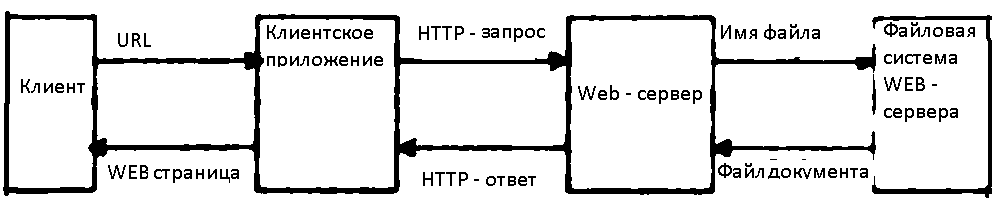

Рис. 15.1. Взаимодействие браузера и web-сервера

После того как пользователь обратился к определенному ресурсу по протоколу НТТР, клиент (обычно браузер) формирует НТТР-запроск web-серверу. Обычно указывается символьное имя сервера (например, http://www.edu.ru ), в этом случае браузер предварительно преобразует это имя в IP-адрес при помощи сервисов DNS. После этого по протоколу НТТР на web-сервер отправляется сформированное НТТР-сообщение. В этом сообщении браузер указывает ресурс, который необходимо загрузить, а также всю дополнительную информацию. Залача web-сервера - прослушивать определенный ТСР-порт (обычно порт 80) и принимать все входящие НТТР-сообшения. Если входящие данные не соответствуют формату сообщения НТТР, то такой запрос игнорируется, а клиенту возвращается сообщение об ошибке.

Стр. 257

В простейшем случае при поступлении НТТР-запроса web-сервер должен считать содержимое запрашиваемого файла с жесткого диска упаковать его содержимое в НТТР-ответ и отправить клиенту. В случас если требуемый файл не найден на жестком диске, то web-сервер сгенерирует ошибку с указанием статусного кода 404 и отправит это сообщение клиенту. Это технология работы web-сервера со статическими сайтами. **Статический сайт** - совокупность статичных HTML-страниц, связанных между собой. Статический сайт содержит в себе текст, изображения, мультимедиа содержимое (аудио, видео) и т.п. В этом случае на стороне сервера не запускается никакой программный код, кроме программного кода самого web-сервера. **Динамический сайт** — сайт, состоящий из динамических страниц — шаблонов, контента, скриптов в виде отдельных файлов. Страница сайта, которая отображается в браузере, динамически формируется по запросу пользователя на стороне сервера из страницы-шаблона и отдельно хранимого содержимого (текстовой информации, скриптов, баз данных и др.). Для отображения однотипных страниц, как правило, используется одна страница-шаблон, в которую загружается соответствующее содержимое. Поэтому, редактируя только один шаблон, можно изменить внешний вид всего сайта - множество всех его страниц. **Редактирование собственно содержимого** (как и страницы-шаблона) может производиться средствами различного программного обеспечения. Возможность внесения изменений предоставляется только определенной категории пользователей (например, администраторам или же зарегистрированным пользователям). В некоторых случаях к правке определенного web-контента допускаются анонимные пользователи, что бывает реже (например, на форумах - добавление сообщений). **В динамических web-приложениях** сервер преобразует файл после прочтения его файловой системой и перед отправкой его в web-браузер пользователя. Программное обеспечение, которое сервер web-приложений использует в процессе преобразования файлов, называется интерпретатором. Интерпретатор считывает файлы, обрабатывает их в соответствии с инструкциями, находящимися внутри файлов, а затем отправляет результат web-браузеру пользователя в виде HTML страницы. Разумеется, некоторые ресурсы (такие как файлы CSS, изображения и т.д.) могут храниться как статическое содержимое, но основные страницы HTML генерируются в процессе обработки. В этом случае web-сервер при обработке запроса НТТР должен обращаться к программному коду, который должен сгенерировать содержимое. С учетом этого, алгоритм работы web-сервера можно схематично представить следующим образом (рис. 15.2).

Стр. 258

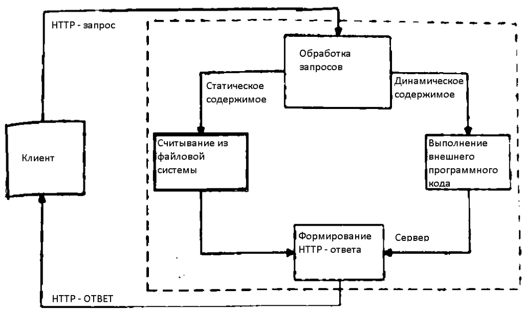

# Рис. 15.2. Алгоритм работы Web-сервера

Программный код, обрабатывающий НТТР-запросы и генерирующий НТТР-ответы, можно условно разделить на две части: **во первых**, программный код, реализующий служебные функции по взаимодействию через протокол НТТР (программный код самого web-сервера); **во вторых**, программный код, реализующий логику конкретного web-приложения (бизнес-логика, обращение к СУБД и т.д.). Поскольку программный код web-приложения обычно упаковывается в отдельные модули и поставляется независимо, то требуются механизмы взаимодействия этих двух частей - набор правил, по которым web-сервер и приложение будут взаимодействовать друг с другом. **При построении web-сервера** наиболее важными задачами являются обеспечение масштабируемости и защита от атак. Масштабируемость предполагает возможность увеличения количества обслуживаемых пользователей. Web-сервер работает в открытой среде, поэтому он может быть подвержен большим нагрузкам и потенциальным атакам. Наиболее распространенные атаки на web-сервер - это обращение к web-серверу с большим количеством запросов и их высокой частотой (так называемые DDoS-атаки). В этом случае web-сервер не может быстро обрабатывать все запросы, а это может сказаться на его производительности. Наиболее опасны атаки для web-серверов, на которых исполняется какой-либо внешний программный код (помимо программного кода самого web-сервера). Обычно для борьбы с подобными атаками блокируются все запросы, поступающие с определенного IР-адреса. Кроме того, следует позаботиться об оптимизации программного кода приложения, например использовать кэширование - в этом случае при обработке каждого запроса нагрузка на центральный процессор будет меньше.

Стр. 259

Существует вид услуг по предоставлению вычислительных мошностей для физического размещения информации на сервере, посто янно находящемся в сети. Такая услуга называется хостингом (hosting). Хостингом также называется услуга по предоставлению места для размещения оборудования клиента с обеспечением подключения его к каналам связи с высокой пропускной способностью (колокация, от англ. collocation). Однако чаще всего под услугой хостинга подразумевают размещение файлов сайта на сервере, на котором запущено программное обеспечение, необходимое для обработки запросов к этим файлам. Как правило, в услугу хостинга уже входит предоставление баз данных, DNS и т.п., а также поддержка функционирования соответствующих сервисов.

Виртуальный хостинг (shared hosting) - вид хостинга, при котором множество web-сайтов расположено на одном web-сервере. Это экономичный вид хостинга, подходящий для небольших проектов. Обычно каждый web-сайт расположен на своем собственном разделе web-сервера, но они все вместе пользуются одним и тем же программным обеспечением. Браузер отправляет НТТР-запрос на IР-адрес web-сервера, который ассоциирован с доменным именем. Клиент указывает также дополнительный НТТР-заголовок «host», в котором определяется оригинальное имя web-сайта (рис. 15.3). Благодаря этой информации web-сервер может разграничить доступ к нескольким web-сайтам и при этом использовать один и тот же IР-адрес. Если бы для каждого доменного имени приходилось регистрировать отдельный IP-адрес, то адресное пространство протокола IР уже было бы исчерпано, и стоимость размещения web-сайта в глобальной сети Интернет была бы намного выше.

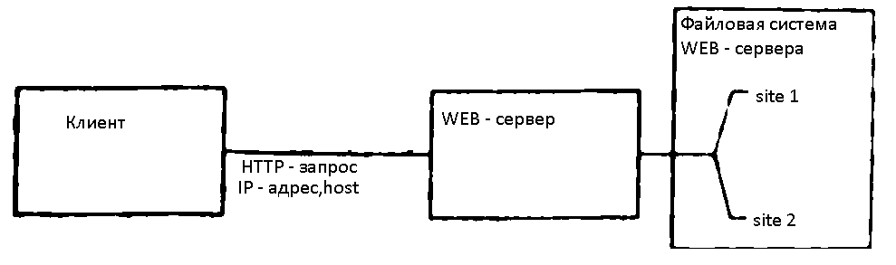

Рис. 15.3. Виртуальный хостинг

Виртуальный хостинг как услугу сравнивают и описывают по количественным ограничениям, таким как: **во первых**, размер дискового пространства; количество месячного трафика; **во вторых**, количество сайтов, которые можно разместить в рамках хостинга как одной услуги; **в третьих**, количество баз данных и количество места под базы данных; **в четвертых**, количество почтовых яшиков и FTP-аккаунтов;

Стр. 260

По качественным ограничениям виртуальный хостинг сравнивают по свободным ресурсам центрального процессора и оперативной памяти, которые влияют на быстродействие сервера. Одним из важных критериев выбора хостинга является используемая операционная система, так как от этого зависит программное обеспечение, которое будет поддерживать функциональность тех или иных сервисов. В работе виртуального хостинга обычно запрешается использование дополнительных служб и сервисов. Виртуальный хостинг имеет два основных преимущества: малую стоимость и легкость управления сайтами. По этим причинам виртуальный хостинг в основном используют частные лица. Если от сервера требуется большое количество ресурсов или в рамках этого сервера необходимо запускать дополнительные приложения или службы, то невозможно использовать виртуальный хостинг. В этом случае выбирается более дорогой вид размещения web-приложений в сети Интернет: арендуется выделенный сервер — физический или виртуальный.

# 15.2. Стандарт CGI

Web-сервер обеспечивает поддержку взаимодействия клиента и сервера по протоколу НТТР. Это взаимодействие осуществляется по определенным правилам. **CGI (Common Gateway Interface - интерфейс общего шлюза)** - набор правил (стандарт интерфейса), предназначенных для создания серверных приложений и определяющих порядок запуска программы на сервере, способы передачи программе параметров и доставки результатов ее выполнения клиенту. Программа, написанная по правилам CGI, называется CGI-сценарием. CGI-программы (шлюзы) запускаются сервером в режиме реального времени. Сервер передает запросы пользователя CGI-программе, которая их обрабатывает и возвращает результат своей работы клиенту. Таким образом, пользователь получает динамическую информацию, которая может изменяться в результате влияния различных событий и факторов. Программа **CGI представляет собой** обычное консольное приложение, работающее в среде операционной системы web-сервера и осуществляющее обмен данными. CGI загружается в адресное пространство сервера и запускается только по явному запросу пользователя, когда к нему выполняется обращение из HTML-документа. Завершив обработку запроса пользователя, программа CGI выгружается из памяти сервера. Программа CGI работает на сервере как отдельный процесс. В рамках этого процесса она способна, в частности, обращаться к базам данных для выборки или обновления информации. При поступлении очередного НТТР-запроса web-сервер инициирует создание нового процесса и передает ему все необходимые данные НТТР-запроса. После того как этот процесс отработает, он завершается, передав при этом результат обратно web-серверу. С точки зрения операционной системы web-сервер и приложение являются разными процессами, поэтому для обмена информацией между ними используются средства межпроцессного взаимодействия.

Стр. 261

С одной стороны, изолированность друг от друга процессов web-сервера и приложения является преимуществом CGI. В случае ошибок в web-приложении процесс самого web-сервера будет продолжать функционировать, а процесс приложения завершится с ошибкой. С другой стороны, необходимость создания каждый раз нового процесса влечет за собой дополнительные затраты ресурсов на создание процесса и передачу данных через границы процессов. Когда к серверу одновременно обращаются несколько десятков клиентов, в памяти для каждого создается отдельный процесс, для размещения кода каждого процесса нужна память. Этот факт является серьезным недостатком и оказывает существенное влияние на масштабируемость web-приложения, т.е. возможность обрабатывать большее количество поступающих запросов. **Web-сервер получает запрос от клиента**, анализирует содержимое запроса и возвращает соответствующий ответ. Если запрос содержит указание на файл, находящийся на жестком диске, то сервер возврашает в составе ответа этот файл. Если запрос содержит указание на программу и необходимые для нее аргументы, то сервер исполняет программу и результат ее работы возвращает клиенту.

Стр. 262

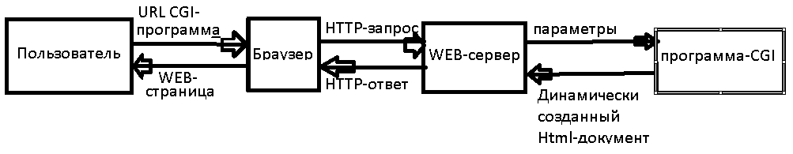

Рис. 15.4. Формирование динамических документов HTML с помощью CGI

Можно описать работу CGI как последовательность следующих операций (рис. 15.4): **Во первых**, web-сервер получает информацию от клиента. Для передачи данных web-серверу используются формы. Форма задается в HTML-документе при помощи тегов `<form> ... </form>` и состоит из набора полей ввода, отображаемых браузером в виде графических элементов управления: полей ввода, управляющих кнопок и т.д. Когда пользователь заполнит всю форму, данные из полей формы передаются программе CGI; **Во вторых**, данные, извлеченные из HTML-формы, передаются для обработки CGI-программе. Они не всегда могут быть обработаны CGI-программой самостоятельно. Например, они могут содержать запрос к базе данных. В этом случае CGI-программа на основании полученной информации формирует запрос к ядру СУБД, выполняющейся на том же или удаленном компьютере; **В третьих**, после обработки полученной информации CGI-программа создает динамический HTML-документ или формирует ссылку на уже существующий документ и передает результат клиенту. Таким образом, пользователю в ответ на запрос посылается HTML код, который был специально сгенерирован для него.

Стр. 263

CGI-скрипты могут быть написаны на интерпретируемом языке (Perl, PHP). На вход web-сервер принимает данные, введенные пользователем. После обработки полученных данных, пользователю возвращается результирующая страница. CGI-программа имеет свою специфику, заключающуюся в том, что она, как правило, генерирует HTML-документ, посылаемый клиенту в виде ответа сервера, состоящего из таких частей, как: **Во первых**, строка состояния, содержащая номер версии протокола НТТР, код состояния и краткое описание состояния, например:

```
НТТР/1.0 200 ОК # Запрос клиента обработан успешно
HTTP/1.0 404 Not Found # Документ по указанному
адресу не существует;
```

**Во вторых**, заголовки ответа, содержащие информацию о сервере и о возвращаемом HTML-документе, например:

```
Server: Apache/1.3.6 # Имя и номер версии сервера;
```

**В третьих**, содержимое ответа — HTML-документ, являющийся результатом выполнения CGI-программы.

При установке web-сервера один из каталогов специально выделяется для хранения сценариев. Обычно такой каталог получает имя `cgi-bin` (или `Scripts` для веб-сервера IIS). В этом случае, если клиент запрашивает файл из каталога `cgi-bin`, сервер воспринимает такой запрос как команду на запуск сценария. Файлы из других каталогов интерпретируются как HTML-документы.

Стр. 264

# 15.3. Язык Perl

**Интерпретаторы языка Perl** созданы практически для всех операционных систем. Этот язык высокого уровня содержит многие функции, упрощающие создание программ CGI. В сети Internet имеются в бесплатном доступе версии интерпретатора Perl для различных платформ, разнообразная документация и примеры программ. **Программа на языке Peri представляет собой** последовательность операторов, которые интерпретатор языка выполняет при каждом запуске. В отличие от типизированных языков Perl не требует объявления типов своих объектов. Все объекты, определенные в программе, до присваивания им какого-либо значения по умолчанию принимают значение «0». Комментарии выделяются знаком й, и вся строка, следующая за этим знаком будет рассматриваться как комментарий. Подпрограмму можно вызывать только ниже по тексту программы. Блоком называется последовательность операторов, логически составляющая единое целое в теле программы, как правило, блоки заключаются в фигурные скобки. Каждая команда отделяется от других точкой с запятой. Точка с запятой не обязательна, только если оператор является последним в блоке.

Perl - интерпретируемый язык, приспособленный для обработки произвольных текстовых файлов, извлечения из них необходимой информации и выдачи сообщений. Perl прост в использовании и эффективен, сочетает в себе лучшие черты языка Си, поэтому для тех, кто знаком с языком Си, изучение Perl не представляет особого труда из-за сходства синтаксиса. Регl позволяет использовать регулярные выражения, создавать объекты, вставлять в программу на Си или Си++ куски кода на Perl, а также осуществлять доступ к базам данных, в том числе Oracle. Чтобы запустить программу на языке Регі, на выполнение не требуется ее компиляция, она вполне может выполняться под управлением интерпретатора. Чтобы файл с исходным текстом Регі можно было запускать на выполнение, надо в его перваой строке записать:

```
#!путь_к_интерпретатору_Perl
```

Основными типами данных в языке Регі являются: скаляры; скалярные массивы; ассоциативные массивы (хеш-таблицы); функции; файловые дескрипторы; константы. Переменные разных типов отличаются символом, который стоит перед именем переменной:`$a` - скаляр или указатель; `@b` — скалярный массив; `%с` - ассоциативный массив (хеш-таблица); `&d` - функциия; `F` - дескриптор ввода-вывода или константа.

Стр. 265

**Скалярные переменные** используются для хранения одиночных значений и могут содержать числа, строки и ссылки на другие объекты. Тип скалярной переменной не фиксирован и определяется динамически в зависимости от контекста. **Скалярный массив** является упорядоченным списком скаляров. Каждый элемент массива имеет порядковый номер (индекс), с помощью которого к нему можно получить доступ. Нумерация элементов начинается с нуля. Для доступа к определенному элементу массива необходимо ставить знак $, так как определенный элемент массива является скаляром:

```
@winter = ("декабрь", "январь", "февраль") ;
print "Второй месяц зимы ", $winter[1], "\n";
```

Хеш-таблица представляет собой ассоциативный массив, позволяющий ассоциировать строку со скаляром. Строка при этом называется ключом, а скаляр в хеш-таблице - значением (в нечетных позициях находятся ключи, а на четных - значения). Перед именем переменной-списка необходимо ставить знак процента `%`, а для доступа к определенному элементу массива ставят знак `$`.

Использование ассоциативных массивов напоминает использование массивов скалярных значений, однако индексация производится не целыми числами, а ключевыми словами.

В последних версиях Perl появилась возможность хранить файловые дескрипторы в скалярах. Также таблицы символов используются для связи двух имен переменной с одним значением в памяти, создавая синонимы, которые могут быть использованы для доступа и модификации значения точно так же, как и оригинальное имя. Эта возможность является основой системы загружаемых модулей, классов и объектов в Perl.

Объект в Perl представляет собой просто ссылку, связанную с определенным классом (пакетом). Для связи используется функция `bless`. Подпрограммы такого связанного пакета являются методами и получают ссылку в качестве первого аргумента. **Важной частью Рег являются регулярные выражения**. Регулярные выражения в Perl - одна из самых мощных его возможностей. Они позволяют сопоставлять текст с указанным шаблоном, разбивать текст в массив по шаблону, производить замену текста по шаблону и многое другое. Благодаря этому Perl хорошо подходит для обработки текстов. Большая часть работы с регулярными выражениями производится при помощи операторов `=~`, `m//` и `s///`. Оператор `m//` используется для проверки на совпадение. В простейшем случае результат выражения `$х =~ m/abc/` будет истинным, если и только если строка `$х` будет соответствовать регулярному выражению abc. Поиск и замена выполняются при помощи оператора `s///`. Конструкция `$x =~ s/abc/def/` заменит первое вхождение регулярного выражения abc на строку `def`.

Стр. 266

Приведем небольшой пример. Определенная ниже процедура `hello` печатает `Hello, world!`, если вызвана без параметров, но будучи вызвана с параметром - именем пользователя, приветствует этого пользователя:

```
sub hello
{
    unless(@_)
    {

        print "Hello, world!\n";
    }
    else
    {
        print "Hello, $_[0]!\n";
    }
}
```

То же самое, используя оператор ?:, можно запрограммировать короче:

```
sub hello
{
    print ('Hello,'.(@_? $_[0]: 'world')."!\n");
}
```

С появлением динамических регулярных выражений `(??{ код Perl })` и конструкции для включения в регулярное выражение исполняемого кода `Perl (?{ код Perl })` возможности по поиску и замене стали практически безграничными. Например, стал возможен поиск конструкций произвольного уровня вложенности. Регулярные выражения Perl настолько популярны, что они включены напрямую в другие языки, такие как РНР и JavaScript, а также существуют подключаемые библиотеки, реализующие использование выражений в компилируемых языках. Операторы, заимствованные из Си, сохранили между собой ту же иерархию, что и в Си. Мощные конструкции этого языка позволяют создавать с минимальной затратой сил очень эффективные решения и универсальные инструменты. Эти инструменты можно использовать и в дальнейшем, потому что написанные на Perl программы отличаются высокой переносимостью и готовностью к использованию. Кроме того, Perl очень хорошо умеет обращаться с задачами низкого уровня.

# 15.4. Язык PHP

### 15.4.1. Основы синтаксиса РНР

Одним из языков программирования для создания динамических сайтов является язык РНР. Язык РНР — один из наиболее популярных языков сценария благодаря простоте и богатой функциональности. Его название представляет собой рекурсивную аббревиатуру словосочетания «PHP Hypertext Preprocessor», что переводится как «препроцессор гипертекста». Это простой и в то же время очень мощный язык для создания динамических web-страниц. РНР доступен для большинства операционных систем, таких как MS Windows, Mac OS, Linux, многих модификаций Unix и др. Также в РНР включена поддержка большинства современных web-серверов, таких как Apache, MS IIS, серверов Netscape и других. **При написании кода web-страниц** в HTML код с помощью специальных операторов подгружаются вставки кода РНР. Файлы со сценариями на языке РНР имеют расширение `.php` и представляют собой HTML-документы, в которые с помощью специальных тегов встраивается РНР-код. Если в HTML-странице изменить расширение с `.html` на `.php`, то она станет РНР-страницей, и выполнять ее уже можно только на сервере, поскольку весь вставленный РНР код предварительно обрабатывается на сервере, и затем готовая web-страница передается браузеру. Поэтому РНР называют серверным языком web-программирования. Операторы РНР-сценария выполняются именно на сервере, где размещен содержащий его HTML-документ. Пользователь, загрузивший Web-страницу, открыв программный код HTML-страницы в браузере, не увидит этих операторов. Пользователь обнаружит обычный HTML-код, сформированный на стороне сервера и являющийся результатом работы РНР-скрипта.

Стр. 267

**PHP состоит из** ядра и набора подключаемых расширений для работы с базами данных, сокетами, динамической графикой, криптографическими библиотеками, документами формата PDF и т.д. Возможна разработка своих собственных расширений с их последующим подключением. Интерпретатор РНР подключается к web-серверу либо через dll-модуль, созданный специально для этого сервера, либо в виде CGI-приложения. **Синтаксис языка РНР** достаточно прост для изучения и берет свое начало в языках Perl, Java и С. Однако в отличие от перечисленных языков РНР изначально разрабатывался как язык программирования для написания сценариев (web-приложений), исполняющихся на web-сервере. **Поскольку РНР** предоставляет возможность внедрять свои сценарии в HTML-код web-страниц, это значительно упрощает задачу создания динамических сайтов. Для работы программы на РНР не требуется описывать какие-либо переменные, используемые модули и т.п. Любая программа может начинаться непосредственно с оператора PHP:

```
<?php
    echo 'Hello, world!';
?>
```

Здесь использован оператор вывода `есhо`, после которого указано выводимое значение.

Стр. 268

Для включения РНР-сценария в текст HTML-документа можно использовать одну из конструкций тегов: `<?php ... ?>`; `<? ... ?>`; `<script language="php"> </script>`. Имена переменных начинаются с символа `$`, тип переменной объявлять не требуется. Имена переменных чувствительны к регистру. Переменные обрабатываются в строках, заключенных в двойные кавычки. Инструкции завершаются точкой с запятой. РНР полдерживает многострочные комментарии, ограниченные символами `/* ... */`, и в одну строку, начинающиеся с `//` и идушие до конца строки. **РНР не требуюет указания типа** при объявлении переменных, так же как и самого объявления переменных, т.е, является языком с динамической типизацией. Преобразование скалярных типов может осуществляться автоматически или явно. Напомним, что к скалярным типам данных относятся целый тип, вещественный тип данных, логический тип, строковый тип и специальный тип NULL. К нескалярным типам относятся «ресурс», массив и объект. Тип NULL предназначен для переменных без определенного значения. Ссылки на внешние ресурсы имеют тип `resource`. Переменные данного типа, как правило, представляют собой дескриптор, позволяющий управлять внешними объектами, такими как файлы, динамические изображения, результирующие таблицы базы данных и т.п. Массивы могут содержать значения любых типов, включая другие массивы. Суперглобальными массивами (`superglobal arrays`) в РНР называются предопределенные массивы, которые видны в любом месте исходного кода без использования ключевого слова global. Массив можно создать двумя способами:

**Во первых**, с помощью конструкции аггау:

```
$array name = array ("keyl"=>"valuel","key2"=> "value2");
```

**Во вторых**, непосредственно задавая значения элементам массива:

```
$array_name["key1"] =  value1;
```

РНР поддерживает объектно-ориентированные возможности. Класс в РНР объявляется с помощью ключевого слова `class`. Методы и поля класса могут быть общедоступными (`public`), защишенными (`protected`) и скрытыми (`private`). РНР поддерживает все три основные механизма ООП - инкапсуляцию, полиморфизм и наследование, а также интерфейсы (ставятся в соответствие с помощью `implements`). Множественное наследование классов не поддерживается, однако класс может реализовывать несколько интерфейсов. Для обращения к методам родительского класса используется ключевое слово `parent`. Экземпляры класса создаются с помощью ключевого слова `new`, обращение к полям и метолам объекта производится с использованием символов `->`. Для доступа к членам класса из его методов используется переменная `$this`. Подробное описание языка можно найти в справочном руководстве по РНР.

Стр. 269

# 15.4.2. Функции в РНР

Пользовательские функции, т.е. функции, определяемые разработчиком, в РНР характеризуются тем, что: возвращают любой тип данных; дают возможность изменять переданные функции параметры; можно вызвать одну и ту же функцию с переменным числом параметров. Определение (описание) функции в РНР имеет следующий синтаксис:

```
function имя_функции (параметр[=значение], параметр[=значение] ...)
{ тело функции }
```

Функцию можно объявить в любом месте программы, но обязательно до момента ее первого применения. Имена функций должны быть уникальными и не содержать пробелов. Регистр символов в данном случае не учитывается. Первым символом в имени функции не может быть `$`. Программный код (тело) функции заключают в фигурные скобки. Они определяют группу выражений, которые относятся к коду именно этой функции. Если требуется, чтобы функция возврашала некоторое значение, то в ее теле предусматривают оператор возврата `return` с указанием справа от него того, что следует возвратить. Возврашаемой величиной может быть любое выражение: простое значение, имя переменной или вычисляемое выражение. Оператор `return` может встречаться в коде функции несколько раз. Если оператор `return` не использовать или не указывать справа от него возвращаемую величину, то функция ничего не будет возвращать. Например, приведенная ниже функция вычисляет и возврашает произведение значений своих параметров:

```
function S_rec($w $h)
{
    $S=$w * $h;
    return $S;
}
```

Стр. 270

В РНР есть много встроенных функций. Некоторые из них доступны при обычной установке РНР, другие требуют особых, хотя

и несложных, настроек модуля РНР. Для доступа к некоторым функциям, например работы с базами данных, графической информацией и др., требуется подключение специальных библиотек.

В РНР имеется библиотека функций для работы с графическими изображениями. С помощью этих функций можно осуществлять различные преобразования изображений из графических файлов: масштабирование, повороты, наложение одного изображения на другое, вставку текста в изображение и др. Создание и обработка изображений на стороне сервера очень важны, например, при создании баннеров и счетчиков посещений web-страниц. Для работы с графикой необходимо подключить библиотеку графических функций. Для различных графических форматов (gif, png, jpeg и др.) в РНР существуют свои функции.

С точки зрения доступности переменные подразделяются на глобальные и локальные. Глобальные переменные доступны из любого места программы, в том числе из функции. Локальные переменные определены внутри функции и доступны только изнутри функции. По умолчанию все используемые внутри функции переменные являются локальными и их невозможно изменить вне тела функции. Даже если ее имя совпадает с именем глобальной переменной, объявленной в другом месте программы, вне функции, никакие изменения локальной переменной не повлияют на глобальную.

Кроме локальных и глобальных переменных, в программах РНР можно использовать статические переменные. Если переменную внутри функции объявить статической, ее значения не будут изменяться после вызова функции. Ниже приведен пример работы пользовательской функции со статистической переменной, реализующей счетчик:

```
<?php
    function f_count()
    {
        static $counter;
        $counter++;
        echo $counter;
    }
    for($i=0;$i++<9;)f_count();
?>
```

Программа в данном примере выведет строку: `123456789`. Если удалить объявление статической переменной, отобразится строка: `111111111`.

Стр. 271

При каждом новом вызове функции f_count() внутри функции будут инициализироваться переменные, вместе с тем переменным присваивается значение 0. Далее это значение инкрементируется и выводится оператором `echo`.

Некоторые программы на РНР можно использовать неоднократно и в различных проектах. В подобных случаях можно сохранять фрагменты кода (определения функций, классов и др.) в отдельных файлах, а в конкретный еценарий включать их с помощью встроенной функции `include (<параметр>)`. В качестве параметра указывается имя файла или URL-адрес файла, содержимое которого необходимо вставить в место вызова данной функции `include()`. Включаемый файл содержит РНР-код, который должен быть заключен в дескрипторы `<?php и ?>`.

# 15.4.3. Предопределенные переменные РНР

В PHP имеются предопределенные переменные типа аггау (массив) с глобальной областью видимости. Они доступны из любого сценария на языке РНР. Суперглобальные переменные введены в РНР как место хранения данных системного характера, определяющих работу всего сцеария на системном уровне. Перечислим основные массивы предопределенных переменных, которые формирует PHP при обработке пользовательского запроса:

- **во первых**, `$GLOBALS` - содержит все глобальные переменные. Имена глобальных переменных в массиве `$GLOBALS` являются его символьными ключами (индексами). Поэтому, чтобы получить доступ к глобальной переменной, например, `$my_var`, можно использовать выражение `$GLOBALS[«my_var»]`;
- **во вторых**, `$_GET` - содержит данные, переданные в сценарий на РНР в виде части URL-адреса, а также данные HTML-форм, переданные методом GET (GET-запрос);
- **в третьих**, `$_POST` - содержит данные, переданные в сценарий на РНР из HTML-форм методом POST (POST-запрос);
- **в четвертых**, `$_COOKIE` - содержит данные, переданные в текущий сценарий через механизм cookie;
- **в пятых**, `$_ENV` — содержит переменные окружения, содержимое этого массива зависит от операционной системы;
- **в шестых**, `$_FILES` — содержит имена файлов, загруженных методом POST с помощью браузера;
- **в седьмых**, `$_SERVER` - содержит переменные, установленные web-сервером либо непосредственно связанные с окружением выполнения текущего сценария. Эта информация зависит от того, какой web-cepвер используется;
- **в восьмых**, `$_SESSION` — содержит все переменные сеанса, доступные в текущем сценарии;
- **в девятых**, `$_REQUEST` - содержит все переменные, находящиеся в массивах `$_GET`, `$_POST` и `$_COOKIE`.

Для просмотра содержимого глобальных массивов можно воспользоваться функцией `var_dump()`, например `var_dump($_SERVER)`. Если, например, серверному сценарию из HTML-формы было передано методом POST содержимое элемента с атрибутом `name = «myname»`, то его можно получить в сценарии как `$_POST[' myname ']`.

Стр. 272

# 15.4.4. Обработка форм с помощью РНР-сценария

**Ранее уже упоминалось**, что методы `GET` и `POST` используются для передачи данных HTML-форм на сервер. Эти методы отличаются друг от друга способом передачи. Метод `GET` добавляет передаваемые данные к URL-адресу, и, следовательно, эти данные видны в адресной строке браузера. Это не всегда допустимо, поэтому более распространен метод `POST`. Кроме того, методом `POST` можно передавать большие по объему данные. РНР размещает данные, полученные от пользователя, в одном из массивов предопределенных переменных `$_GET` или `$_POST` в зависимости от используемого метода передачи данных. **Стандартным средством для отправки** на web-сервер данных, введенных пользователем с клавиатуры или сгенерированных клиентским/серверным сценарием, является HTML-форма, создаваемая контейнерным тегом `<FORM>`. В атрибуте `action` тега `<FORM>` указывается URL-адрес файла со сценарием, который должен принять эти данные и каким-либо образом их обработать. В контейнере `<FORM action=URL_адрес>` могут содержаться различные элементы пользовательского интерфейса (поля ввода данных, флажки, переключатели, кнопки) и должна быть, по крайней мере, одна специальная кнопка, создаваемая тегом `<INPUT type-submit>`, для отправки на сервер данных, содержащихся в элементах формы.

Получив данные от клиента, серверный сценарий может просто сохранить их в файле или базе данных, обработать каким-либо образом и, в зависимости от результата отправить клиенту некоторое сообщение, сгенерировать HTML-документ и т.д. Метод передачи данных (`GET` или `POST`) указывают в атрибуте method tera `<FORM>`, например, `<FORM action= "http://localhost/php_form_post.php" method=POST>` . **URL-адрес**, указанный в параметре `action` тега `<FORM>` показывает месторасположение РНР-сценария, который предназначен для обработки данных из этой формы. В данном случае используется локальная обработка данных на компьютере пользователя без выхода в сеть Интернет. Если в тегах элементов формы (`<INPUT>`, `<TEXTAREA>` И т. п.) указано значение атрибута name (имя элемента), то на сервер будут отправлены соответствующие пары вила: `имя_элемента = значение_элемента`.

Стр. 273

При этом `имя_элемента` (значение атрибута `name`) станет символьным индексом (ключом) массива `$_GET` или `$_POST` в зависимости от того, каким методом передавались данные. По индексу массива можно получить значение его элемента, т.е. значение соот ветствующего элемента формы. Например, чтобы получить содержимое элемента формы с именем `myelement`, достаточно обратиться к элементу массива `$_POST['myelement']` или `$_GET['myelement']` в зависимости от использованного метода передачи. Чтобы получить данные формы независимо от метода передачи, можно воспользоваться суперглобальным массивом `$_REQUEST`. Указав в качестве символьного индекса имя элемента формы, можно получить значение этого элемента. **Приведем пример файла**, который предоставляет браузеру клиента некоторую форму и отображает введенные пользователем данные. Таким образом, демонстрируется возможность доступа к полученным от клиента данным. Щелчок по кнопке (типа submit) отправляет на сервер данные, введенные пользователем:

```
<FORM action= "http://localhost/myforma.php" method=POST>
    <INPUT type="text" name="message" value="Hello, world!">
    <INPUT type="submit" name="submit" value="Отправить">
</FORM>
<?php
    /* Вывод содержимого массива $_ POST */
    foreach($_POST as $key=>$value) {
    echo "$key=$value <br>";
    }
?>
```

В результате будет отображаться список имен элементов формы и их значений:

[output not shown]

Если в атрибуте `method` тега `<FORM>` указать значение `GET`, то для получения данных необходимо воспользоваться суперглобальным массивом `$_GET` или `$_REQUEST`. При загрузке в браузер файла `myforma.php` в окне браузера отображаются элементы формы. Можно увидеть HTML-код этого файла, а PHP-код ничего не выводит, так как в массиве `$_POST` в данный момент ничего нет. После внесения в поле ввода каких-либо данных и щелчка на кнопке типа `submit` эта информация передается на сервер файлу `myforma.php`. Таким образом, браузер клиента вновь запрашивает файл `myforma.php`. Теперь массив `$_POST`, всегла доступный любому серверному РНР-сценарию, уже не пустой. Сервер возвращает браузеру клиента форму с пустыми полями, а затем то, что посылает оператор `echo` в РНР-сценарии, - индексы и значения массива `$_POST`.

Стр. 274

В рассмотренном примере форма создана непосредственно с помощью кода HTML. Это же можно сделать с помощью РНР-сценария, используя оператор `echo`. В этом сценарии с помощью оператора `echo` в окне браузера отображается форма в соответствии с заданной разметкой:

```
<?php
    echo '
        <FORM action="http://localhost/Форма.php" method=POST>
            <INPUT type="text" name="message" value="">
            <INPUT type="submit" name="submit" value="Отправить">
        </FORM>';
    foreach ($_POST as Skey=>$value)
    {
        echo "Skey=$value <br>";
    }
?>
```

В форме может содержаться набор элементов, допускающих множественный выбор (т.е. указание сразу нескольких значений). Типичный пример - набор флажков, каждый из которых задается тегом `<INPUT type=checkbox>`, а пользователь может установить произвольную их комбинацию. Принадлежность флажков одному и тому же набору обеспечивают одинаковые имена - значения атрибута `name`. В этом случае удобно задавать значение атрибута пате в виде массива, поскольку в РНР-сценарии легко организовать разбор того, что выбрал пользователь в наборе одноименных элементов.

Стр. 275

# 15.4.5. Взаимодействие РНР с базами данных

**PHP** имеет наборы специальных функций для работы с многими СУБД, такими как Microsoft SQL Server, MySQL, Oracle, PostgreeSQL, Informix, Sybase, IBM DB2. Кроме этого, РНР поддерживает стандарт ODBC (Open Database Connectivity - открытый интерфейс доступа к базам данных), которому соответствуют почти все реляционные СУБД. СУБД устанавливается независимо от РНР. Чтобы работать с ней посредством РНР-сценария, следует установить соответствуюшую данной СУБД библиотеку функций. Наиболее распространено использование СУБД MySQL. **MySQL** - реляционная система управления базами данных, свободно распространяемая, надежная и простая в использовании, достаточно быстрая. MySQL вполне подходит для небольших проектов. Существует довольно популярный визуальный интерфейс для работы с этой СУБД — PhpMyAdmin, который позволяет значительно упростить работу с базами данных в MySQL. В текстовом режиме работа с базой данных выглядит просто как ввод команд в командную строку. Многие из базовых SQL-функций работы с данными в PhpMyAdmin сведены к интуитивно понятным интерфейсам и действиям. **Взаимодействие сценария РНР с базой данных** обычно выполняется в следующей последовательности. После запуска сервера базы данных осуществляется подключение к нему. Далее следует передача SQL-запроса, который должен быть выполнен СУБД. SQL-запрос формулируется на языке SQL, оформляется в виде строки и передается специальной РНР-функции в качестве параметра. Если нет ошибок или каких-то других проблем, то СУБД выполнит SQL-запрос. Если SQL-запрос предполагает возврат данных, то они будут получены с помощью специальной РНР-функ-ции. С помощью специальных функций можно получить данные, соответствующие переданному ранее SQL-запросу, и далее их обработать, например, вывести на экран нужный текст. Можно обработать и отформатировать полученные данные, провести анализ, преобразование и т.п. Если не предполагается повторное обращение, то производится отключение от базы данных. Отключаться от базы данных рекомендуется всякий раз, как только прекращается работа с ней на длительный срок. **Подключение к базе данных**. Подключение к базе данных осуществляется с помощью специальных функций РНР, которым в качестве параметров передаются следующие данные: **местоположение (host)** - для многих серверов БД это доменноеимя или IP-адрес компьютера, на котором расположена БД: если она находится на том же компьютере, что и модуль РНР, то достаточно указать localhost. При необходимости можно указать через двоеточие порт, который прослушивается сервером базы данных; **регистрационное имя (username)** — строка символов, соответствующая имени пользователя, под которым он может получить доступ к БД; **пароль (password)** - строка символов, которая вместе с регистрационным именем служит для обеспечения доступа к БД; имя базы данных.

Стр. 276

После подключения к серверу баз данных и выбора требуемой базы данных можно выполнять с ней различные манипуляции, которые задаются выражениями на языке SQL. SQL-запрос к базе данных в качестве строкового параметра передается специальной функции РНР, которая, в свою очередь, передает его СУБД. СУБД выполняет этот запрос, а РНР-функция возвращает указатель на временную таблицу данных - результат выполнения запроса. С помощью оператора SELECT языка SQL. осуществляется выбор необходимых данных из одной или нескольких таблиц. Условие выбора данных формулируется в выражении SQL-запроса вслед за ключевым словом WHERE. Результатом выполнения такого запроса является временная таблица (возможно, пустая, если нет данных, удовлетворяющих условию запроса). Функция РНР, выполняющая запрос, возвращает указатель на полученную в результате временную таблицу. Иногда данные из временной таблицы записываются в массив, после чего его обрабатывают сценарии (например, выводят на экран, изменяют значения, производят вычисления и т.п.). Если требуется изменить значения полей таблицы, добавить новую или удалить имеющуюся запись, то формируют строку с соответствующим SQL-запросом, а затем передают ее в качестве параметра функции, выполняющей запрос.

В РНР при подключении к базам данных в разных СУБД используются разные функции:

**Во первых**, в системе управления базами данных MS SQL Server:

```
$connect = mssql_connect (имя_сервера_БД, username, password);
$db = mssql_select_db (имя_БД, $connect);
```

**Во вторых**, в системе управления базами данных MySQL: Оншо

```
$connect = mysql_connect(host, username, password);
$db = mysql_select_db($connect, имя_БД).
```

**Функция** `<...>_connect()` выполняет соединение с сервером БД и возвращает идентификатор соединения при успехе и `false` - при неудаче. При этом для MySQL в первом параметре этой функции указывают `host` (доменное имя или ІР-адрес компьютера), а для MS SQL Server — имя сервера БД, устанавливаемое при регистрации сервера. Идентификатор соединения, возвращаемый функцией, используется в сценарии, в частности, при выборе базы данных, создании запросов и т.д. **Функция** `<...>_select()` выбирает конкретную базу данных на сервере, на который указывает идентификатор `$connect`, возвращенный первой функцией. Эта функция возвращает `true` при успешном завершении операции и `false` - в противном случае. B MS SQL Server базу данных можно создать с помощью утилиты Enterprise Manager или с помощью соответствующих команд SQL. B MySQL можно ввести необходимые SQL-выражения в командной строке либо написать соответствующий РНР-сценарий, а затем выполнить его. Отключение от базы данных осуществляет функция, которой передается идентификатор соответствующего подключения. Например, `mysql_close($connect)` - для MySOL, `mssq_close($connect)` — для MS SOL Server.

Стр. 277

**Передача запросов к базе данных**. После того как произошло подключение к серверу баз данных и была выбрана требуемая БД, с ней можно выполнять различные манипуляции, используя команды SOL. Ранее упоминалось, что SQL-запрос передается СУБД специальной функцией РНР в качестве строкового параметра. СУБД выполняет этот запрос, а РНР-функция возвращает указатель на временную таблицу данных, являющуюся результатом выполнения запроса. Для различных СУБД функции передачи запроса похожи, но все же имеют некоторые отличия:

**Во первых**, для системы управления базами данных MS SQL Server:

```
mssql_query (SQL_запрос, идентификатор_ соединения) ;
```

**Во вторых**, для системы управления базами данных MySQL:

```
mysql_query (SQL_запрос, идентификатор_соединения);
```

По разным причинам подключение к серверу и выбор БД могу оказаться неудачными. При этом выполнение сценария продолжится, что может оказаться бессмысленным и вызвать поток сообщений об ошибках. Предотвратить это помогает функция `exit()`. выводящая указанное сообщение и прекращающая дальнейшее выполнение сценария. Функция `mysql_error()` возвращает описание возникшей ошибки. Подключение к базе данных для различных СУБД осуществляют в большинстве случаев похожие функции. Однако могут быть и существенные отличия, как, например, при подключении к серверу PostgreeSQL.

Стр. 278

**Обработка данных в сценарии.** Выбор нужных данных из одной или нескольких таблиц выполняет SQL-запрос, начинающийся с ключевого слова (оператора) `SELECT`. Критерий выбора данных формулируется в выражении SQL-запроса велед за ключевым словом WHERE. Результатом выполнения такого запроса является временная таблица, возможно, пустая, если нет данных, удовлетворяющих условию запроса. Функция РНР, выполняющая запрос, возвращает указатель на полученную в результате временную таблицу. Этот указатель используется в РНР-сценарии для доступа к данным с помошью специальных функций. Иногда данные из временной таблицы записываются в массив, а затем его обрабатывают. Если требуется изменить значения полей таблицы, добавить новую или удалить имеющуюся запись, то формируют строку с соответствующим SQL-запросом, а затем передают ее в качестве параметра функции, выполняющей запрос (например, `mssql_query()`). В качестве параметров этой функции надо передать SQL-запрос SELECT с соответствуюшими параметрами. РНР-оператор для выборки всей таблицы будет следующий:

```
$result-mysql_query("SELECT * FROM staff", $link).
```

При успешном выполнении запроса функция `mysql_query()` возвращает идентификатор результата запроса, и данный идентификатор можно передавать другим функциям для обработки результата. В этой переменной будет храниться вся таблица в виде матрицы. Для того чтобы извлекать из матрицы отдельные записи, используется функция `mysql_fetch_array()`. В качестве параметра этой функции надо передать имя `$result`. PHP-оператор для выборки первой записи из таблицы будет таким:

```
$myrow=mysql_fetch_array($result).
```

# 15.4.6. Взаимодействие РНР и XML

Язык РНР можно использовать для работы с XML-документами. В РНР для этого существуют два модуля, реализующие два разных стандарта обработки XML-данных: SAX (Simple API for XML) и DOM (Document Object Model). **Стандарт SAX** не является стандартом WЗC и описывает метод обработки XML-документов для получения из них данных. То есть этот метод обработки XML-документов позволит только прочитать данные из XML-документа, не более того. Создавать и изменять XML-документы с его помощью невозможно. **Другим стандартом для обработки XML-данных является DOM** - стандарт W3C, спецификация которого имеется на сайте консорциума. В отличие от SAX этот метод позволяет производить любые операции с XML-данными в достаточно удобной форме, представляя XML-документ как дерево объектов. Модуль, реализующий этот стандарт, называется DOM XML. Он не входит в основной набор модулей РНР, но может быть установлен как расширение API (программного пользовательского интерфейса) этого модуля. Модуль DOM XML является мощным и удобным в использовании средством обработки XML-документов. Модуль DOM XML определяет в РНР несколько классов, таких как DomNode, DomDocument, DomElement, Dom Text и DomAttribute, большинство из которых идут из ядра стандарта DOM. Почти для всех классов (в частности, для перечисленных выше) класс DomNode является родительским, поэтому его свойства и методы наследуются всеми остальными классами. В произвольном XML-документе классу Dom Document будет соответствовать сам этот документ, классу DomElement - каждый XML-тег, классу DomAttribute - атрибуты тегов, а классу DomText - содержание XML-элементов. В то же время классу DomNode будет соответствовать каждый из перечисленных элементов XML-документа.

Стр. 279

# 15.4.7. Сеансы в РНР

**Сеанс (сессия) в РНР** - механизм, который позволяет обеспечить доступность данных, созданных на различных серверных страницах в рамках одного сайта, для других страниц того же сайта. **Технология сеансов** перекрывает возможности и преодолевает ограничення `соокіс` по обмену данными между web-страницами. Сеанс создается и закрывается, когда это необходимо. В интервале времени между этими событиями все РНР-сценарии, расположенные в различных файлах и подключенные к данному сеансу, имеют доступ к переменным, созданным в других сценариях этого же сайта. Чтобы воспользоваться возможностями, предоставляемыми механизмом сеанса, его необходимо создать или подключиться к нему. В пределах существующего сеанса можно установить сеансовые переменные. Для этого служит суперглобальный массив `$_SESSION`. **Каждое web-приложение**, как правило, состоит из нескольких страниц, содержащих сценарии. При загрузке каждой страницы переменные в этих сценариях очищаются, и для обмена данными между страницами можно использовать механизм передачи параметров, базу данных либо запись информации в cookie-файлах. Однако наиболее удобным методом является использование сеансов. **При открытии сеанса** для каждого пользователя на сервере формируется определенная среда, заданная совокупностью параметров. относящихся к данному пользователю. Например, там могут сохраняться какие-то настройки интерфейса, конфигурации отдельных сервисов и т.п. Соответствующие данные хранятся в суперглобальном массиве `$_SESSION`. **Каждому сеансу присваивается** уникальный идентификатор, который может использоваться при повторном открытии сеанса. Этот идентификатор можно сохранить, например, в сооіе-файле, после чего при повторном посещении сайта уже не потребуется заново настраивать работу с его интерфейсом и сервисами. Для открытия сеанса используется функция `session_start()`, не имеющая пара-метров. После этого становится доступным массив `$_SESSION`, и в нем можно сохранять свои данные, которые будут доступны из любой части web-приложения до завершения сеанса.

Стр. 280

# 15.5. Приложения ISAPI

В общем шлюзовом интерфейсе CGI имеется ряд недостатков, среди которых наиболее существенными являются высокие требования к аппаратным ресурсам web-сервера и высокие накладные расходы на этанах загрузки и выгрузки CGI-приложений. Альтерна-

тивным решением считается использование модульной архитектуры web-серверов, позволяющей расширять их возможности за счет внешних библиотек - модулей.

**Модули web-сервера** представляют собой статически или динамически подключаемые библиотеки функций, доступных web-cepверу. В отличие от CGI модульные расширения работают быстрее и требуют меньших ресурсов. **Модульное расширение ISAPI** (Internet Server Application Program Interface) - набор интерфейсов, предоставляемых web-сервером для написания приложений, взаимодействующих с сервером Microsoft IIS (Internet Information Services) и расширяющих его возможности. **Приложения ISAPI** загружаются и выполняются в адресном пространстве IIS, поэтому серверу не нужно создавать новый процесс при каждом НТТР-запросе. Поскольку Windows загружает динамически подключаемую библиотеку один раз при первом вызове функции в DLL, то приложение ISAPI остается загруженным и не удаляется, пока не будет остановлен или выключен web-сервер, либо при ложение не будет выгружено явным образом. **Приложения ISAPI** могут быть оформлены или в виде расширений, или в виде фильтров.

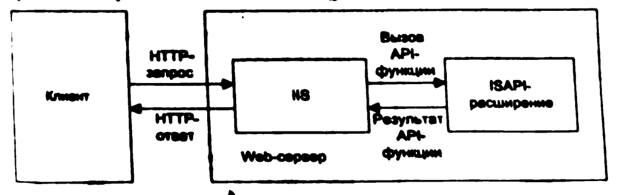

Рис. 15.5. Функционирование ISAPI-расширений

**ISAPI-расширение** — это приложение IIS, которое является адресатом запроса, оно выполняет действия, которые web-сервер не может выполнять сам (например, обращение к базе данных). Расширение не влияет на параметры запроса, а использует их как входные данные. В этом ISAPI-расширение напоминает CGI-приложение. Расширения ISAPI выполняют те же функции, что и программы CGI. Обычно ISAPI применяются для обработки клиентских НТТР-запросов и возвращения НТТР-ответа (рис. 15.5). **При обращении удаленного пользователя** к расширению CGl на web-сервере запускается программа, которая выполняется как отдельный процесс в собственном адресном пространстве. На запуск процесса требуется время, поэтому при обрашении к web-cepepy большого количества пользователей программы CGI могут его максимально загрузить. В результате время реакции web-сервера увеличивается, что создает трудности пользователям. **В отличие от CGI в ISAPI** при поступлении очередного запроса Web-сервер инициирует создание нового потока в рамках основного процесса, в котором работает web-сервер. В памяти всегда находится только одна копия соответствующей библиотеки DLL, поэтому при одновременном обращении к расширению ISAPI нескольких пользователей системные ресурсы расходуются более экономно и, кроме того, не тратится время на дополнительные загрузки расширения.

Стр. 281

**ISAPI-расширения** явно указываются в URL-адресе, отправляемом на **IIS-сервер/** . Например: http://localhost/myapi/myapi.dll . **ISAPI-расширение** можно вызывать с параметрами, которые позволят одному компоненту выполнять разные задачи. **Последние версии сервера IIS позволяют** загружать программы ISAPI в отдельное адресное пространство. Такой способ замедляет работу сервера, но может использоваться для отладки новых программ. Аварийное завершение программы ISAPI, загруженной в отдельное адресное пространство, не приводит к полной остановке web-сервера. **ISAPI-расширения** часто создаются с использованием ISAPI-классов библиотеки MFC (Microsoft Foundation Class Library). Это значительно упрощает разработку ISAPI-расширений. **Фильтры ISAPI**, так же как и расширения ISAPI, реализованы в виде библиотек динамической загрузки DLL и способны контролировать весь поток данных между браузером и web-сервером на уровне протокола НТТР (рис. 15.6). Фильтр непосредственно участвует в обработке пользовательского запроса с момента его получения сервером и до момента отправки ответа. Он может модифицировать запрос или ответ, изменить адрес, но он сам не является конечным получателем запроса.

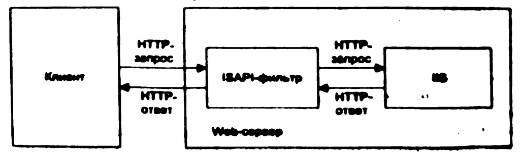

Рис. 15.6. Функционирование ISAPI -фильтров

**ISAPI-фильтры** никогда не вызываются явно - IIS обращается к ним в ответ на определенные события в процессе выполнения запроса. Такими событиями являются: **во первых**, завершение обработки сервером предоставленных клиентом заголовков; **во вторых**, завершение сервером процедуры аутентификации клиента; **в третьих**, сопоставление сервером физического и логического URL-адреса; **в четвертых**, начало передачи данных от клиента на сервер; **в пятых**, завершение передачи данных от клиента, но до начала их обработки на сервере; **в шестых**, регистрация информации сервером в журнале; **в седьмых**, завершение сеанса. **ISAPI-фильтры** можно применять для создания дополнительных процедур аутентификации пользователей, сбора статистической информации об использовании ресурсов сервера, динамической перекодировки и шифрования данных и т.д. Основное преимущество ISAPI состоит в скорости выполнения операций. ISAPI-приложение работает быстрее, чем обычная CGI-программа, которая должна всякий раз загружаться и выгружаться. Приложения ISAPI являются более масштабируемыми, поскольку с точки зрения операционной системы создание потока - это менее затратная операция, чем создание процесса. Кроме того, упрощается взаимодействие web-сервера и web-приложения, так как в этом случае используется единое адресное пространство в рамках операционной системы, поскольку весь код работает в одном и том же процессе. Среди недостатков можно назвать трудности программирования и отладки ISAPI-приложений. Так как приложение ISAPI работает в адресном пространстве web-сервера, незамеченная ошибка в приложении ISAPI может вызвать аварийное завершение работы не только самой библиотеки DLL, но и web-сервера, а при использовании программ CGI это маловероятно.

Стр. 282 - 283

# 15.6. Технология ASP

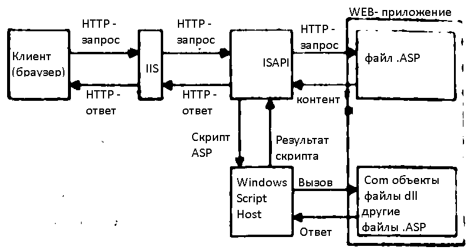

Рис. 15.7. Обработка запроса на ASP-страницу

**ASP** поддерживает технологию работы со сценариями Windows Script Components, она позволяет поместить все сценарные процедуры, выполняющие бизнес-логику, в СОМ-компоненты. ОМ (Component Object Model - объектная модель компонентов) - технологический стандарт, предназначенный для создания программного обеспечения на основе взаимодействующих компонентов. Эти компоненты допускают повторное использование и могут работать как в web-приложениях, так и в других программах, построенных по технологии СОМ. Если возникнет необходимость реализовать собственную бизнес-логику, имеется возможность создания новых объектов СОМ или использования объектов СОМ сторонних разработчиков. Серверный сценарий, встроенный в страницу ASP, способен обращаться к базам данных через вызов методов интерфейса ActiveX Data Objeets (ADO). **В ASP нет ориентации на** определенный язык программирования, поэтому знание любого языка сценариев достаточно для того, чтобы работать с ASP. Логика работы страницы скрыта от пользователей. Пользователь не может увидеть содержимое страницы ASP, так как Web-сервер отправляет ему не саму страницу, а результат ее интерпретации. К недостаткам ASP можно отнести: **во первых**, отсутствие гибкой, мощной и масштабируемой среды программирования; **во вторых**, снижение производительности из-за смены контекста (необходимости размещать команды сценария в HTML). Технология ASP получила свое развитие в виде `ASP.NET` - технологии создания web-приложений, основанной уже на платформе Microsoft `.NET`.

Стр. 284